# Fitting the ST model for the LUR

Sheena Martenies

07/15/2020

# 1 Introduction

This version of the model builds on the analysis presented in `16b_LUR_BC_ST_NB`. There are some key changes to the model, described below.

Josh and I discussed some potenital strategies to improve model fit for the 2009-2010 period. These initial steps include:

- adding PM2.5 back in with the NO2 and BC data
- only including the four PM2.5 monitors with long-term trends (080050005, 080130003, 080130012, 080310002)
- testing out one vs. two basis functions
- dropping NO2 monitor 080590006 from the analysis since it was installed so recently
- making sure to include NO2 at the BC monitoring site as well (make sure the names are distinct!)

**Main take aways**:

- It looks like these three models are performing comparably to the previous version that did not include PM2.5 in the trend data
- However, the 2-basis function model (Model B) still has some residual autocorrelation in at the central site
- This autocorrelation goes away when we use 3 trend functions, but then the predictions for the 2009-2019 period are different from what we expect

# 2 Fit time trends

Because of the issue with predicting BC for 2009-2010, we need to make some changes to how the time trends are estimated. Here I’m going to add PM2.5 from four monitors with long term trends. I’m also going to drop one NO2 monitor that isn’t contributing much and I’m going to make sure that the BC and NO2 data at the near-road site are both included.

## 2.1 Denver data set

Here I’m reading in the filter data sets and getting them into the right shape for the `SpatioTemporal` package. Here the ST covariates cover the entire study period (2009 - 2019).

```r
data_name <- "Combined_Filter_Data_AEA.csv"
lur_data <- read_csv(here::here("Data", data_name)) %>%
  filter(!is.na(lon)) %>%
  filter(indoor == 0) %>%
  #' QA filters
  filter(bc_ug_m3_dem > 0) %>%
  filter(is.na(below_lod) | below_lod == 0) %>%
  filter(is.na(low_volume_flag) | low_volume_flag == 0) %>%
  filter(is.na(flow_rate_flag) | flow_rate_flag == 0) %>%
  filter(is.na(is_blank) | is_blank == 0) %>%
  filter(is.na(negative_pm_mass) | negative_pm_mass == 0) %>%
  filter(is.na(potential_contamination) | potential_contamination == 0) %>%
  filter(is.na(bc_mass_ug_corrected) | bc_mass_ug_corrected >= 1.41) %>%
  #' Just campaigns 1-3 and the monitoring site
  filter(campaign %in% paste0("Campaign", c(1, 2, 3, "X")))
lur_data <- lur_data %>%
  rename("bc_ug_m3_raw" = "bc_ug_m3") %>%
  rename("bc_ug_m3" = "bc_ug_m3_dem")

camp_data <- filter(lur_data, campaign %in% paste0("Campaign", c(1, 2, 3)))
camp_data_lod <- filter(camp_data,
                        is.na(bc_mass_ug_corrected) | bc_mass_ug_corrected >= 1.49)

#' Format the date variable to be Year-WeekNo. (starts on Sunday)
#' Convert that back to the first day of the week
lur_data <- lur_data %>%
  mutate(sample_week_no = format(StartDateLocal, "%Y-%W")) %>%
  mutate(sample_week = as.Date(cut(as.Date(StartDateLocal), "week")))

#' Add a unique site ID
ids <- read_csv(here::here("Data", "ST_Model_Site_IDs.csv"))
lur_data <- mutate(lur_data, site_id_lonlat = paste(lon, lat, sep = "_"))
lur_data <- left_join(lur_data, ids, by = "site_id_lonlat")

lur_data$site_id <- ifelse(lur_data$filter_id == "080310027", "central", lur_data$site_id)

#' Create an ID object for the central site
cent_id <- filter(lur_data, filter_id == "080310027") %>%
  dplyr::select(site_id_lonlat) %>%
  distinct()

#' Drop old ST covariates
#' Keep linking variables (sample_week and site_id_lonlat)
lur_data <- dplyr::select(lur_data, -c(StartDateLocal:units_smoke))

#' Get the new ST covariates
st_covariates_file_name <- "ST_Covariates_Filters_09_19_AEA.csv"
st_covariates <- read_csv(here::here("Data", st_covariates_file_name)) %>%
  rename("sample_week" = "week") %>%
  left_join(ids, by = "site_id_lonlat") %>%
  filter(site_id_lonlat %in% lur_data$site_id_lonlat)
#' Duplicate st covariates for the central site monitor
cent_st_covariates <- filter(st_covariates, site_id_lonlat == cent_id$site_id_lonlat) %>%
  mutate(site_id = "central")

st_covariates <- bind_rows(st_covariates, cent_st_covariates)

st_cov_dates <- dplyr::select(st_covariates, site_id, sample_week) %>%
  distinct()

#' Log-transformed BC observations with NA values for the missing dates
bc_obs <- lur_data %>%
  dplyr::select(site_id, sample_week, bc_ug_m3) %>%
  mutate(log_bc = log(bc_ug_m3)) %>%
  dplyr::select(-bc_ug_m3)

#' Fill in the ST dates with NAs
bc_obs2 <- left_join(st_cov_dates, bc_obs, by = c("sample_week", "site_id"))

#' Pivot to a wide data frame
bc_obs2 <- bc_obs2 %>%
  pivot_wider(id_cols = sample_week,
              names_from = site_id, values_from = log_bc) %>%
              # names_from = site_id, values_from = bc_ug_m3) %>%
  as.data.frame() %>%
  arrange(sample_week)
rownames(bc_obs2) <- bc_obs2$sample_week
bc_obs2$sample_week <- NULL
bc_obs2 <- as.matrix(bc_obs2)

bc_weeks <- rownames(bc_obs2)

#' Spatial covariates (scaled)
load(here::here("Results", "BC_LASSO_Model_3C.Rdata"))

lasso_coef_df <- data.frame(name = log_bc_lasso_coef3@Dimnames[[1]][log_bc_lasso_coef3@i + 1],
                            coefficient = log_bc_lasso_coef3@x)
covars <- as.character(lasso_coef_df$name[-c(1:2)])
covars
```

```
##  [1] "impervious_2500"     "open_2500"           "low_int_100"
##  [4] "med_int_50"          "high_int_50"         "high_int_100"
##  [7] "ag_250"              "pop_den_50"          "dist_m_compost"
## [10] "dist_m_military"     "len_m_highways_2500" "aadt_100"
## [13] "aadt_2500"
```

```r
covar_fun <- paste("~", paste(covars, collapse = " + "))
covar_fun
```

```
## [1] "~ impervious_2500 + open_2500 + low_int_100 + med_int_50 + high_int_50 + high_int_100 + ag_250 + pop_den_50 + dist_m_compost + dist_m_military + len_m_highways_2500 + aadt_100 + aadt_2500"
```

```r
bc_sp_cov <- dplyr::select(lur_data, site_id, lon, lat, all_of(covars)) %>%
  distinct() %>%
  mutate_at(.vars = vars(covars),
            scale)
```

```
## Note: Using an external vector in selections is ambiguous.
## i Use `all_of(covars)` instead of `covars` to silence this message.
## i See <https://tidyselect.r-lib.org/reference/faq-external-vector.html>.
```

```r
bc_sp_cov <- bc_sp_cov %>%
  rename(ID = site_id) %>%
  mutate(lon2 = lon, lat2 = lat) %>%
  st_as_sf(coords = c("lon2", "lat2"), crs = ll_wgs84) %>%
  st_transform(crs = albers)
sp_coords <- do.call(rbind, st_geometry(bc_sp_cov)) %>% as_tibble()
names(sp_coords) <- c("x", "y")

bc_sp_cov <- bind_cols(bc_sp_cov, sp_coords) %>%
  st_set_geometry(NULL) %>%
  as.data.frame()

bc_sp_cov$type <- ifelse(bc_sp_cov$ID == "central", "central", "dist")
bc_sp_cov$type <- as.factor(bc_sp_cov$type)

cor(bc_sp_cov[,covars])
```

```
##                     impervious_2500   open_2500 low_int_100  med_int_50
## impervious_2500          1.00000000 -0.83510376  0.04147581 -0.16679293
## open_2500               -0.83510376  1.00000000 -0.12603064 -0.05636061
## low_int_100              0.04147581 -0.12603064  1.00000000 -0.12631919
## med_int_50              -0.16679293 -0.05636061 -0.12631919  1.00000000
## high_int_50              0.47483018 -0.41635316 -0.40185252  0.11602031
## high_int_100             0.52311084 -0.42248110 -0.42323883  0.11793239
## ag_250                  -0.27936743  0.21175032 -0.08010687 -0.01607492
## pop_den_50               0.38882480 -0.43039859  0.47294767  0.03873098
## dist_m_compost          -0.23740048  0.36015952 -0.11994547  0.24386038
## dist_m_military         -0.03254975  0.04081092  0.04177673 -0.27904653
## len_m_highways_2500      0.64494301 -0.49689181 -0.03038655 -0.07783019
## aadt_100                 0.42486549 -0.34876292 -0.28464438  0.03359576
## aadt_2500                0.46380170 -0.30096796 -0.07081120 -0.13990581
##                     high_int_50 high_int_100      ag_250  pop_den_50
## impervious_2500      0.47483018  0.523110836 -0.27936743  0.38882480
## open_2500           -0.41635316 -0.422481096  0.21175032 -0.43039859
## low_int_100         -0.40185252 -0.423238827 -0.08010687  0.47294767
## med_int_50           0.11602031  0.117932388 -0.01607492  0.03873098
## high_int_50          1.00000000  0.897420410 -0.06773259 -0.03835657
## high_int_100         0.89742041  1.000000000 -0.11729969 -0.05518337
## ag_250              -0.06773259 -0.117299694  1.00000000 -0.25195719
## pop_den_50          -0.03835657 -0.055183373 -0.25195719  1.00000000
## dist_m_compost      -0.10560558 -0.103918047  0.17279043 -0.12463877
## dist_m_military      0.02312569  0.005546725 -0.07173031 -0.06287839
## len_m_highways_2500  0.27706123  0.341931815 -0.24170133  0.03982997
## aadt_100             0.62883088  0.784232910 -0.10573403 -0.09971011
## aadt_2500            0.18533105  0.271784649 -0.11425336 -0.06750291
##                     dist_m_compost dist_m_military len_m_highways_2500
## impervious_2500        -0.23740048    -0.032549751         0.644943011
## open_2500               0.36015952     0.040810919        -0.496891814
## low_int_100            -0.11994547     0.041776735        -0.030386550
## med_int_50              0.24386038    -0.279046527        -0.077830187
## high_int_50            -0.10560558     0.023125694         0.277061226
## high_int_100           -0.10391805     0.005546725         0.341931815
## ag_250                  0.17279043    -0.071730306        -0.241701329
## pop_den_50             -0.12463877    -0.062878388         0.039829971
## dist_m_compost          1.00000000    -0.738189101        -0.086198948
## dist_m_military        -0.73818910     1.000000000        -0.008127746
## len_m_highways_2500    -0.08619895    -0.008127746         1.000000000
## aadt_100               -0.13357005     0.131174981         0.433081107
## aadt_2500               0.03881186    -0.225380937         0.475034135
##                        aadt_100   aadt_2500
## impervious_2500      0.42486549  0.46380170
## open_2500           -0.34876292 -0.30096796
## low_int_100         -0.28464438 -0.07081120
## med_int_50           0.03359576 -0.13990581
## high_int_50          0.62883088  0.18533105
## high_int_100         0.78423291  0.27178465
## ag_250              -0.10573403 -0.11425336
## pop_den_50          -0.09971011 -0.06750291
## dist_m_compost      -0.13357005  0.03881186
## dist_m_military      0.13117498 -0.22538094
## len_m_highways_2500  0.43308111  0.47503413
## aadt_100             1.00000000  0.21952160
## aadt_2500            0.21952160  1.00000000
```

```r
#' NO2 and smoke spatiotemporal predictors
#' NO2 at each site estimated using IDW
bc_st_no2 <- dplyr::select(st_covariates, site_id, sample_week, idw_no2) %>%
  pivot_wider(id_cols = sample_week,
              names_from = site_id, values_from = idw_no2) %>%
  as.data.frame()
rownames(bc_st_no2) <- bc_st_no2$sample_week
bc_st_no2$sample_week <- NULL
bc_st_no2 <- as.matrix(bc_st_no2)

no2_weeks <- rownames(bc_st_no2)
setdiff(bc_weeks, no2_weeks)
```

```
## character(0)
```

```r
#' Smoke day indicator variable based on WFS paper method (see Brey and Fischer, 2016)
bc_st_smk <- dplyr::select(st_covariates, site_id, sample_week, area_smoke_2sd) %>%
  pivot_wider(id_cols = sample_week,
              names_from = site_id, values_from = area_smoke_2sd) %>%
  as.data.frame()
rownames(bc_st_smk) <- bc_st_smk$sample_week
bc_st_smk$sample_week <- NULL
bc_st_smk <- as.matrix(bc_st_smk)

smk_weeks <- rownames(bc_st_smk)

setdiff(bc_weeks, smk_weeks)
```

```
## character(0)
```

Create a new `denver.data` object.

```r
denver.data <- createSTdata(obs = bc_obs2,
                            covars = bc_sp_cov,
                            SpatioTemporal = list(bc_st_no2 = bc_st_no2,
                                                  bc_st_smk = bc_st_smk))
D <- createDataMatrix(denver.data)
denver.data
```

```
## STdata-object with:
##  No. locations: 61 (observed: 61)
##  No. time points: 152 (observed: 152)
##  No. obs: 767
##
## Only constant temporal trend,with dates:
##  2016-02-08 to 2019-02-04
##
## 19 covariate(s):
##  [1] "ID"                  "lon"                 "lat"
##  [4] "impervious_2500"     "open_2500"           "low_int_100"
##  [7] "med_int_50"          "high_int_50"         "high_int_100"
## [10] "ag_250"              "pop_den_50"          "dist_m_compost"
## [13] "dist_m_military"     "len_m_highways_2500" "aadt_100"
## [16] "aadt_2500"           "x"                   "y"
## [19] "type"
##
## 2 spatio-temporal covariate(s):
## [1] "bc_st_no2" "bc_st_smk"
##
## All sites:
## central    dist
##       1      60
## Observed:
## central    dist
##       1      60
##
## For central:
##   Number of obs: 152
##   Dates: 2016-02-08 to 2019-02-04
## For dist:
##   Number of obs: 615
##   Dates: 2018-05-07 to 2018-11-12
```

## 2.2 Creating the NO2, BC, and PM data objects

Next we need to combine monitoring data for NO2, BC, and PM2.5 in order to calculate the time trends.

First up: NO2

Plot the time trends for NO2 at the monitors

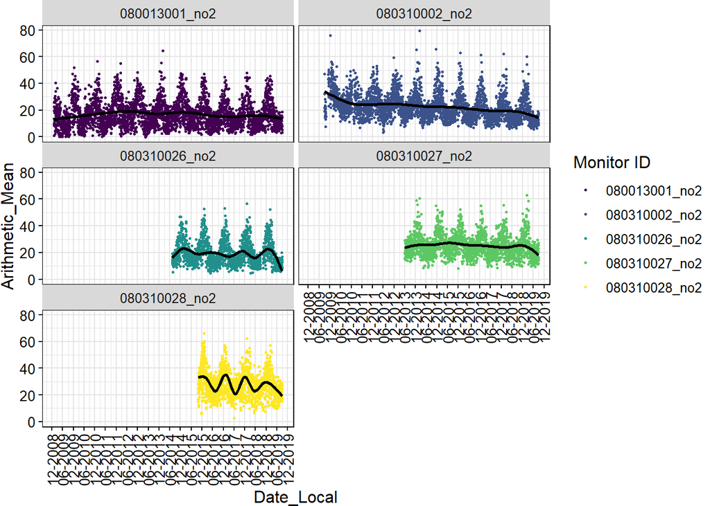

```r
no2_ts <- ggplot(data = no2_data, aes(x = Date_Local, y = Arithmetic_Mean)) +
  geom_point(aes(color = as.factor(monitor_id)), shape = 20, size = 1) +
  geom_smooth(se = F, color = "black") +
  scale_color_viridis(name = "Monitor ID", discrete = T) +
  scale_x_date(date_breaks = "6 months", date_labels = "%m-%Y") +
  facet_wrap(. ~ monitor_id, scales = "fixed", ncol = 2) +
  theme(axis.text.x = element_text(angle = 90, vjust = 0.5, hjust=1)) +
  simple_theme
no2_ts
```

Organize the observations and spatial data

```r
#' NO2 observations
no2_obs <- no2_data %>%
  dplyr::select(monitor_id, Date_Local, Arithmetic_Mean) %>%
  mutate(sample_week = as.character(as.Date(cut(as.Date(Date_Local), "week")))) %>%
  filter(sample_week %in% bc_weeks) %>%
  group_by(monitor_id, sample_week) %>%
  summarize(no2 = mean(Arithmetic_Mean, na.rm=T)) %>%
  pivot_wider(id_cols = sample_week,
              names_from = monitor_id, values_from = no2) %>%
  as.data.frame() %>%
  arrange(sample_week)
head(no2_obs)
```

|  | sample_week | 080013001_no2 | 080310002_no2 | 080310026_no2 | 080310027_no2 | 080310028_no2 |
| --- | --- | --- | --- | --- | --- | --- |
| 1 | 2008-12-29 | 12.47826 | NA | NA | NA | NA |
| 2 | 2009-01-05 | 14.65543 | NA | NA | NA | NA |
| 3 | 2009-01-12 | 22.89074 | NA | NA | NA | NA |
| 4 | 2009-01-19 | 17.04912 | NA | NA | NA | NA |
| 5 | 2009-01-26 | 18.17096 | NA | NA | NA | NA |
| 6 | 2009-02-02 | 21.35655 | NA | NA | NA | NA |

```r
# NO2 SP object
no2_data2 <- read_csv(here::here("Data", "Monitor_NO2_Data_AEA.csv")) %>%
  mutate(year = year(Date_Local)) %>%
  filter(year %in% c(2009:2019)) %>%
  dplyr::select(-year) %>%
  st_as_sf(wkt = "WKT", crs = albers) %>%
  mutate(monitor_id = paste0(monitor_id, "_no2")) %>%
  filter(monitor_id %in% colnames(no2_obs))
no2_coords <- do.call(rbind, st_geometry(no2_data2)) %>%
  as_tibble(.names_repair = c("x", "y"))
no2_sp_lonlat <- no2_data2 %>%
  st_transform(crs = ll_wgs84)
no2_coords2 <- do.call(rbind, st_geometry(no2_sp_lonlat)) %>%
  as_tibble() %>% setNames(c("lon","lat"))

no2_sp_cov <- st_set_geometry(no2_data2, NULL) %>%
  dplyr::select(monitor_id) %>%
  rename(ID = monitor_id)
no2_sp_cov <- bind_cols(no2_sp_cov, no2_coords, no2_coords2) %>%
  as.data.frame() %>%
  distinct()
```

Next, BC at the central site monitor

```r
#' BC central site concentrations
bc_cent_data <- read_csv(here::here("Data", "Monitor_BC_Data_AEA.csv")) %>%
  mutate(year = year(Date_Local)) %>%
  filter(year %in% c(2009:2019)) %>%
  dplyr::select(-year) %>%
  filter(County_Code %in% counties) %>%
  arrange(Date_Local, monitor_id)
#' Add an identifier to differentiate these measurements from collocated pollutants at the same site
bc_cent_data$monitor_id <- paste0(bc_cent_data$monitor_id, "_bc")
unique(bc_cent_data$monitor_id)
```

```
## [1] "080310027_bc"
```

Plot the time trends for BC at the central site monitor

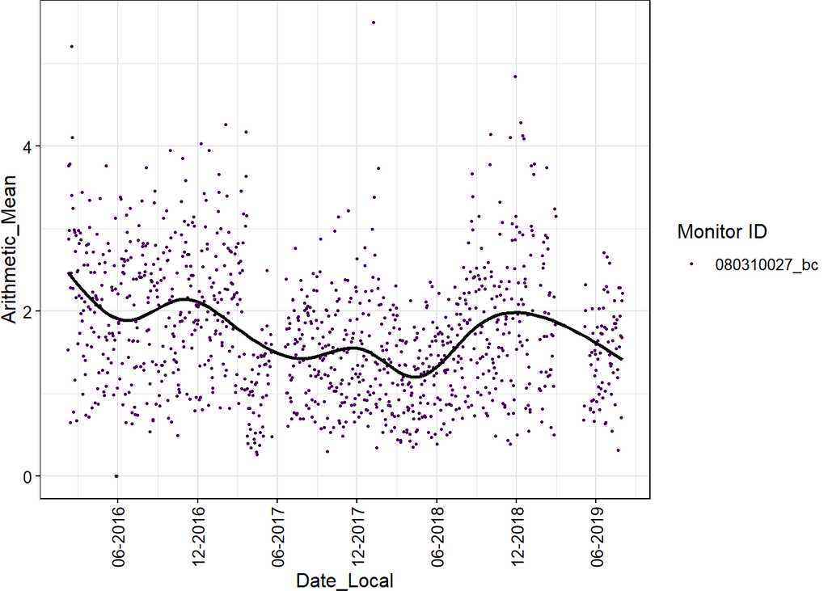

```r
bc_ts <- ggplot(data = bc_cent_data, aes(x = Date_Local, y = Arithmetic_Mean)) +
  geom_point(aes(color = as.factor(monitor_id)), shape = 20, size = 1) +
  geom_smooth(se = F, color = "black") +
  scale_color_viridis(name = "Monitor ID", discrete = T) +
  scale_x_date(date_breaks = "6 months", date_labels = "%m-%Y") +
  #facet_wrap(. ~ monitor_id, scales = "fixed", ncol = 2) +
  theme(axis.text.x = element_text(angle = 90, vjust = 0.5, hjust=1)) +
  simple_theme
bc_ts
```

Organize the observations and spatial data

```r
#' BC observations
bc_cent_obs <- bc_cent_data %>%
  dplyr::select(monitor_id, Date_Local, Arithmetic_Mean) %>%
  mutate(sample_week = as.character(as.Date(cut(as.Date(Date_Local), "week")))) %>%
  filter(sample_week %in% bc_weeks) %>%
  group_by(monitor_id, sample_week) %>%
  summarize(no2 = mean(Arithmetic_Mean, na.rm=T)) %>%
  pivot_wider(id_cols = sample_week,
              names_from = monitor_id, values_from = no2) %>%
  as.data.frame() %>%
  arrange(sample_week)
head(bc_cent_obs)
```

|  | sample_week | 080310027_bc |
| --- | --- | --- |
| 1 | 2016-02-08 | 2.551691 |
| 2 | 2016-02-15 | 3.068013 |
| 3 | 2016-02-22 | 2.226646 |
| 4 | 2016-02-29 | 2.329353 |
| 5 | 2016-03-07 | 2.321250 |
| 6 | 2016-03-14 | 1.646077 |

```r
# BC Central Site SP object
bc_cent_data2 <- read_csv(here::here("Data", "Monitor_BC_Data_AEA.csv")) %>%
  mutate(year = year(Date_Local)) %>%
  filter(year %in% c(2009:2019)) %>%
  dplyr::select(-year) %>%
  st_as_sf(wkt = "WKT", crs = albers) %>%
  mutate(monitor_id = paste0(monitor_id, "_bc")) %>%
  filter(monitor_id %in% colnames(bc_cent_obs))
bc_cent_coords <- do.call(rbind, st_geometry(bc_cent_data2)) %>%
  as_tibble(.names_repair = c("x", "y"))
bc_cent_sp_lonlat <- bc_cent_data2 %>%
  st_transform(crs = ll_wgs84)
bc_cent_coords2 <- do.call(rbind, st_geometry(bc_cent_sp_lonlat)) %>%
  as_tibble() %>% setNames(c("lon","lat"))

bc_cent_sp_cov <- st_set_geometry(bc_cent_data2, NULL) %>%
  dplyr::select(monitor_id) %>%
  rename(ID = monitor_id)
bc_cent_sp_cov <- bind_cols(bc_cent_sp_cov, bc_cent_coords, bc_cent_coords2) %>%
  as.data.frame() %>%
  distinct()
```

Lastly, PM2.5 from select monitors with long-term records

Plot the time trends for PM2.5 at the monitors

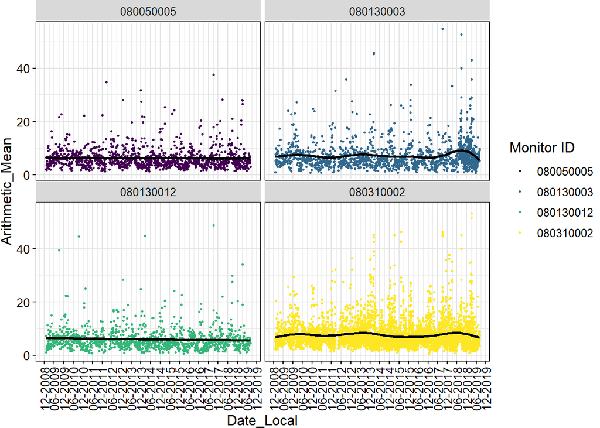

```r
pm_ts <- ggplot(data = pm_data, aes(x = Date_Local, y = Arithmetic_Mean)) +
  geom_point(aes(color = as.factor(monitor_id)), shape = 20, size = 1) +
  geom_smooth(se = F, color = "black") +
  scale_color_viridis(name = "Monitor ID", discrete = T) +
  scale_x_date(date_breaks = "6 months", date_labels = "%m-%Y") +
  facet_wrap(. ~ monitor_id, scales = "fixed", ncol = 2) +
  theme(axis.text.x = element_text(angle = 90, vjust = 0.5, hjust=1)) +
  simple_theme
pm_ts
```

Organize the observations and spatial data

```r
#' Add an identifier to differentiate these measurements from collocated pollutants at the same site
pm_data$monitor_id <- paste0(pm_data$monitor_id, "_pm")
unique(pm_data$monitor_id)
```

```
## [1] "080050005_pm" "080130003_pm" "080130012_pm" "080310002_pm"
```

```r
#' PM2.5 observations
pm_obs <- pm_data %>%
  dplyr::select(monitor_id, Date_Local, Arithmetic_Mean) %>%
  mutate(sample_week = as.character(as.Date(cut(as.Date(Date_Local), "week")))) %>%
  filter(sample_week %in% bc_weeks) %>%
  group_by(monitor_id, sample_week) %>%
  summarize(no2 = mean(Arithmetic_Mean, na.rm=T)) %>%
  pivot_wider(id_cols = sample_week,
              names_from = monitor_id, values_from = no2) %>%
  as.data.frame() %>%
  arrange(sample_week)
head(pm_obs)
```

|  | sample_week | 080050005_pm | 080130003_pm | 080130012_pm | 080310002_pm |
| --- | --- | --- | --- | --- | --- |
| 1 | 2008-12-29 | 4.15 | 4.300000 | 4.30 | 4.150000 |
| 2 | 2009-01-05 | 2.00 | 3.100000 | 2.45 | 3.600000 |
| 3 | 2009-01-12 | 3.95 | 8.350000 | 3.50 | 7.075000 |
| 4 | 2009-01-19 | 5.95 | 6.033333 | 5.10 | 8.011111 |
| 5 | 2009-01-26 | 3.30 | 6.800000 | 2.25 | 4.466667 |
| 6 | 2009-02-02 | 3.25 | 6.000000 | 3.25 | 6.287500 |

```r
# PM SP object
pm_data2 <- read_csv(here::here("Data", "Monitor_pm_Data_AEA.csv")) %>%
  mutate(year = year(Date_Local)) %>%
  filter(year %in% c(2009:2019)) %>%
  dplyr::select(-year) %>%
  st_as_sf(wkt = "WKT", crs = albers) %>%
  mutate(monitor_id = paste0(monitor_id, "_pm")) %>%
  filter(monitor_id %in% colnames(pm_obs))
pm_coords <- do.call(rbind, st_geometry(pm_data2)) %>%
  as_tibble(.names_repair = c("x", "y"))
pm_sp_lonlat <- pm_data2 %>%
  st_transform(crs = ll_wgs84)
pm_coords2 <- do.call(rbind, st_geometry(pm_sp_lonlat)) %>%
  as_tibble() %>% setNames(c("lon","lat"))

pm_sp_cov <- st_set_geometry(pm_data2, NULL) %>%
  dplyr::select(monitor_id) %>%
  rename(ID = monitor_id)
pm_sp_cov <- bind_cols(pm_sp_cov, pm_coords, pm_coords2) %>%
  as.data.frame() %>%
  distinct()
```

Combine the observations and the spatial covariates

```r
#' Observations
pol_obs <- left_join(no2_obs, bc_cent_obs, by = "sample_week") %>%
  left_join(pm_obs, by = "sample_week")
glimpse(pol_obs)
```

```
## Rows: 526
## Columns: 11
## $ sample_week     <chr> "2008-12-29", "2009-01-05", "2009-01-12", "2009-01-...
## $ `080013001_no2` <dbl> 12.478261, 14.655427, 22.890740, 17.049125, 18.1709...
## $ `080310002_no2` <dbl> NA, NA, NA, NA, NA, NA, NA, NA, NA, NA, NA, NA, NA,...
## $ `080310026_no2` <dbl> NA, NA, NA, NA, NA, NA, NA, NA, NA, NA, NA, NA, NA,...
## $ `080310027_no2` <dbl> NA, NA, NA, NA, NA, NA, NA, NA, NA, NA, NA, NA, NA,...
## $ `080310028_no2` <dbl> NA, NA, NA, NA, NA, NA, NA, NA, NA, NA, NA, NA, NA,...
## $ `080310027_bc`  <dbl> NA, NA, NA, NA, NA, NA, NA, NA, NA, NA, NA, NA, NA,...
## $ `080050005_pm`  <dbl> 4.150000, 2.000000, 3.950000, 5.950000, 3.300000, 3...
## $ `080130003_pm`  <dbl> 4.300000, 3.100000, 8.350000, 6.033333, 6.800000, 6...
## $ `080130012_pm`  <dbl> 4.300000, 2.450000, 3.500000, 5.100000, 2.250000, 3...
## $ `080310002_pm`  <dbl> 4.150000, 3.600000, 7.075000, 8.011111, 4.466667, 6...
```

```r
#' Scale the measurements to avoid issues where units are different
#' Scale the data by columns (monitors)
rownames(pol_obs) <- pol_obs$sample_week
pol_obs$sample_week <- NULL
pol_obs <- as.matrix(pol_obs)

rnames <- rownames(pol_obs)
cnames <- colnames(pol_obs)

pol_obs <- apply(pol_obs, 2, scale)

rownames(pol_obs) <- rnames
colnames(pol_obs) <- cnames

head(rownames(pol_obs))
```

```
## [1] "2008-12-29" "2009-01-05" "2009-01-12" "2009-01-19" "2009-01-26"
## [6] "2009-02-02"
```

```r
head(colnames(pol_obs))
```

```
## [1] "080013001_no2" "080310002_no2" "080310026_no2" "080310027_no2"
## [5] "080310028_no2" "080310027_bc"
```

```r
class(pol_obs)
```

```
## [1] "matrix"
```

```r
dim(pol_obs)
```

```
## [1] 526  10
```

```r
#' SP variables
pol_sp_cov <- bind_rows(no2_sp_cov, bc_cent_sp_cov, pm_sp_cov)
pol_sp_cov
```

| ID | V1 | V2 | lon | lat |
| --- | --- | --- | --- | --- |
| 080013001_no2 | -757945.7 | 1904555 | -104.9498 | 39.83812 |
| 080310002_no2 | -762056.1 | 1895159 | -104.9876 | 39.75118 |
| 080310027_no2 | -764597.4 | 1893260 | -105.0153 | 39.73217 |
| 080310026_no2 | -763240.0 | 1898458 | -105.0052 | 39.77949 |
| 080310028_no2 | -761769.0 | 1899062 | -104.9886 | 39.78610 |
| 080310027_bc | -764597.4 | 1893260 | -105.0153 | 39.73217 |
| 080050005_pm | -766311.6 | 1879040 | -105.0195 | 39.60440 |
| 080130003_pm | -767198.6 | 1942180 | -105.1009 | 40.16458 |
| 080130012_pm | -782420.9 | 1927505 | -105.2634 | 40.02110 |
| 080310002_pm | -762056.1 | 1895159 | -104.9876 | 39.75118 |

Create the data object

```r
pol_STdata <- createSTdata(obs = pol_obs,
                           covars = pol_sp_cov)
print(pol_STdata)
```

```
## STdata-object with:
##  No. locations: 10 (observed: 10)
##  No. time points: 526 (observed: 526)
##  No. obs: 3919
##
## Only constant temporal trend,with dates:
##  2008-12-29 to 2019-02-04
##
## 5 covariate(s):
## [1] "ID"  "V1"  "V2"  "lon" "lat"
##
## No spatio-temporal covariates.
```

## 2.3 Generate the temporal trend

The cross validation results for generating the time trends suggest 2 basis functions is the way to go, but let’s see if that holds up with our data

```r
D_pol <- createDataMatrix(pol_STdata)
#D_pol

unique(as.Date(cut(as.Date(rownames(pol_obs)), "year")))
```

```
##  [1] "2008-01-01" "2009-01-01" "2010-01-01" "2011-01-01" "2012-01-01"
##  [6] "2013-01-01" "2014-01-01" "2015-01-01" "2016-01-01" "2017-01-01"
## [11] "2018-01-01" "2019-01-01"
```

```r
n_years <- length(unique(as.Date(cut(as.Date(rownames(pol_obs)), "year"))))
n_years
```

```
## [1] 12
```

```r
#' Trying 4 df per year
pol.SVD.cv.4py <- SVDsmoothCV(D_pol, 0:4, df = n_years * 4)
print(pol.SVD.cv.4py)
```

```
## Result of SVDsmoothCV, average of CV-statistics:
##                 MSE        R2          AIC         BIC
## n.basis.0 0.9974483 0.0000000    0.9987215    5.051642
## n.basis.1 0.7200304 0.2782434 -146.2166177 -138.110777
## n.basis.2 0.6223992 0.3760965 -212.9293073 -200.770547
## n.basis.3 0.6149521 0.3835795 -215.5469308 -199.335250
## n.basis.4 0.6131663 0.3853614 -216.0657061 -195.801106
```

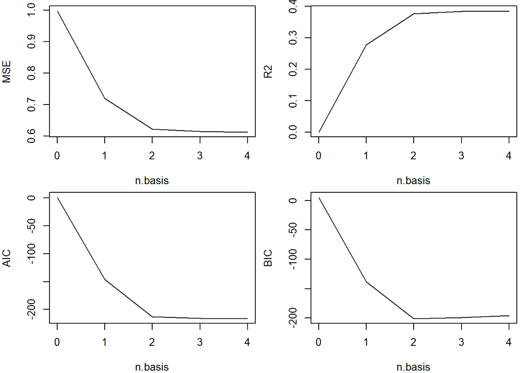

```r
plot(pol.SVD.cv.4py)
```

```r
#' Trying 8 df per year
pol.SVD.cv.8py <- SVDsmoothCV(D_pol, 0:4, df = n_years * 8)
print(pol.SVD.cv.8py)
```

```
## Result of SVDsmoothCV, average of CV-statistics:
##                 MSE        R2          AIC         BIC
## n.basis.0 0.9974483 0.0000000    0.9987215    5.051642
## n.basis.1 0.7136272 0.2846414 -144.7567445 -136.650904
## n.basis.2 0.5631127 0.4355131 -256.1891888 -244.030428
## n.basis.3 0.5553968 0.4432620 -259.8496664 -243.637986
## n.basis.4 0.5553973 0.4432551 -258.8155471 -238.550946
```

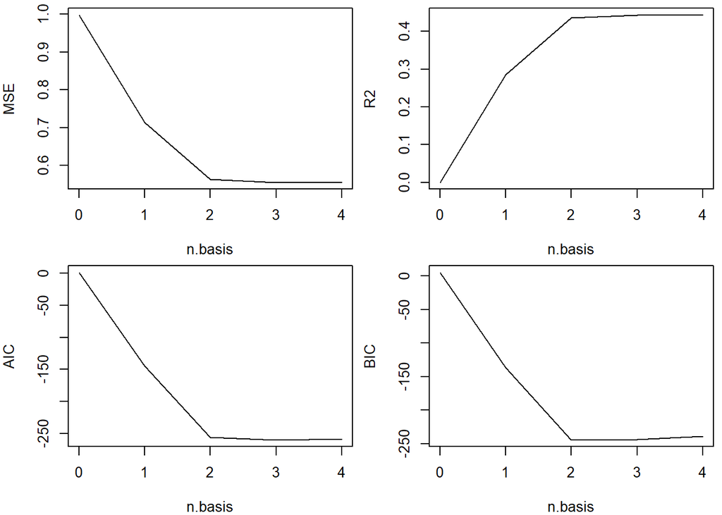

```r
plot(pol.SVD.cv.8py)
```

## 2.4 Plot the time trends

I tried using 1 and 2 basis functions for the time trends. I also did 3, just to see what would happen.

### 2.4.1 1 basis function

First, see what the time trends for the monitoring data look like with 1 basis function. Testing out 4 df per year and 8 df per year

**4 df per year**

```r
pol_STdata1 <- updateTrend(pol_STdata, n.basis = 1, df = n_years*4)
```

```
## Replacing existing trend.
```

```r
pol_STdata1
```

```
## STdata-object with:
##  No. locations: 10 (observed: 10)
##  No. time points: 526 (observed: 526)
##  No. obs: 3919
##
## Trend with 1 basis function(s):
## [1] "V1"
## with dates:
##  2008-12-29 to 2019-02-04
##
## 5 covariate(s):
## [1] "ID"  "V1"  "V2"  "lon" "lat"
##
## No spatio-temporal covariates.
```

```r
head(pol_STdata1$trend)
```

|  | V1 | date |
| --- | --- | --- |
| 1 | -1.3474812 | 2008-12-29 |
| 2 | -1.2177521 | 2009-01-05 |
| 3 | -1.0914353 | 2009-01-12 |
| 4 | -0.9721836 | 2009-01-19 |
| 5 | -0.8636499 | 2009-01-26 |
| 6 | -0.7689160 | 2009-02-02 |

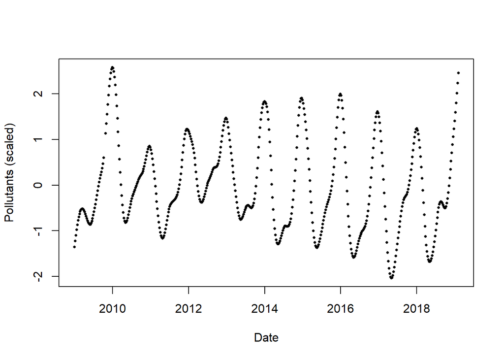

```r
plot(pol_STdata1$trend$date, pol_STdata1$trend$V1, col = 1, pch = 16, cex = 0.5,
     xlab = "Date", ylab = "Pollutants (scaled)")
lines(pol_STdata1$trend$date, pol_STdata1$atrend$V1, col = 1)
```

**8 df per year**

```r
pol_STdata1b <- updateTrend(pol_STdata, n.basis = 1, df = n_years*8)
```

```
## Replacing existing trend.
```

```r
pol_STdata1b
```

```
## STdata-object with:
##  No. locations: 10 (observed: 10)
##  No. time points: 526 (observed: 526)
##  No. obs: 3919
##
## Trend with 1 basis function(s):
## [1] "V1"
## with dates:
##  2008-12-29 to 2019-02-04
##
## 5 covariate(s):
## [1] "ID"  "V1"  "V2"  "lon" "lat"
##
## No spatio-temporal covariates.
```

```r
head(pol_STdata1b$trend)
```

|  | V1 | date |
| --- | --- | --- |
| 1 | -1.5369587 | 2008-12-29 |
| 2 | -1.2360801 | 2009-01-05 |
| 3 | -0.9676989 | 2009-01-12 |
| 4 | -0.7463046 | 2009-01-19 |
| 5 | -0.5863868 | 2009-01-26 |
| 6 | -0.4959363 | 2009-02-02 |

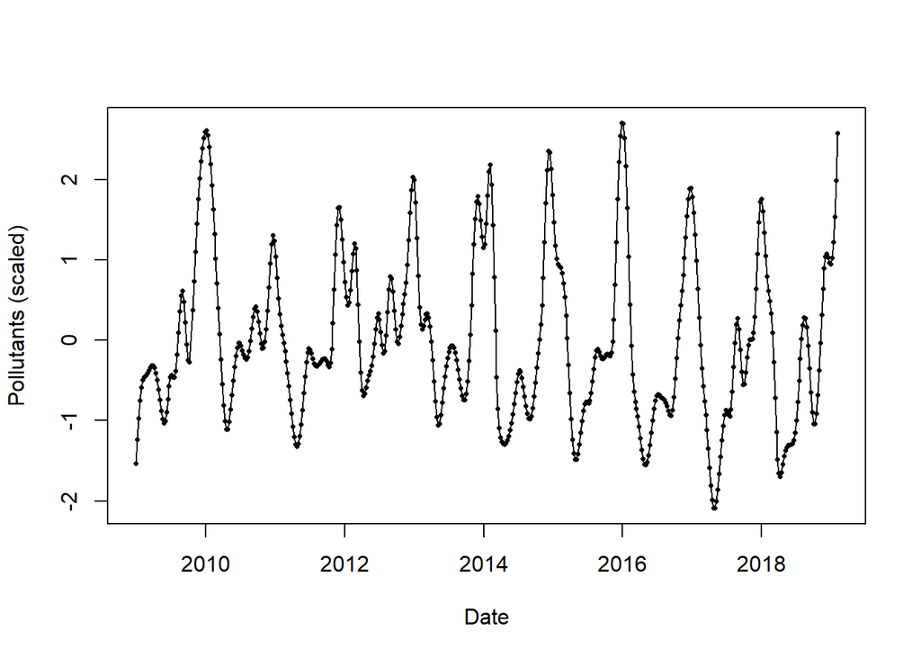

```r
plot(pol_STdata1b$trend$date, pol_STdata1b$trend$V1, col = 1, pch = 16, cex = 0.5,
     xlab = "Date", ylab = "Pollutants (scaled)")
lines(pol_STdata1b$trend$date, pol_STdata1b$trend$V1, col = 1)
```

### 2.4.2 2 basis functions

Next, let’s see what 2 basis functions look like:

**4 df per year**

```r
pol_STdata2 <- updateTrend(pol_STdata, n.basis = 2, df = n_years * 4)
```

```
## Replacing existing trend.
```

```r
pol_STdata2
```

```
## STdata-object with:
##  No. locations: 10 (observed: 10)
##  No. time points: 526 (observed: 526)
##  No. obs: 3919
##
## Trend with 2 basis function(s):
## [1] "V1" "V2"
## with dates:
##  2008-12-29 to 2019-02-04
##
## 5 covariate(s):
## [1] "ID"  "V1"  "V2"  "lon" "lat"
##
## No spatio-temporal covariates.
```

```r
head(pol_STdata2$trend)
```

|  | V1 | V2 | date |
| --- | --- | --- | --- |
| 1 | -0.3639487 | 1.7626825 | 2008-12-29 |
| 2 | -0.3193079 | 1.6096054 | 2009-01-05 |
| 3 | -0.2798467 | 1.4530579 | 2009-01-12 |
| 4 | -0.2496635 | 1.2920284 | 2009-01-19 |
| 5 | -0.2328565 | 1.1255055 | 2009-01-26 |
| 6 | -0.2326886 | 0.9530059 | 2009-02-02 |

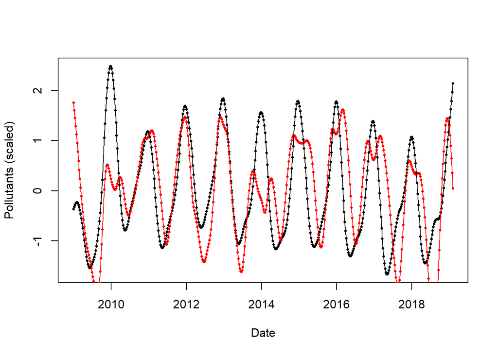

```r
plot(pol_STdata2$trend$date, pol_STdata2$trend$V1, col = 1, pch = 16, cex = 0.5,
     xlab = "Date", ylab = "Pollutants (scaled)")
points(pol_STdata2$trend$date, pol_STdata2$trend$V2, col = 2, pch = 16, cex = 0.5)
lines(pol_STdata2$trend$date, pol_STdata2$trend$V1, col = 1)
lines(pol_STdata2$trend$date, pol_STdata2$trend$V2, col = 2)
```

**8 df per year**

```r
pol_STdata2b <- updateTrend(pol_STdata, n.basis = 2, df = n_years * 8)
```

```
## Replacing existing trend.
```

```r
pol_STdata2b
```

```
## STdata-object with:
##  No. locations: 10 (observed: 10)
##  No. time points: 526 (observed: 526)
##  No. obs: 3919
##
## Trend with 2 basis function(s):
## [1] "V1" "V2"
## with dates:
##  2008-12-29 to 2019-02-04
##
## 5 covariate(s):
## [1] "ID"  "V1"  "V2"  "lon" "lat"
##
## No spatio-temporal covariates.
```

```r
head(pol_STdata2b$trend)
```

|  | V1 | V2 | date |
| --- | --- | --- | --- |
| 1 | -0.85892257 | 1.2275551 | 2008-12-29 |
| 2 | -0.52113424 | 1.2764666 | 2009-01-05 |
| 3 | -0.25145883 | 1.2659452 | 2009-01-12 |
| 4 | -0.06303721 | 1.1988328 | 2009-01-19 |
| 5 | 0.03098970 | 1.0779711 | 2009-01-26 |
| 6 | 0.02607795 | 0.9095436 | 2009-02-02 |

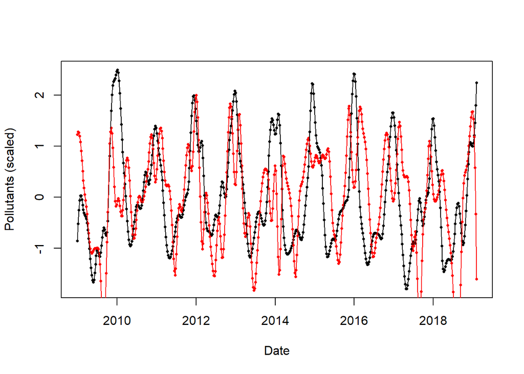

```r
plot(pol_STdata2b$trend$date, pol_STdata2b$trend$V1, col = 1, pch = 16, cex = 0.5,
     xlab = "Date", ylab = "Pollutants (scaled)")
points(pol_STdata2b$trend$date, pol_STdata2b$trend$V2, col = 2, pch = 16, cex = 0.5)
lines(pol_STdata2b$trend$date, pol_STdata2b$trend$V1, col = 1)
lines(pol_STdata2b$trend$date, pol_STdata2b$trend$V2, col = 2)
```

### 2.4.3 3 basis functions

Next, let’s see what 3 basis functions look like: (This might be pushing the limits of our data– I’m mostly just doing it to see what’s going on)

**4 df per year**

```r
pol_STdata3 <- updateTrend(pol_STdata, n.basis = 3, df = n_years * 4)
```

```
## Replacing existing trend.
```

```r
pol_STdata3
```

```
## STdata-object with:
##  No. locations: 10 (observed: 10)
##  No. time points: 526 (observed: 526)
##  No. obs: 3919
##
## Trend with 3 basis function(s):
## [1] "V1" "V2" "V3"
## with dates:
##  2008-12-29 to 2019-02-04
##
## 5 covariate(s):
## [1] "ID"  "V1"  "V2"  "lon" "lat"
##
## No spatio-temporal covariates.
```

```r
head(pol_STdata3$trend)
```

|  | V1 | V2 | V3 | date |
| --- | --- | --- | --- | --- |
| 1 | -0.5067204 | 0.07063473 | -1.6831429 | 2008-12-29 |
| 2 | -0.4341530 | 0.02477088 | -1.5392402 | 2009-01-05 |
| 3 | -0.3683186 | -0.01887571 | -1.3916565 | 2009-01-12 |
| 4 | -0.3156850 | -0.05501372 | -1.2390945 | 2009-01-19 |
| 5 | -0.2827198 | -0.07835182 | -1.0802565 | 2009-01-26 |
| 6 | -0.2744175 | -0.08522862 | -0.9144273 | 2009-02-02 |

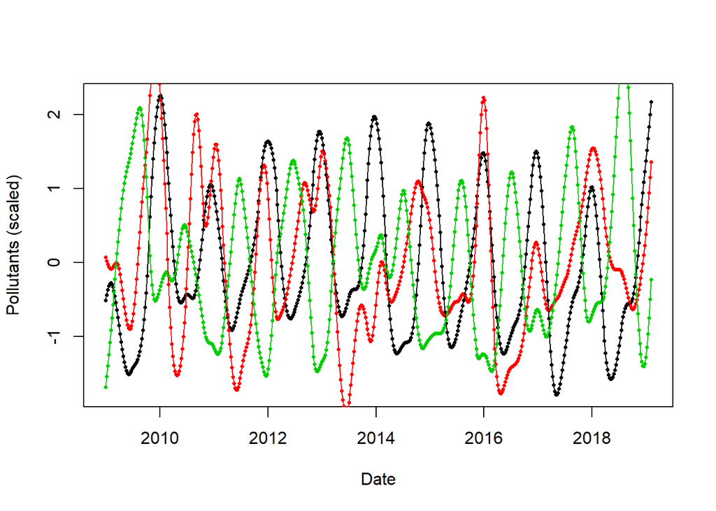

```r
plot(pol_STdata3$trend$date, pol_STdata3$trend$V1, col = 1, pch = 16, cex = 0.5,
     xlab = "Date", ylab = "Pollutants (scaled)")
points(pol_STdata3$trend$date, pol_STdata3$trend$V2, col = 2, pch = 16, cex = 0.5)
points(pol_STdata3$trend$date, pol_STdata3$trend$V3, col = 3, pch = 16, cex = 0.5)
lines(pol_STdata3$trend$date, pol_STdata3$trend$V1, col = 1)
lines(pol_STdata3$trend$date, pol_STdata3$trend$V2, col = 2)
lines(pol_STdata3$trend$date, pol_STdata3$trend$V3, col = 3)
```

**8 df per year**

```r
pol_STdata3b <- updateTrend(pol_STdata, n.basis = 3, df = n_years * 8)
```

```
## Replacing existing trend.
```

```r
pol_STdata3b
```

```
## STdata-object with:
##  No. locations: 10 (observed: 10)
##  No. time points: 526 (observed: 526)
##  No. obs: 3919
##
## Trend with 3 basis function(s):
## [1] "V1" "V2" "V3"
## with dates:
##  2008-12-29 to 2019-02-04
##
## 5 covariate(s):
## [1] "ID"  "V1"  "V2"  "lon" "lat"
##
## No spatio-temporal covariates.
```

```r
head(pol_STdata3b$trend)
```

|  | V1 | V2 | V3 | date |
| --- | --- | --- | --- | --- |
| 1 | -1.22023528 | 0.47710122 | -1.1593005 | 2008-12-29 |
| 2 | -0.73392155 | 0.22298757 | -1.2302775 | 2009-01-05 |
| 3 | -0.32414068 | -0.03661732 | -1.2391341 | 2009-01-12 |
| 4 | -0.01936664 | -0.26474450 | -1.1873630 | 2009-01-19 |
| 5 | 0.15192658 | -0.42442499 | -1.0764565 | 2009-01-26 |
| 6 | 0.17424651 | -0.48713531 | -0.9117957 | 2009-02-02 |

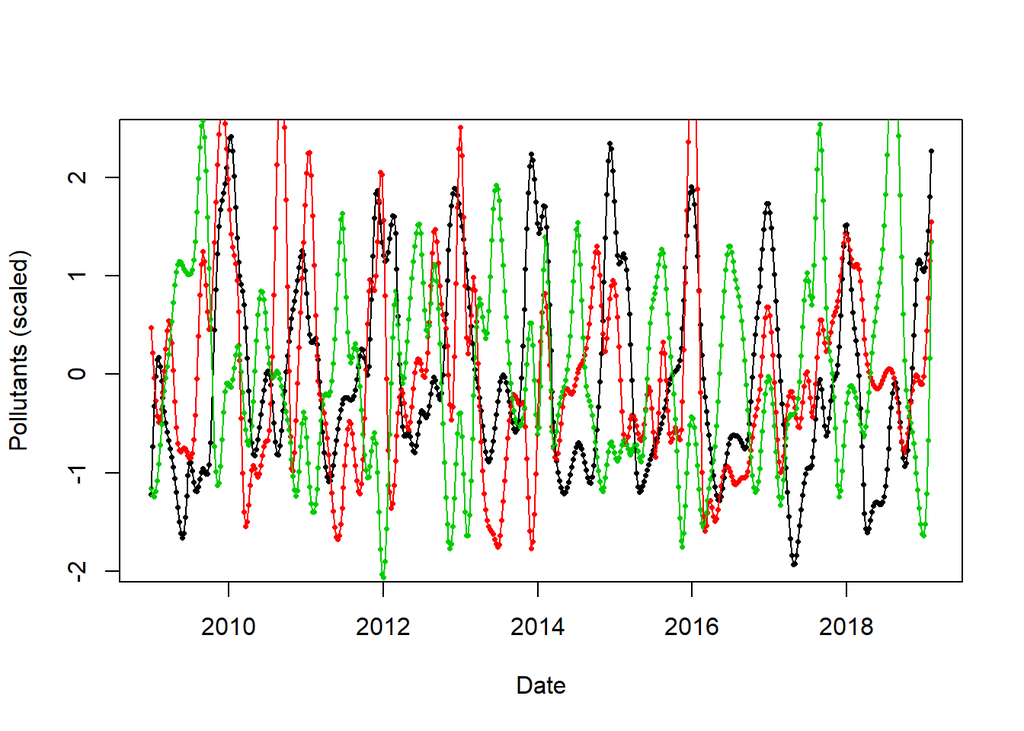

```r
plot(pol_STdata3b$trend$date, pol_STdata3b$trend$V1, col = 1, pch = 16, cex = 0.5,
     xlab = "Date", ylab = "Pollutants (scaled)")
points(pol_STdata3b$trend$date, pol_STdata3b$trend$V2, col = 2, pch = 16, cex = 0.5)
points(pol_STdata3b$trend$date, pol_STdata3b$trend$V3, col = 3, pch = 16, cex = 0.5)
lines(pol_STdata3b$trend$date, pol_STdata3b$trend$V1, col = 1)
lines(pol_STdata3b$trend$date, pol_STdata3b$trend$V2, col = 2)
lines(pol_STdata3b$trend$date, pol_STdata3b$trend$V3, col = 3)
```

Note that the two basis function plot based on the updated monitoring data set (which includes PM2.5) looks different from when it did with just the NO2 and BC data

## 2.5 Update the Denver data set

The next step is to update the trend data for the `denver.data` object and see if these trend data fit our observations

### 2.5.1 1 basis function

```r
denver.data2.1 <- denver.data
denver.data2.1$trend <- pol_STdata1$trend
print(denver.data2.1)
```

```
## STdata-object with:
##  No. locations: 61 (observed: 61)
##  No. time points: 526 (observed: 152)
##  No. obs: 767
##
## Trend with 1 basis function(s):
## [1] "V1"
## with dates:
##  2008-12-29 to 2019-02-04
##
## 19 covariate(s):
##  [1] "ID"                  "lon"                 "lat"
##  [4] "impervious_2500"     "open_2500"           "low_int_100"
##  [7] "med_int_50"          "high_int_50"         "high_int_100"
## [10] "ag_250"              "pop_den_50"          "dist_m_compost"
## [13] "dist_m_military"     "len_m_highways_2500" "aadt_100"
## [16] "aadt_2500"           "x"                   "y"
## [19] "type"
##
## 2 spatio-temporal covariate(s):
## [1] "bc_st_no2" "bc_st_smk"
##
## All sites:
## central    dist
##       1      60
## Observed:
## central    dist
##       1      60
##
## For central:
##   Number of obs: 152
##   Dates: 2016-02-08 to 2019-02-04
## For dist:
##   Number of obs: 615
##   Dates: 2018-05-07 to 2018-11-12
```

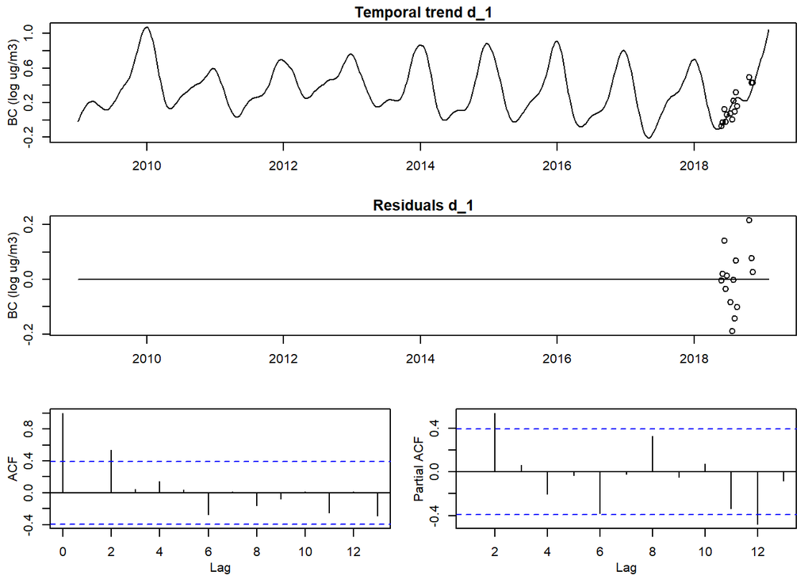

```r
par(mar=c(3.3,3.3,1.5,1), mgp=c(2,1,0))
layout(matrix(c(1,1,2,2,3,4), 3, 2, byrow=TRUE))
plot(denver.data2.1, "obs", ID="d_1", xlab="", ylab="BC (log ug/m3)",
     main="Temporal trend d_1")
plot(denver.data2.1, "res", ID="d_1", xlab="", ylab="BC (log ug/m3)")
plot(denver.data2.1, "acf", ID="d_1")
plot(denver.data2.1, "pacf", ID="d_1")
```

[figure not shown]

```r
par(mar=c(3.3,3.3,1.5,1), mgp=c(2,1,0))
layout(matrix(c(1,1,2,2,3,4), 3, 2, byrow=TRUE))
plot(denver.data2.1, "obs", ID="d_10", xlab="", ylab="BC (log ug/m3)",
     main="Temporal trend d_20")
plot(denver.data2.1, "res", ID="d_10", xlab="", ylab="BC (log ug/m3)")
plot(denver.data2.1, "acf", ID="d_10")
plot(denver.data2.1, "pacf", ID="d_10")
```

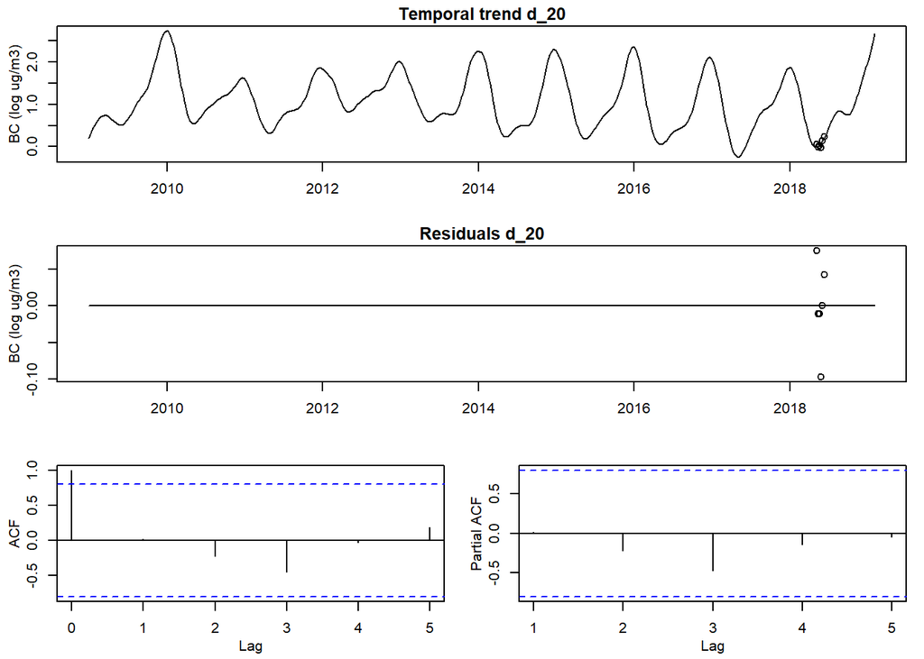

```r
par(mar=c(3.3,3.3,1.5,1), mgp=c(2,1,0))
layout(matrix(c(1,1,2,2,3,4), 3, 2, byrow=TRUE))
plot(denver.data2.1, "obs", ID="d_20", xlab="", ylab="BC (log ug/m3)",
     main="Temporal trend d_20")
plot(denver.data2.1, "res", ID="d_20", xlab="", ylab="BC (log ug/m3)")
plot(denver.data2.1, "acf", ID="d_20")
plot(denver.data2.1, "pacf", ID="d_20")
```

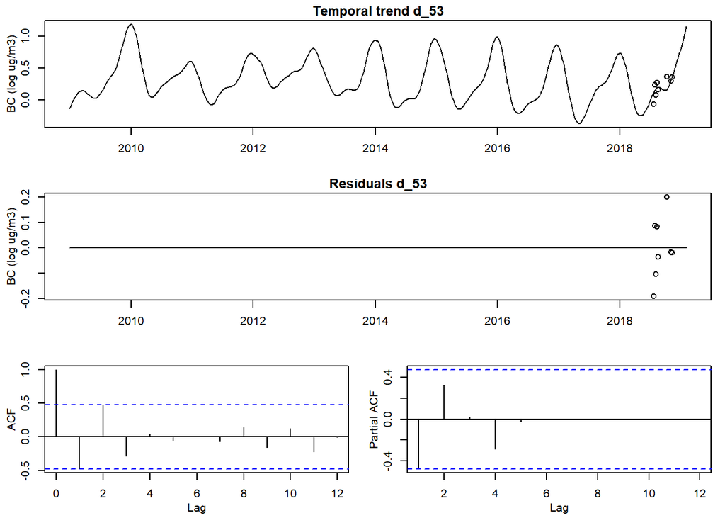

```r
par(mar=c(3.3,3.3,1.5,1), mgp=c(2,1,0))
layout(matrix(c(1,1,2,2,3,4), 3, 2, byrow=TRUE))
plot(denver.data2.1, "obs", ID="d_53", xlab="", ylab="BC (log ug/m3)",
     main="Temporal trend d_53")
plot(denver.data2.1, "res", ID="d_53", xlab="", ylab="BC (log ug/m3)")
plot(denver.data2.1, "acf", ID="d_53")
plot(denver.data2.1, "pacf", ID="d_53")
```

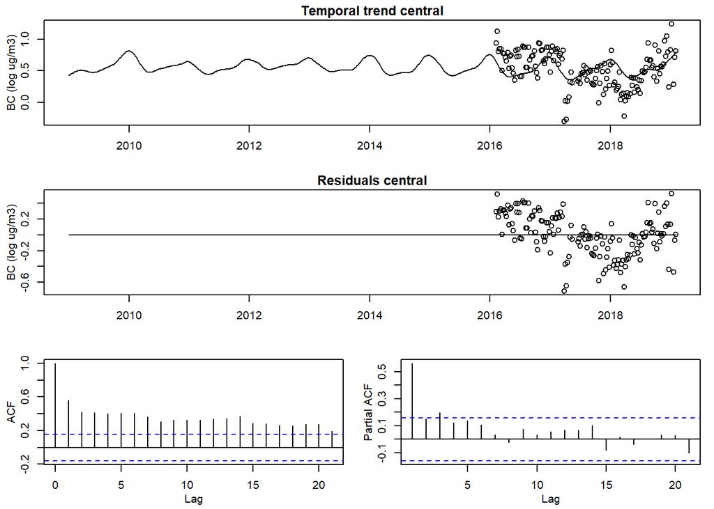

```r
par(mar=c(3.3,3.3,1.5,1), mgp=c(2,1,0))
layout(matrix(c(1,1,2,2,3,4), 3, 2, byrow=TRUE))
plot(denver.data2.1, "obs", ID="central", xlab="", ylab="BC (log ug/m3)",
     main="Temporal trend central")
plot(denver.data2.1, "res", ID="central", xlab="", ylab="BC (log ug/m3)")
plot(denver.data2.1, "acf", ID="central")
plot(denver.data2.1, "pacf", ID="central")
```

### 2.5.2 2 basis functions

```r
denver.data2.2 <- denver.data
denver.data2.2$trend <- pol_STdata2$trend
print(denver.data2.2)
```

```
## STdata-object with:
##  No. locations: 61 (observed: 61)
##  No. time points: 526 (observed: 152)
##  No. obs: 767
##
## Trend with 2 basis function(s):
## [1] "V1" "V2"
## with dates:
##  2008-12-29 to 2019-02-04
##
## 19 covariate(s):
##  [1] "ID"                  "lon"                 "lat"
##  [4] "impervious_2500"     "open_2500"           "low_int_100"
##  [7] "med_int_50"          "high_int_50"         "high_int_100"
## [10] "ag_250"              "pop_den_50"          "dist_m_compost"
## [13] "dist_m_military"     "len_m_highways_2500" "aadt_100"
## [16] "aadt_2500"           "x"                   "y"
## [19] "type"
##
## 2 spatio-temporal covariate(s):
## [1] "bc_st_no2" "bc_st_smk"
##
## All sites:
## central    dist
##       1      60
## Observed:
## central    dist
##       1      60
##
## For central:
##   Number of obs: 152
##   Dates: 2016-02-08 to 2019-02-04
## For dist:
##   Number of obs: 615
##   Dates: 2018-05-07 to 2018-11-12
```

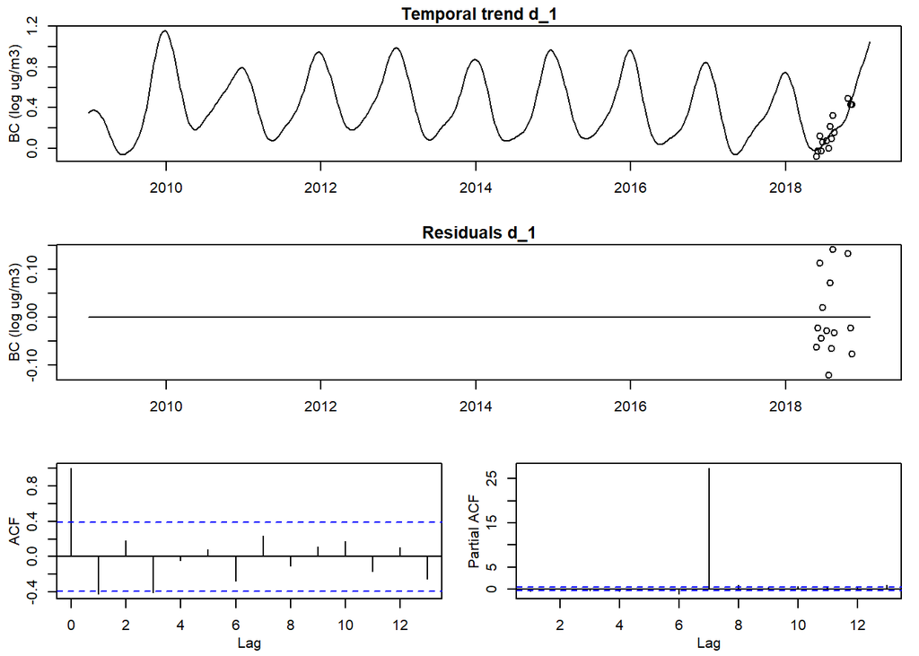

```r
par(mar=c(3.3,3.3,1.5,1), mgp=c(2,1,0))
layout(matrix(c(1,1,2,2,3,4), 3, 2, byrow=TRUE))
plot(denver.data2.2, "obs", ID="d_1", xlab="", ylab="BC (log ug/m3)",
     main="Temporal trend d_1")
plot(denver.data2.2, "res", ID="d_1", xlab="", ylab="BC (log ug/m3)")
plot(denver.data2.2, "acf", ID="d_1")
plot(denver.data2.2, "pacf", ID="d_1")
```

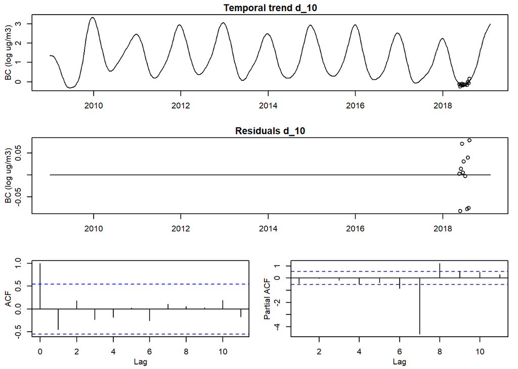

```r
par(mar=c(3.3,3.3,1.5,1), mgp=c(2,1,0))
layout(matrix(c(1,1,2,2,3,4), 3, 2, byrow=TRUE))
plot(denver.data2.2, "obs", ID="d_10", xlab="", ylab="BC (log ug/m3)",
     main="Temporal trend d_10")
plot(denver.data2.2, "res", ID="d_10", xlab="", ylab="BC (log ug/m3)")
plot(denver.data2.2, "acf", ID="d_10")
plot(denver.data2.2, "pacf", ID="d_10")
```

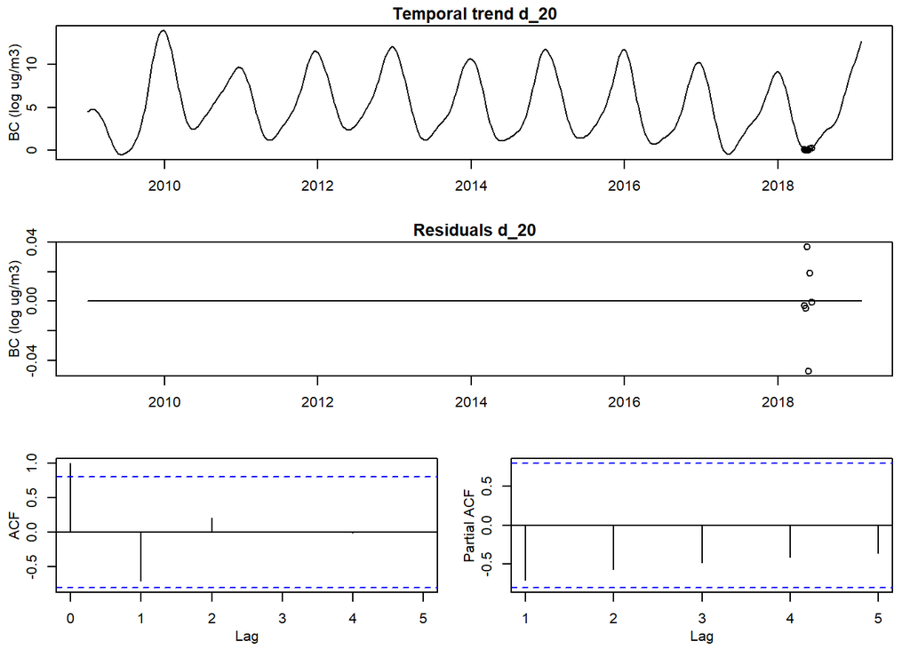

```r
par(mar=c(3.3,3.3,1.5,1), mgp=c(2,1,0))
layout(matrix(c(1,1,2,2,3,4), 3, 2, byrow=TRUE))
plot(denver.data2.2, "obs", ID="d_20", xlab="", ylab="BC (log ug/m3)",
     main="Temporal trend d_20")
plot(denver.data2.2, "res", ID="d_20", xlab="", ylab="BC (log ug/m3)")
plot(denver.data2.2, "acf", ID="d_20")
plot(denver.data2.2, "pacf", ID="d_20")
```

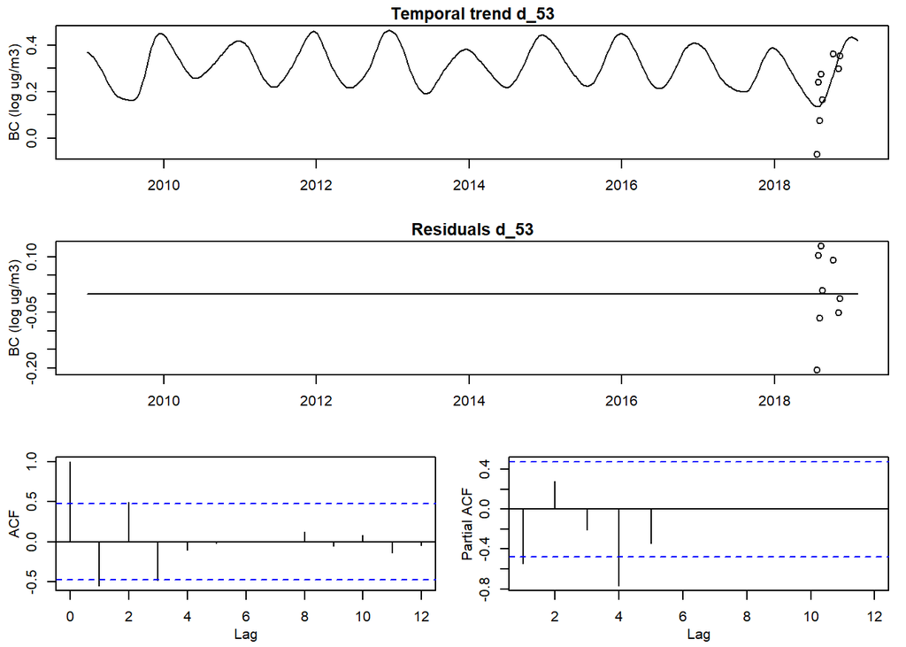

```r
par(mar=c(3.3,3.3,1.5,1), mgp=c(2,1,0))
layout(matrix(c(1,1,2,2,3,4), 3, 2, byrow=TRUE))
plot(denver.data2.2, "obs", ID="d_53", xlab="", ylab="BC (log ug/m3)",
     main="Temporal trend d_53")
plot(denver.data2.2, "res", ID="d_53", xlab="", ylab="BC (log ug/m3)")
plot(denver.data2.2, "acf", ID="d_53")
plot(denver.data2.2, "pacf", ID="d_53")
```

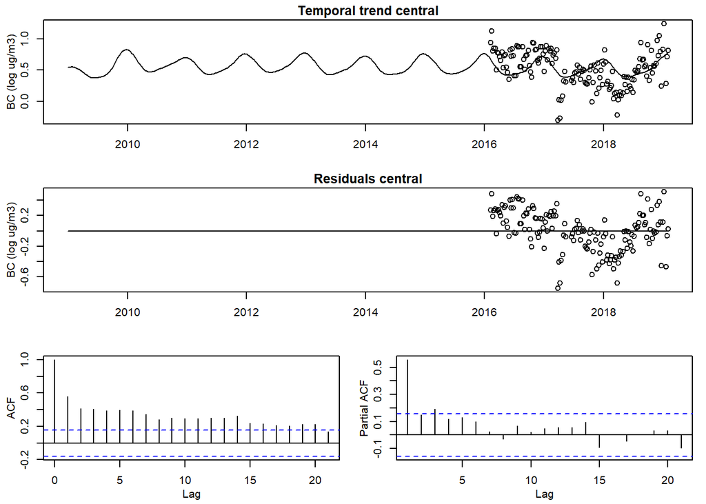

```r
par(mar=c(3.3,3.3,1.5,1), mgp=c(2,1,0))
layout(matrix(c(1,1,2,2,3,4), 3, 2, byrow=TRUE))
plot(denver.data2.2, "obs", ID="central", xlab="", ylab="BC (log ug/m3)",
     main="Temporal trend central")
plot(denver.data2.2, "res", ID="central", xlab="", ylab="BC (log ug/m3)")
plot(denver.data2.2, "acf", ID="central")
plot(denver.data2.2, "pacf", ID="central")
```

### 2.5.3 3 basis functions

```r
denver.data2.3 <- denver.data
denver.data2.3$trend <- pol_STdata3$trend
print(denver.data2.3)
```

```
## STdata-object with:
##  No. locations: 61 (observed: 61)
##  No. time points: 526 (observed: 152)
##  No. obs: 767
##
## Trend with 3 basis function(s):
## [1] "V1" "V2" "V3"
## with dates:
##  2008-12-29 to 2019-02-04
##
## 19 covariate(s):
##  [1] "ID"                  "lon"                 "lat"
##  [4] "impervious_2500"     "open_2500"           "low_int_100"
##  [7] "med_int_50"          "high_int_50"         "high_int_100"
## [10] "ag_250"              "pop_den_50"          "dist_m_compost"
## [13] "dist_m_military"     "len_m_highways_2500" "aadt_100"
## [16] "aadt_2500"           "x"                   "y"
## [19] "type"
##
## 2 spatio-temporal covariate(s):
## [1] "bc_st_no2" "bc_st_smk"
##
## All sites:
## central    dist
##       1      60
## Observed:
## central    dist
##       1      60
##
## For central:
##   Number of obs: 152
##   Dates: 2016-02-08 to 2019-02-04
## For dist:
##   Number of obs: 615
##   Dates: 2018-05-07 to 2018-11-12
```

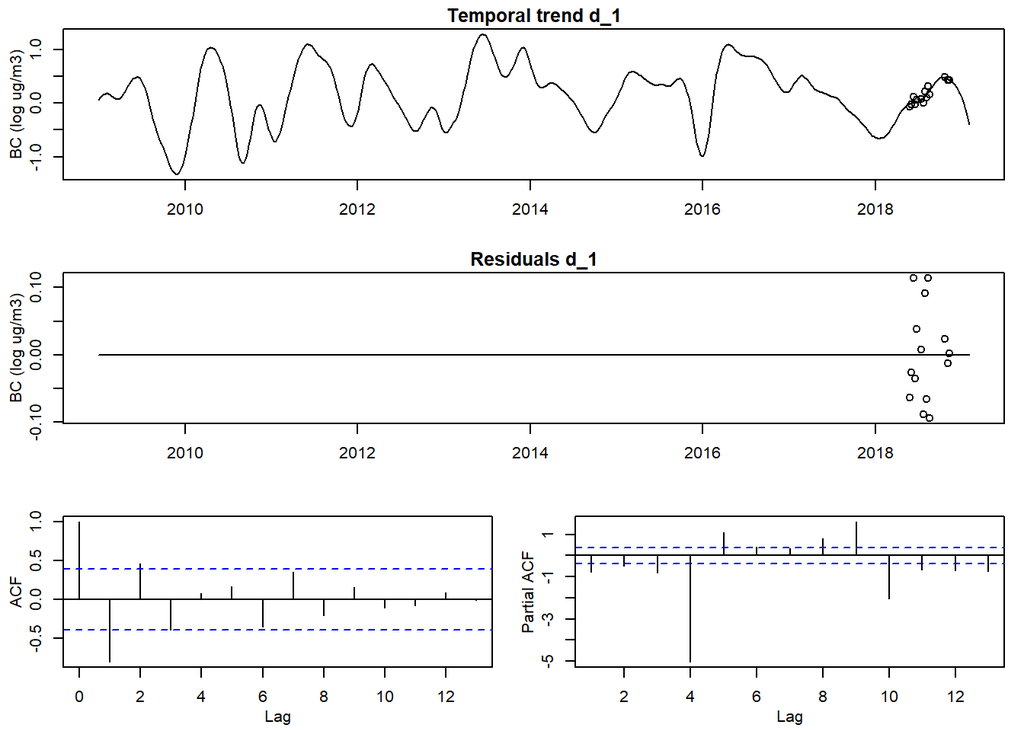

```r
par(mar=c(3.3,3.3,1.5,1), mgp=c(2,1,0))
layout(matrix(c(1,1,2,2,3,4), 3, 2, byrow=TRUE))
plot(denver.data2.3, "obs", ID="d_1", xlab="", ylab="BC (log ug/m3)",
     main="Temporal trend d_1")
plot(denver.data2.3, "res", ID="d_1", xlab="", ylab="BC (log ug/m3)")
plot(denver.data2.3, "acf", ID="d_1")
plot(denver.data2.3, "pacf", ID="d_1")
```

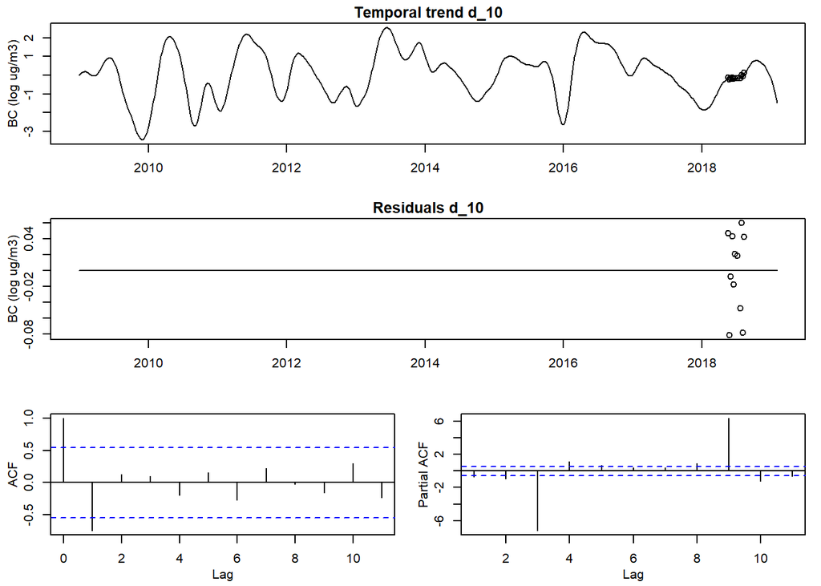

```r
par(mar=c(3.3,3.3,1.5,1), mgp=c(2,1,0))
layout(matrix(c(1,1,2,2,3,4), 3, 2, byrow=TRUE))
plot(denver.data2.3, "obs", ID="d_10", xlab="", ylab="BC (log ug/m3)",
     main="Temporal trend d_10")
plot(denver.data2.3, "res", ID="d_10", xlab="", ylab="BC (log ug/m3)")
plot(denver.data2.3, "acf", ID="d_10")
plot(denver.data2.3, "pacf", ID="d_10")
```

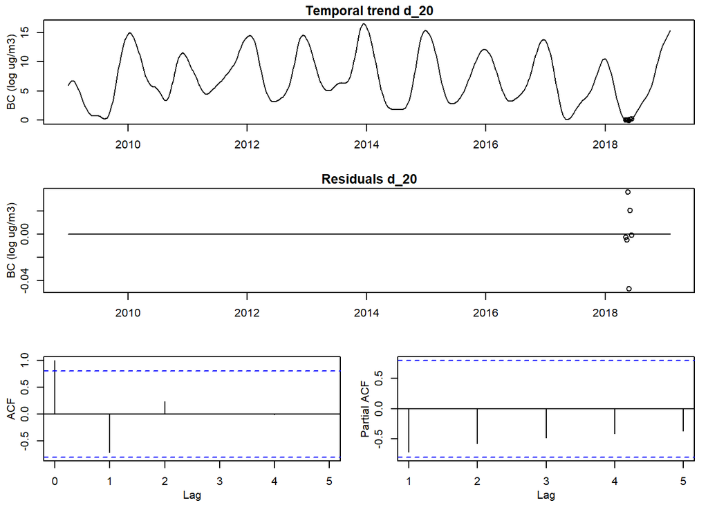

```r
par(mar=c(3.3,3.3,1.5,1), mgp=c(2,1,0))
layout(matrix(c(1,1,2,2,3,4), 3, 2, byrow=TRUE))
plot(denver.data2.3, "obs", ID="d_20", xlab="", ylab="BC (log ug/m3)",
     main="Temporal trend d_20")
plot(denver.data2.3, "res", ID="d_20", xlab="", ylab="BC (log ug/m3)")
plot(denver.data2.3, "acf", ID="d_20")
plot(denver.data2.3, "pacf", ID="d_20")
```

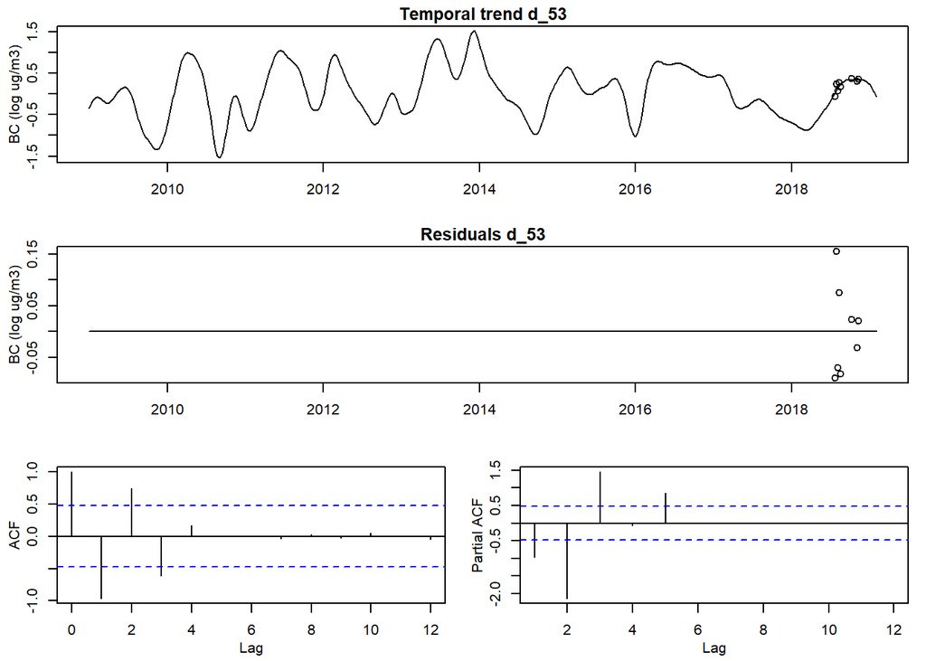

```r
par(mar=c(3.3,3.3,1.5,1), mgp=c(2,1,0))
layout(matrix(c(1,1,2,2,3,4), 3, 2, byrow=TRUE))
plot(denver.data2.3, "obs", ID="d_53", xlab="", ylab="BC (log ug/m3)",
     main="Temporal trend d_53")
plot(denver.data2.3, "res", ID="d_53", xlab="", ylab="BC (log ug/m3)")
plot(denver.data2.3, "acf", ID="d_53")
plot(denver.data2.3, "pacf", ID="d_53")
```

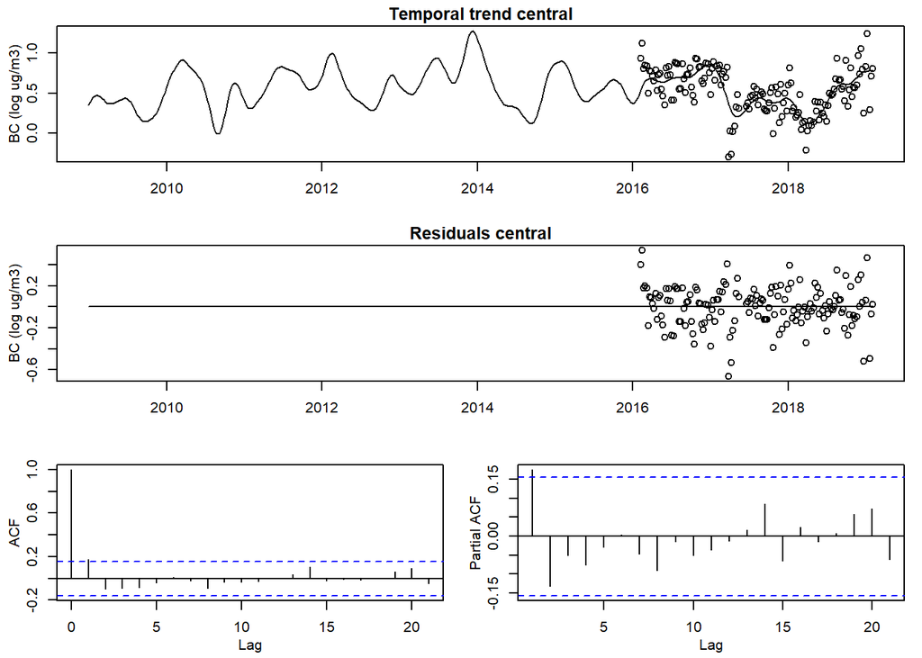

```r
par(mar=c(3.3,3.3,1.5,1), mgp=c(2,1,0))
layout(matrix(c(1,1,2,2,3,4), 3, 2, byrow=TRUE))
plot(denver.data2.3, "obs", ID="central", xlab="", ylab="BC (log ug/m3)",
     main="Temporal trend central")
plot(denver.data2.3, "res", ID="central", xlab="", ylab="BC (log ug/m3)")
plot(denver.data2.3, "acf", ID="central")
plot(denver.data2.3, "pacf", ID="central")
```

# 3 Testing each possible model

Building on the results of the previous modeling efforts, I’m going to update “Model 4.2”, which used an ’`exp` covariance structure for the error term and `iid` for the beta fields.

## 3.1 Model A: 1 temporal trend (basis) function

### 3.1.1 Create the model object

For this version of the model, use `iid` for `cov.beta` (beta, beta1) and `exp` for `cov.nu` (error). Here we can specify different LUR formluae. The length of the LUR list should be number of basis functions + 1.

```r
denver.data.A <- denver.data2.1
names(denver.data.A$covars)
```

```
##  [1] "ID"                  "lon"                 "lat"
##  [4] "impervious_2500"     "open_2500"           "low_int_100"
##  [7] "med_int_50"          "high_int_50"         "high_int_100"
## [10] "ag_250"              "pop_den_50"          "dist_m_compost"
## [13] "dist_m_military"     "len_m_highways_2500" "aadt_100"
## [16] "aadt_2500"           "x"                   "y"
## [19] "type"
```

```r
LUR.A <- list(covar_fun, covar_fun)

cov.beta.A <-  list(covf = c("iid", "iid"), nugget = T)
cov.nu.A <- list(covf = "exp", nugget = T, random.effect = FALSE)
locations.A <- list(coords = c("x","y"), long.lat = c("lon","lat"), others= "type")

denver.model.A <- createSTmodel(denver.data.A, LUR = LUR.A,
                                ST = c("bc_st_no2", "bc_st_smk"),
                                cov.beta = cov.beta.A, cov.nu = cov.nu.A,
                                locations = locations.A)
```

```
## No trend $trend.fnc object detected, STdata probably from old version of the package.
## $trend.fnc has been added based on spline fit to elements in STmodel$trend.
```

```r
denver.model.A
```

```
## STmodel-object with:
##  No. locations: 61 (observed: 61)
##  No. time points: 526 (observed: 152)
##  No. obs: 767
##
## Trend with 1 basis function(s):
## [1] "V1"
## with dates:
##  2008-12-29 to 2019-02-04
##
## Models for the beta-fields are:
## $const
## ~~impervious_2500 + open_2500 + low_int_100 + med_int_50 + high_int_50 +
##     high_int_100 + ag_250 + pop_den_50 + dist_m_compost + dist_m_military +
##     len_m_highways_2500 + aadt_100 + aadt_2500
##
## $V1
## ~~impervious_2500 + open_2500 + low_int_100 + med_int_50 + high_int_50 +
##     high_int_100 + ag_250 + pop_den_50 + dist_m_compost + dist_m_military +
##     len_m_highways_2500 + aadt_100 + aadt_2500
##
## 2 spatio-temporal covariate(s):
## [1] "bc_st_no2" "bc_st_smk"
##
## Covariance model for the beta-field(s):
##  Covariance type(s): iid, iid
##  Nugget: Yes, Yes
## Covariance model for the nu-field(s):
##  Covariance type: exp
##  Nugget: ~1
##  Random effect: No
## All sites:
## central    dist
##       1      60
## Observed:
## central    dist
##       1      60
##
## For central:
##   Number of obs: 152
##   Dates: 2016-02-08 to 2019-02-04
## For dist:
##   Number of obs: 615
##   Dates: 2018-05-07 to 2018-11-12
```

### 3.1.2 Estimate model parameters

- nugget values can range from -1 to -6
- range values can range from 0 to 4
- try starting values where the sill and nugget are the same (e.g., both 0) and where they are very different (e.g., 0 and -5)
- make sure the starting values are pretty different

```r
names <- loglikeSTnames(denver.model.A, all=FALSE)
names
```

```
## [1] "log.nugget.const.iid"          "log.nugget.V1.iid"
## [3] "nu.log.range.exp"              "nu.log.sill.exp"
## [5] "nu.log.nugget.(Intercept).exp"
```

```r
# x.init.A <- cbind(c(0, 0, 0, 0, 0),
#                   c(-1, -1, 0, -1, -1),
#                   c(-1, -1, 0, -5, -1),
#                   c(-5, -5, 0, -1, -5),
#                   c(-5, -5, 0, -5, -5),
#                   c(-1, -1, 2, -1, -1),
#                   c(-1, -1, 2, -5, -1),
#                   c(-5, -5, 2, -1, -5),
#                   c(-5, -5, 2, -5, -5),
#                   c(-1, -1, 4, -1, -1),
#                   c(-1, -1, 4, -5, -1),
#                   c(-5, -5, 4, -1, -5),
#                   c(-5, -5, 4, -5, -5))

x.init.A <- cbind(c(0, 0, 0, 0, 0),
                  c(-1, -1, 4, -5, -1),
                  c(-5, -5, 4, -1, -5),
                  c(-1, -1, 8, -5, -1),
                  c(-5, -5, 8, -1, -5),
                  c(-1, -1, 12, -5, -1),
                  c(-5, -5, 12, -1, -5))

rownames(x.init.A) <- loglikeSTnames(denver.model.A, all=FALSE)
x.init.A
```

```
##                               [,1] [,2] [,3] [,4] [,5] [,6] [,7]
## log.nugget.const.iid             0   -1   -5   -1   -5   -1   -5
## log.nugget.V1.iid                0   -1   -5   -1   -5   -1   -5
## nu.log.range.exp                 0    4    4    8    8   12   12
## nu.log.sill.exp                  0   -5   -1   -5   -1   -5   -1
## nu.log.nugget.(Intercept).exp    0   -1   -5   -1   -5   -1   -5
```

```r
#' Difference from tutorial: use Josh Keller's version of the function
source(here::here("Code", "functions_model.R"))
est.denver.model.A <- estimate.STmodel(denver.model.A, x.init.A)
```

```
## Optimisation using starting value 1/7
```

```
## N = 5, M = 5 machine precision = 2.22045e-16
## At X0, 0 variables are exactly at the bounds
## At iterate     0  f=       353.66  |proj g|=           15
## At iterate    10  f =        -1110  |proj g|=       0.49904
##
## iterations 17
## function evaluations 32
## segments explored during Cauchy searches 21
## BFGS updates skipped 0
## active bounds at final generalized Cauchy point 1
## norm of the final projected gradient 0.0381438
## final function value -1110.01
##
## F = -1110.01
## l(0) > u(0).  No feasible solutionfinal  value -1110.006041
```

```
## Optimisation using starting value 2/7
```

```
## N = 5, M = 5 machine precision = 2.22045e-16
## At X0, 0 variables are exactly at the bounds
## At iterate     0  f=      -245.23  |proj g|=           14
## At iterate    10  f =        -1109  |proj g|=      0.082005
## At iterate    20  f =      -1109.5  |proj g|=        3.6434
## At iterate    30  f =        -1110  |proj g|=      0.029155
## ys=-3.601e+00  -gs= 1.162e-01, BFGS update SKIPPED
## At iterate    40  f =      -1365.3  |proj g|=      0.034621
## At iterate    50  f =      -1391.8  |proj g|=        9.9469
## At iterate    60  f =      -1414.3  |proj g|=     0.0015621
##
## iterations 61
## function evaluations 95
## segments explored during Cauchy searches 64
## BFGS updates skipped 1
## active bounds at final generalized Cauchy point 1
## norm of the final projected gradient 0.000575318
## final function value -1414.29
##
## F = -1414.29
```

```
## Optimisation using starting value 3/7
```

```
## N = 5, M = 5 machine precision = 2.22045e-16
## At X0, 0 variables are exactly at the bounds
## At iterate     0  f=       -353.4  |proj g|=           14
## At iterate    10  f =      -1109.4  |proj g|=       0.57611
## At iterate    20  f =        -1110  |proj g|=       0.14413
## At iterate    30  f =      -1347.1  |proj g|=        12.289
##
## iterations 34
## function evaluations 57
## segments explored during Cauchy searches 35
## BFGS updates skipped 0
## active bounds at final generalized Cauchy point 1
## norm of the final projected gradient 0.0554287
## final function value -1365.32
##
## F = -1365.32
```

```
## Optimisation using starting value 4/7
```

```
## N = 5, M = 5 machine precision = 2.22045e-16
## At X0, 0 variables are exactly at the bounds
## At iterate     0  f=      -245.33  |proj g|=           14
## At iterate    10  f =      -1365.3  |proj g|=        1.1956
## At iterate    20  f =      -1414.2  |proj g|=        2.4316
##
## iterations 28
## function evaluations 51
## segments explored during Cauchy searches 31
## BFGS updates skipped 0
## active bounds at final generalized Cauchy point 1
## norm of the final projected gradient 0.00178284
## final function value -1414.29
##
## F = -1414.29
## l(0) > u(0).  No feasible solutionfinal  value -1414.288360
```

```
## Optimisation using starting value 5/7
```

```
## N = 5, M = 5 machine precision = 2.22045e-16
## At X0, 0 variables are exactly at the bounds
## At iterate     0  f=      -418.16  |proj g|=           14
## At iterate    10  f =      -1414.3  |proj g|=        3.3563
##
## iterations 17
## function evaluations 37
## segments explored during Cauchy searches 19
## BFGS updates skipped 0
## active bounds at final generalized Cauchy point 1
## norm of the final projected gradient 0.101879
## final function value -1414.29
##
## F = -1414.29
## l(0) > u(0).  No feasible solutionfinal  value -1414.288392
```

```
## Optimisation using starting value 6/7
```

```
## N = 5, M = 5 machine precision = 2.22045e-16
## At X0, 0 variables are exactly at the bounds
## At iterate     0  f=      -247.16  |proj g|=           14
## At iterate    10  f =      -1414.3  |proj g|=       0.42058
##
## iterations 16
## function evaluations 35
## segments explored during Cauchy searches 19
## BFGS updates skipped 0
## active bounds at final generalized Cauchy point 1
## norm of the final projected gradient 0.0223554
## final function value -1414.29
##
## F = -1414.29
```

```
## Optimisation using starting value 7/7
```

```
## N = 5, M = 5 machine precision = 2.22045e-16
## At X0, 0 variables are exactly at the bounds
## At iterate     0  f=      -1061.5  |proj g|=           14
## At iterate    10  f =      -1414.3  |proj g|=       0.12163
##
## iterations 16
## function evaluations 29
## segments explored during Cauchy searches 20
## BFGS updates skipped 0
## active bounds at final generalized Cauchy point 1
## norm of the final projected gradient 0.00398996
## final function value -1414.29
##
## F = -1414.29
## l(0) > u(0).  No feasible solutionfinal  value -1414.288361
```

```r
print(est.denver.model.A)
```

```
## Optimisation for STmodel with 7 starting points.
##   Results: 5 converged, 2 not converged, 0 failed.
##   Best result for starting point 5, optimisation has converged
##
## No fixed parameters.
##
## Estimated parameters for all starting point(s):
##                                          [,1]         [,2]          [,3]
## gamma.bc_st_no2                   0.017159075  0.020108616   0.013613244
## gamma.bc_st_smk                   0.048034575  0.018421620   0.016679427
## alpha.const.(Intercept)          -0.026079167 -0.165476818  -0.016512228
## alpha.const.impervious_2500       0.021126811  0.006682435   0.025250174
## alpha.const.open_2500            -0.033584203 -0.040708935  -0.024012024
## alpha.const.low_int_100          -0.012781677 -0.008026649   0.001265209
## alpha.const.med_int_50           -0.005722414  0.003612736   0.006171180
## alpha.const.high_int_50           0.006154303  0.025922543   0.018084309
## alpha.const.high_int_100          0.024168595 -0.012831963  -0.001624891
## alpha.const.ag_250                0.020495284  0.011248606   0.017025406
## alpha.const.pop_den_50            0.004769213  0.001212213  -0.004232581
## alpha.const.dist_m_compost       -0.002245841 -0.015395229  -0.010965454
## alpha.const.dist_m_military       0.016006440 -0.001947981  -0.001742660
## alpha.const.len_m_highways_2500  -0.003033371 -0.007889455  -0.003015981
## alpha.const.aadt_100             -0.005384386  0.025113845   0.030380766
## alpha.const.aadt_2500             0.011897614  0.007609687   0.001707342
## alpha.V1.(Intercept)              0.189963596  0.065438469   0.105808541
## alpha.V1.impervious_2500          0.023412686  0.012659576   0.028515540
## alpha.V1.open_2500                0.012698444 -0.004740598   0.019309102
## alpha.V1.low_int_100             -0.015532719 -0.017505298  -0.004595827
## alpha.V1.med_int_50              -0.003005167  0.004172486   0.006129895
## alpha.V1.high_int_50             -0.029074753 -0.003519432  -0.012263912
## alpha.V1.high_int_100             0.056007044  0.010261676   0.028397770
## alpha.V1.ag_250                   0.017196392 -0.005653466   0.014810980
## alpha.V1.pop_den_50               0.025204122  0.011093626   0.015360954
## alpha.V1.dist_m_compost           0.030998984  0.010974505   0.021159638
## alpha.V1.dist_m_military          0.023117534  0.002573222   0.007607086
## alpha.V1.len_m_highways_2500      0.003180666 -0.008832584  -0.001334721
## alpha.V1.aadt_100                -0.064433209 -0.038252786  -0.027496992
## alpha.V1.aadt_2500                0.000927592 -0.002731588  -0.004881494
## log.nugget.const.iid            -14.562514164 -6.521995567 -14.436273807
## log.nugget.V1.iid               -15.000000000 -6.448991637 -14.997095455
```

[output cut: 63 more lines]

```
## alpha.V1.ag_250                 -0.005652977
## alpha.V1.pop_den_50              0.011093005
## alpha.V1.dist_m_compost          0.010974905
## alpha.V1.dist_m_military         0.002573228
## alpha.V1.len_m_highways_2500    -0.008832753
## alpha.V1.aadt_100               -0.038251307
## alpha.V1.aadt_2500              -0.002731496
## log.nugget.const.iid            -6.521791296
## log.nugget.V1.iid               -6.449246235
## nu.log.range.exp                15.000000000
## nu.log.sill.exp                 -2.934383813
## nu.log.nugget.(Intercept).exp   -5.539785951
##
## Function value(s):
## [1] 1110.006 1414.288 1365.319 1414.288 1414.288 1414.288 1414.288
```

### 3.1.3 Cross-validation

Define the CV groups

```r
set.seed(123)

unique(colnames(bc_obs2))
```

```
##  [1] "d_1"     "d_2"     "d_3"     "d_4"     "d_5"     "d_6"     "d_7"
##  [8] "d_8"     "d_9"     "d_10"    "d_11"    "d_12"    "d_13"    "d_14"
## [15] "d_15"    "d_16"    "d_17"    "d_18"    "d_19"    "d_20"    "d_21"
## [22] "d_22"    "d_23"    "d_24"    "d_25"    "d_26"    "d_27"    "d_28"
## [29] "d_29"    "d_30"    "d_31"    "d_32"    "d_33"    "d_34"    "d_35"
## [36] "d_36"    "d_37"    "d_38"    "d_39"    "d_40"    "d_41"    "d_42"
## [43] "d_43"    "d_44"    "d_45"    "d_46"    "d_47"    "d_48"    "d_49"
## [50] "d_50"    "d_51"    "d_52"    "d_53"    "d_54"    "d_55"    "d_56"
## [57] "d_57"    "d_58"    "d_59"    "d_60"    "central"
```

```r
Ind.cv.A <- createCV(denver.model.A, groups = 10, #min.dist = .1,
                     subset = paste0("d_", c(1:60)))

ID.cv.A <- sapply(split(denver.model.A$obs$ID, Ind.cv.A), unique)
print(sapply(ID.cv.A, length))
```

```
##  0  1  2  3  4  5  6  7  8  9 10
##  1  6  6  6  6  6  6  6  6  6  6
```

```r
table(Ind.cv.A)
```

```
## Ind.cv.A
##   0   1   2   3   4   5   6   7   8   9  10
## 152  71  53  58  67  66  52  66  61  61  60
```

```r
I.col.A <- apply(sapply(ID.cv.A, function(x) denver.model.A$locations$ID%in% x), 1,
                       function(x) if(sum(x)==1) which(x) else 0)
names(I.col.A) <- denver.model.A$locations$ID
print(I.col.A)
```

```
##     d_1     d_2     d_3     d_4     d_5     d_6     d_7     d_8     d_9    d_10
##       6       9      11       4      11       2       8      11       9       7
##    d_11    d_12    d_13    d_14    d_15    d_16    d_17    d_18    d_19    d_20
##       2       9      10       2      10      11       6      11       6      10
##    d_21    d_22    d_23    d_24    d_25    d_26    d_27    d_28    d_29    d_30
##       3       3       8       8       3       5      10       5       4       5
##    d_31    d_32    d_33    d_34    d_35    d_36    d_37    d_38    d_39    d_40
##       4       7       2       7       8       6       2       5       5       4
##    d_41    d_42    d_43    d_44    d_45    d_46    d_47    d_48    d_49    d_50
##       7       5       9       4       3       6       8      11       4       9
##    d_51    d_52    d_53    d_54    d_55    d_56    d_57    d_58    d_59    d_60
##       9       8      10       2       6       3       3       7       7      10
## central
##       1
```

```r
par(mfrow=c(1,1))
plot(denver.model.A$locations$long,
     denver.model.A$locations$lat,
     pch=23+floor(I.col.A/max(I.col.A)+.5), bg=I.col.A,
     xlab="Longitude", ylab="Latitude")
```

[output not shown]

```r
map("county", "colorado", col="#FFFF0055",fill=TRUE, add=TRUE)
```

ID starting conditions using previous model without CV:

```r
x.init.A.cv <- coef(est.denver.model.A, pars="cov")[,c("par","init")]
x.init.A.cv
```

|  | par | init |
| --- | --- | --- |
| log.nugget.const.iid | -6.521647 | -5 |
| log.nugget.V1.iid | -6.448922 | -5 |
| nu.log.range.exp | 15.000000 | 8 |
| nu.log.sill.exp | -2.933948 | -1 |
| nu.log.nugget.(Intercept).exp | -5.539408 | -5 |

Run the model with cross validation

```r
est.denver.A.cv <- estimateCV(denver.model.A, x.init.A.cv, Ind.cv.A)
```

```
## Estimation of CV-set 1/10
```

```
## Optimisation using starting value 1/2
```

```
## N = 5, M = 5 machine precision = 2.22045e-16
## At X0, 1 variables are exactly at the bounds
## At iterate     0  f=        -1266  |proj g|=       1.9298
## At iterate    10  f =      -1266.1  |proj g|=    8.8466e-05
##
## iterations 10
## function evaluations 15
## segments explored during Cauchy searches 10
## BFGS updates skipped 0
## active bounds at final generalized Cauchy point 1
## norm of the final projected gradient 8.84661e-05
## final function value -1266.11
##
## F = -1266.11
```

```
## Optimisation using starting value 2/2
```

```
## N = 5, M = 5 machine precision = 2.22045e-16
## At X0, 0 variables are exactly at the bounds
## At iterate     0  f=      -364.01  |proj g|=           14
## At iterate    10  f =        -1266  |proj g|=        3.1773
##
## iterations 14
## function evaluations 16
## segments explored during Cauchy searches 16
## BFGS updates skipped 0
## active bounds at final generalized Cauchy point 1
## norm of the final projected gradient 0.0246248
## final function value -1266.11
##
## F = -1266.11
```

```
## Estimation of CV-set 2/10
```

```
## Optimisation using starting value 1/2
```

```
## N = 5, M = 5 machine precision = 2.22045e-16
## At X0, 1 variables are exactly at the bounds
## At iterate     0  f=      -1292.1  |proj g|=       9.9391
##
## iterations 9
## function evaluations 24
## segments explored during Cauchy searches 9
## BFGS updates skipped 0
## active bounds at final generalized Cauchy point 1
## norm of the final projected gradient 0.0829093
## final function value -1292.38
##
## F = -1292.38
## l(0) > u(0).  No feasible solutionfinal  value -1292.380859
```

```
## Optimisation using starting value 2/2
```

```
## N = 5, M = 5 machine precision = 2.22045e-16
## At X0, 0 variables are exactly at the bounds
## At iterate     0  f=       -387.6  |proj g|=           14
## At iterate    10  f =      -1292.4  |proj g|=       0.82811
##
## iterations 16
## function evaluations 35
## segments explored during Cauchy searches 18
## BFGS updates skipped 0
## active bounds at final generalized Cauchy point 1
## norm of the final projected gradient 0.0328991
## final function value -1292.38
##
## F = -1292.38
## l(0) > u(0).  No feasible solutionfinal  value -1292.380878
```

```
## Estimation of CV-set 3/10
```

```
## Optimisation using starting value 1/2
```

```
## N = 5, M = 5 machine precision = 2.22045e-16
## At X0, 1 variables are exactly at the bounds
## At iterate     0  f=      -1282.2  |proj g|=       10.227
## Bad direction in the line search;
##    refresh the lbfgs memory and restart the iteration.
## Line search cannot locate an adequate point after 20 function
## and gradient evaluations
```

```
## Optimisation using starting value 2/2
```

```
## N = 5, M = 5 machine precision = 2.22045e-16
## At X0, 0 variables are exactly at the bounds
## At iterate     0  f=      -387.31  |proj g|=           14
## At iterate    10  f =      -1282.4  |proj g|=        1.3308
## At iterate    20  f =      -1282.5  |proj g|=      0.085298
##
## iterations 20
## function evaluations 44
## segments explored during Cauchy searches 22
## BFGS updates skipped 0
## active bounds at final generalized Cauchy point 1
## norm of the final projected gradient 0.0852979
## final function value -1282.5
##
## F = -1282.5
## l(0) > u(0).  No feasible solutionfinal  value -1282.500226
```

```
## Estimation of CV-set 4/10
```

```
## Optimisation using starting value 1/2
```

```
## N = 5, M = 5 machine precision = 2.22045e-16
## At X0, 1 variables are exactly at the bounds
## At iterate     0  f=        -1278  |proj g|=        3.495
##
## iterations 9
## function evaluations 16
## segments explored during Cauchy searches 9
## BFGS updates skipped 0
## active bounds at final generalized Cauchy point 1
## norm of the final projected gradient 0.0271734
## final function value -1278.18
##
## F = -1278.18
```

```
## Optimisation using starting value 2/2
```

```
## N = 5, M = 5 machine precision = 2.22045e-16
## At X0, 0 variables are exactly at the bounds
## At iterate     0  f=      -374.32  |proj g|=           14
## At iterate    10  f =      -1277.9  |proj g|=        3.4085
## At iterate    20  f =      -1278.2  |proj g|=      0.010395
##
## iterations 23
## function evaluations 26
## segments explored during Cauchy searches 25
## BFGS updates skipped 0
## active bounds at final generalized Cauchy point 1
## norm of the final projected gradient 0.009125
## final function value -1278.18
##
## F = -1278.18
```

```
## Estimation of CV-set 5/10
```

```
## Optimisation using starting value 1/2
```

```
## N = 5, M = 5 machine precision = 2.22045e-16
## At X0, 1 variables are exactly at the bounds
## At iterate     0  f=      -1292.6  |proj g|=       9.4606
## At iterate    10  f =      -1293.2  |proj g|=      0.024509
##
## iterations 12
## function evaluations 17
## segments explored during Cauchy searches 13
## BFGS updates skipped 0
## active bounds at final generalized Cauchy point 1
## norm of the final projected gradient 0.000583488
## final function value -1293.24
##
## F = -1293.24
```

```
## Optimisation using starting value 2/2
```

```
## N = 5, M = 5 machine precision = 2.22045e-16
## At X0, 0 variables are exactly at the bounds
## At iterate     0  f=      -376.47  |proj g|=           14
## At iterate    10  f =        -1293  |proj g|=        1.6228
## Bad direction in the line search;
##    refresh the lbfgs memory and restart the iteration.
## Line search cannot locate an adequate point after 20 function
## and gradient evaluations
```

```
## Estimation of CV-set 6/10
```

```
## Optimisation using starting value 1/2
```

```
## N = 5, M = 5 machine precision = 2.22045e-16
## At X0, 1 variables are exactly at the bounds
## At iterate     0  f=      -1292.3  |proj g|=       12.681
##
## iterations 8
## function evaluations 28
## segments explored during Cauchy searches 8
## BFGS updates skipped 0
## active bounds at final generalized Cauchy point 1
## norm of the final projected gradient 0.0123962
## final function value -1292.9
##
## F = -1292.9
## l(0) > u(0).  No feasible solutionfinal  value -1292.896861
```

```
## Optimisation using starting value 2/2
```

```
## N = 5, M = 5 machine precision = 2.22045e-16
## At X0, 0 variables are exactly at the bounds
## At iterate     0  f=      -382.53  |proj g|=           14
## At iterate    10  f =      -1292.7  |proj g|=        3.0701
## At iterate    20  f =      -1292.9  |proj g|=      0.031243
##
## iterations 21
## function evaluations 25
## segments explored during Cauchy searches 23
## BFGS updates skipped 0
## active bounds at final generalized Cauchy point 1
## norm of the final projected gradient 0.0215915
## final function value -1292.9
##
## F = -1292.9
```

```
## Estimation of CV-set 7/10
```

```
## Optimisation using starting value 1/2
```

```
## N = 5, M = 5 machine precision = 2.22045e-16
## At X0, 1 variables are exactly at the bounds
## At iterate     0  f=      -1272.8  |proj g|=       1.6442
## At iterate    10  f =      -1272.9  |proj g|=      0.013612
##
## iterations 10
## function evaluations 21
## segments explored during Cauchy searches 10
## BFGS updates skipped 0
## active bounds at final generalized Cauchy point 1
## norm of the final projected gradient 0.0136117
## final function value -1272.93
##
## F = -1272.93
```

```
## Optimisation using starting value 2/2
```

```
## N = 5, M = 5 machine precision = 2.22045e-16
## At X0, 0 variables are exactly at the bounds
## At iterate     0  f=      -371.38  |proj g|=           14
## At iterate    10  f =      -1272.3  |proj g|=        5.6762
## At iterate    20  f =      -1272.9  |proj g|=      0.001177
##
## iterations 21
## function evaluations 27
## segments explored during Cauchy searches 23
## BFGS updates skipped 0
## active bounds at final generalized Cauchy point 1
## norm of the final projected gradient 6.00701e-05
## final function value -1272.93
##
## F = -1272.93
```

```
## Estimation of CV-set 8/10
```

```
## Optimisation using starting value 1/2
```

```
## N = 5, M = 5 machine precision = 2.22045e-16
## At X0, 1 variables are exactly at the bounds
## At iterate     0  f=      -1278.1  |proj g|=       6.0284
## Bad direction in the line search;
##    refresh the lbfgs memory and restart the iteration.
##
## iterations 8
## function evaluations 42
## segments explored during Cauchy searches 9
## BFGS updates skipped 0
## active bounds at final generalized Cauchy point 1
## norm of the final projected gradient 0.0381396
## final function value -1278.2
##
## F = -1278.2
## l(0) > u(0).  No feasible solutionfinal  value -1278.195464
```

```
## Optimisation using starting value 2/2
```

```
## N = 5, M = 5 machine precision = 2.22045e-16
## At X0, 0 variables are exactly at the bounds
## At iterate     0  f=      -376.75  |proj g|=           14
## At iterate    10  f =        -1278  |proj g|=        3.3589
## At iterate    20  f =      -1278.2  |proj g|=      0.047017
##
## iterations 21
## function evaluations 24
## segments explored during Cauchy searches 23
## BFGS updates skipped 0
## active bounds at final generalized Cauchy point 1
## norm of the final projected gradient 0.0142523
## final function value -1278.2
##
## F = -1278.2
```

```
## Estimation of CV-set 9/10
```

```
## Optimisation using starting value 1/2
```

```
## N = 5, M = 5 machine precision = 2.22045e-16
## At X0, 1 variables are exactly at the bounds
## At iterate     0  f=      -1276.7  |proj g|=       9.5223
## At iterate    10  f =      -1277.4  |proj g|=      0.044489
##
## iterations 10
## function evaluations 16
## segments explored during Cauchy searches 10
## BFGS updates skipped 0
## active bounds at final generalized Cauchy point 1
## norm of the final projected gradient 0.0444893
## final function value -1277.39
##
## F = -1277.39
```

```
## Optimisation using starting value 2/2
```

```
## N = 5, M = 5 machine precision = 2.22045e-16
## At X0, 0 variables are exactly at the bounds
## At iterate     0  f=      -379.18  |proj g|=           14
## At iterate    10  f =      -1277.3  |proj g|=       0.82073
## Bad direction in the line search;
##    refresh the lbfgs memory and restart the iteration.
## Line search cannot locate an adequate point after 20 function
## and gradient evaluations
```

```
## Estimation of CV-set 10/10
```

```
## Optimisation using starting value 1/2
```

```
## N = 5, M = 5 machine precision = 2.22045e-16
## At X0, 1 variables are exactly at the bounds
## At iterate     0  f=      -1292.5  |proj g|=       2.5264
##
## iterations 9
## function evaluations 25
## segments explored during Cauchy searches 9
## BFGS updates skipped 0
## active bounds at final generalized Cauchy point 1
## norm of the final projected gradient 0.0235442
## final function value -1293.49
##
## F = -1293.49
## l(0) > u(0).  No feasible solutionfinal  value -1293.490885
```

```
## Optimisation using starting value 2/2
```

```
## N = 5, M = 5 machine precision = 2.22045e-16
## At X0, 0 variables are exactly at the bounds
## At iterate     0  f=      -385.26  |proj g|=           14
## At iterate    10  f =      -1293.4  |proj g|=        1.2627
## At iterate    20  f =      -1293.5  |proj g|=      0.036376
##
## iterations 20
## function evaluations 36
## segments explored during Cauchy searches 22
## BFGS updates skipped 0
## active bounds at final generalized Cauchy point 1
## norm of the final projected gradient 0.0363764
## final function value -1293.49
##
## F = -1293.49
## l(0) > u(0).  No feasible solutionfinal  value -1293.490895
```

```r
print(est.denver.A.cv)
```

```
## Cross-validation parameter estimation for STmodel
##   with 10 CV-groups and 2 starting points.
##   Results: 10 converged, 0 not converged.
##
## No fixed parameters.
##
## Estimated function values and convergence info:
##       value convergence conv eigen.min eigen.all.min
## 1  1266.108        TRUE TRUE  2.202849            NA
## 2  1292.381        TRUE TRUE  2.484300            NA
## 3  1282.500        TRUE TRUE  2.338465            NA
## 4  1278.176        TRUE TRUE  2.269758            NA
## 5  1293.240        TRUE TRUE  2.668786            NA
## 6  1292.897        TRUE TRUE  2.008710            NA
## 7  1272.928        TRUE TRUE  2.559352            NA
## 8  1278.195        TRUE TRUE  1.945873            NA
## 9  1277.392        TRUE TRUE  2.479194            NA
## 10 1293.491        TRUE TRUE  2.415255            NA
```

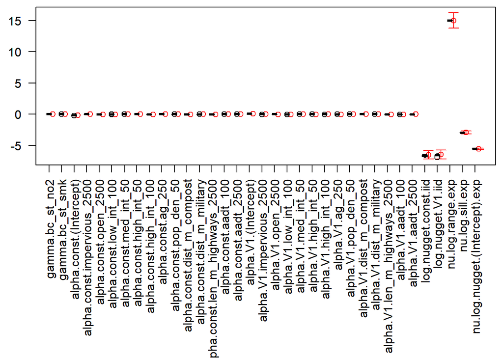

```r
par(mfrow=c(1,1), mar=c(13.5,2.5,.5,.5), las=2)
with(coef(est.denver.model.A, pars="all"),
     plotCI((1:length(par))+.3, par, uiw=1.96*sd,
             col=2, xlab="", xaxt="n", ylab=""))
boxplot(est.denver.A.cv, "all", boxwex=.4, col="grey", add=TRUE)
```

```r
#' Save the results as an .rdata object
save(denver.data.A, denver.model.A, est.denver.model.A, est.denver.A.cv,
     file = here::here("Results", "Denver_ST_Model_A.rdata"))
```

### 3.1.4 Prediction using the CV model

Making predictions using the CV model. Printing out the CV summary statistics as well

```r
pred.A.cv <- predictCV(denver.model.A, est.denver.A.cv, LTA = T)
pred.A.cv.log <- predictCV(denver.model.A, est.denver.A.cv,
                           LTA = T, transform="unbiased")

summary(pred.A.cv)
```

```
## Cross-validation predictions for STmodel with 10 CV-groups.
##   Predictions for 615 observations.
##   Temporal averages for 60 locations.
##
## RMSE:
##              EX.mu EX.mu.beta         EX
## obs     0.13778208 0.13778208 0.09371937
## average 0.08147343 0.08147343 0.06451359
##
## R2:
##             EX.mu EX.mu.beta        EX
## obs     0.5522174  0.5522174 0.7928235
## average 0.7115652  0.7115652 0.8191502
##
## Coverage of 95% prediction intervals:
##                EX
## obs     0.9186992
## average 0.9000000
```

```r
summary(pred.A.cv.log)
```

```
## Cross-validation predictions for STmodel with 10 CV-groups.
##   Predictions for 615 observations.
##   Temporal averages for 60 locations.
##
## RMSE:
##              EX.mu EX.mu.beta         EX    EX.pred
## obs     0.16367464 0.16367464 0.11025828 0.11029431
## average 0.09625127 0.09625127 0.07251374 0.07271513
##
## R2:
##             EX.mu EX.mu.beta        EX   EX.pred
## obs     0.5850302  0.5850302 0.8116889 0.8115657
## average 0.7522819  0.7522819 0.8594000 0.8586179
##
## Coverage of 95% prediction intervals:
##           EX.pred
## obs     0.9186992
## average 0.9000000
```

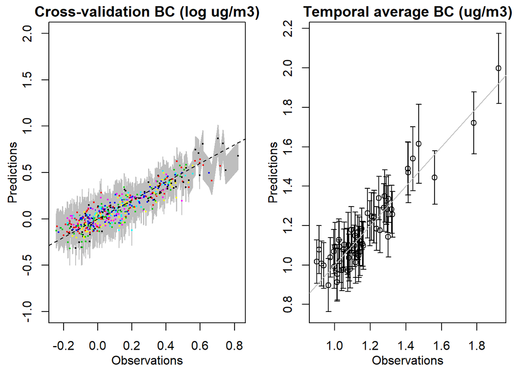

```r
par(mfrow=c(1,2), mar=c(3.3,3.3,1.5,1), mgp=c(2,1,0))
plot(pred.A.cv, "obs", ID="all", pch=c(19,NA), cex=.25, lty=c(NA,2),
     col=c("ID", "black", "grey"),
     ylim=c(-1,2),
     xlab="Observations", ylab="Predictions",
     main="Cross-validation BC (log ug/m3)")
with(pred.A.cv.log$pred.LTA, plotCI(obs, EX.pred, uiw=1.96*sqrt(VX.pred),
                                      xlab="Observations", ylab="Predictions",
                                      main="Temporal average BC (ug/m3)"))
abline(0, 1, col="grey")
```

```r
# jpeg(filename = here::here("Figs", "ST_CV_Obs_vs_Pred_BC_ModA.jpeg"),
#      width = 8, height = 4, units = "in", res = 500)
# par(mfrow=c(1,2), mar=c(3.3,3.3,1.5,1), mgp=c(2,1,0))
# plot(pred.A.cv, "obs", ID="all", pch=c(19,NA), cex=.25, lty=c(NA,2),
#      col=c("ID", "black", "grey"),
#      ylim=c(-1,2),
#      xlab="Observations", ylab="Predictions",
#      main="Cross-validation BC (log ug/m3)")
# with(pred.A.cv.log$pred.LTA, plotCI(obs, EX.pred, uiw=1.96*sqrt(VX.pred),
#                                       xlab="Observations", ylab="Predictions",
#                                       main="Temporal average BC (ug/m3)"))
# abline(0, 1, col="grey")
# dev.off()
```

### 3.1.5 Predictions for 2009-2019

What do the long-term predictions look like for this model? Predicting at the distributed (residential + community) sites

```r
x.A <- coef(est.denver.model.A, pars = "cov")$par
x.A
```

```
## [1] -6.521647 -6.448922 15.000000 -2.933948 -5.539408
```

```r
E.A <- predict(denver.model.A, est.denver.model.A, LTA = T,
               transform="unbiased", pred.var=FALSE)
print(E.A)
```

```
## Prediction for STmodel.
##
## Regression parameters:
##   0 Spatio-temporal covariate(s).
##   28 beta-fields regression parameters in x$pars.
##
## Regression parameters are assumed to be known and
##  prediction variances do NOT include
##  uncertainties in regression parameters.
##
## Prediction of beta-fields, (x$beta):
## List of 2
##  $ mu: num [1:61, 1:2] -0.1611 -0.1649 -0.0985 -0.1197 -0.1434 ...
##   ..- attr(*, "dimnames")=List of 2
##  $ EX: num [1:61, 1:2] -0.1607 -0.132 -0.1025 -0.0882 -0.1801 ...
##   ..- attr(*, "dimnames")=List of 2
##
## Predictions for log-Gaussian field of type: unbiased
##
## Predictions for 526 times at 61 locations.
## List of 5
##  $ EX.mu     : num [1:526, 1:61] 1.09 1.06 1.26 1.13 1.16 ...
##   ..- attr(*, "dimnames")=List of 2
##  $ EX.mu.beta: num [1:526, 1:61] 1.08 1.05 1.25 1.12 1.16 ...
##   ..- attr(*, "dimnames")=List of 2
##  $ EX        : num [1:526, 1:61] 1.11 1.08 1.29 1.15 1.19 ...
##   ..- attr(*, "dimnames")=List of 2
##  $ EX.pred   : num [1:526, 1:61] 1.11 1.08 1.29 1.16 1.19 ...
##   ..- attr(*, "dimnames")=List of 2
##  $ log.EX    : num [1:526, 1:61] 0.0779 0.0518 0.2259 0.1165 0.1464 ...
##   ..- attr(*, "dimnames")=List of 2
##
## Variances have been computed.
## List of 2
##  $ log.VX     : num [1:526, 1:61] 0.0538 0.0537 0.0536 0.0536 0.0535 ...
##   ..- attr(*, "dimnames")=List of 2
##  $ log.VX.pred: num [1:526, 1:61] 0.0577 0.0576 0.0575 0.0575 0.0574 ...
##   ..- attr(*, "dimnames")=List of 2
##
## Mean squared prediciton errors NOT been computed.
##
## 61 temporal averages have been compute.
## List of 1
##  $ LTA:'data.frame': 61 obs. of  4 variables:
```

```r
week_preds <- as.data.frame(E.A$EX) %>%
  mutate(week = as.Date(rownames(E.A$EX)),
         year = year(as.Date(rownames(E.A$EX))))

week_sites <- colnames(week_preds)[which(str_detect(colnames(week_preds), "d_"))]

box_preds <- week_preds %>%
  select(week, all_of(week_sites)) %>%
  #filter(week %in% week_weeks) %>%
  mutate(month = month(week),
         year = year(week)) %>%
  filter(year %in% c(2009:2019))

box_data <- box_preds %>%
  pivot_longer(-c(week, month, year), names_to = "location", values_to = "pred")
summary(box_data)
```

```
##       week                month             year        location
##  Min.   :2009-01-05   Min.   : 1.000   Min.   :2009   Length:31500
##  1st Qu.:2011-07-25   1st Qu.: 3.000   1st Qu.:2011   Class :character
##  Median :2014-01-27   Median : 6.000   Median :2014   Mode  :character
##  Mean   :2014-01-25   Mean   : 6.459   Mean   :2014
##  3rd Qu.:2016-08-01   3rd Qu.: 9.000   3rd Qu.:2016
##  Max.   :2019-02-04   Max.   :12.000   Max.   :2019
##
##       pred
##  Min.   :0.485
##  1st Qu.:1.124
##  Median :1.300
##  Mean   :1.370
##  3rd Qu.:1.569
##  Max.   :3.579
##  NA's   :480
```

```r
#' Box plot of weekly BC predicted at all distributed sites grouped by month
box_summary <- box_data %>%
  group_by(month) %>%
  summarize(median = median(pred, na.rm=T)) %>%
  arrange(desc(median))
box_summary
```

| month | median |
| --- | --- |
| 12 | 1.764464 |
| 1 | 1.651428 |
| 11 | 1.586207 |
| 2 | 1.528789 |
| 10 | 1.386621 |
| 9 | 1.268914 |
| 3 | 1.264307 |
| 8 | 1.242915 |
| 7 | 1.163838 |
| 6 | 1.120179 |

[output cut: 2 more lines]

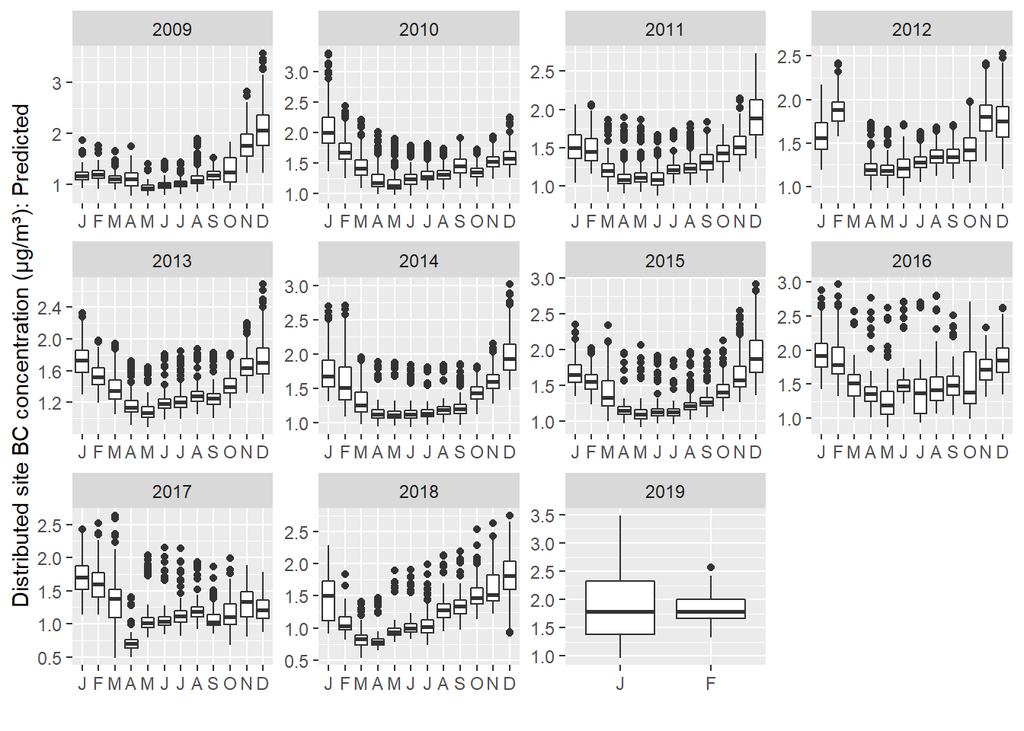

```r
pred_box_plot <- ggplot(box_data) +
  geom_boxplot(aes(x = as.factor(month), y = pred), #, color = as.factor(month)),
               show.legend = F) +
  #scale_color_viridis(name = "Month", discrete = T) +
  facet_wrap(. ~ year, scales = "free") +
  xlab("") + ylab("Distributed site BC concentration (\u03BCg/m\u00B3): Predicted") +
  # theme(axis.text.x = element_text(angle = 45, vjust = 1, hjust = 1)) +
  scale_x_discrete(labels = str_sub(month.name, 1, 1))
pred_box_plot
```

## 3.2 Model B: 2 temporal trend (basis) functions

### 3.2.1 Create the model object

For this version of the model, use `iid` for `cov.beta` (beta, beta1, beta2) and `exp` for `cov.nu` (error). Here we can specify different LUR formluae. The length of the LUR list should be number of basis functions + 1.

```r
denver.data.B <- denver.data2.2
names(denver.data.B$covars)
```

```
##  [1] "ID"                  "lon"                 "lat"
##  [4] "impervious_2500"     "open_2500"           "low_int_100"
##  [7] "med_int_50"          "high_int_50"         "high_int_100"
## [10] "ag_250"              "pop_den_50"          "dist_m_compost"
## [13] "dist_m_military"     "len_m_highways_2500" "aadt_100"
## [16] "aadt_2500"           "x"                   "y"
## [19] "type"
```

```r
LUR.B <- list(covar_fun, covar_fun, covar_fun)

cov.beta.B <-  list(covf = c("iid", "iid", "iid"), nugget = T)
cov.nu.B <- list(covf = "exp", nugget = T, random.effect = FALSE)
locations.B <- list(coords = c("x","y"), long.lat = c("lon","lat"), others= "type")

denver.model.B <- createSTmodel(denver.data.B, LUR = LUR.B,
                                ST = c("bc_st_no2", "bc_st_smk"),
                                cov.beta = cov.beta.B, cov.nu = cov.nu.B,
                                locations = locations.B)
```

```
## No trend $trend.fnc object detected, STdata probably from old version of the package.
## $trend.fnc has been added based on spline fit to elements in STmodel$trend.
```

```r
denver.model.B
```

```
## STmodel-object with:
##  No. locations: 61 (observed: 61)
##  No. time points: 526 (observed: 152)
##  No. obs: 767
##
## Trend with 2 basis function(s):
## [1] "V1" "V2"
## with dates:
##  2008-12-29 to 2019-02-04
##
## Models for the beta-fields are:
## $const
## ~~impervious_2500 + open_2500 + low_int_100 + med_int_50 + high_int_50 +
##     high_int_100 + ag_250 + pop_den_50 + dist_m_compost + dist_m_military +
##     len_m_highways_2500 + aadt_100 + aadt_2500
##
## $V1
## ~~impervious_2500 + open_2500 + low_int_100 + med_int_50 + high_int_50 +
##     high_int_100 + ag_250 + pop_den_50 + dist_m_compost + dist_m_military +
##     len_m_highways_2500 + aadt_100 + aadt_2500
##
## $V2
## ~~impervious_2500 + open_2500 + low_int_100 + med_int_50 + high_int_50 +
##     high_int_100 + ag_250 + pop_den_50 + dist_m_compost + dist_m_military +
##     len_m_highways_2500 + aadt_100 + aadt_2500
##
## 2 spatio-temporal covariate(s):
## [1] "bc_st_no2" "bc_st_smk"
##
## Covariance model for the beta-field(s):
##  Covariance type(s): iid, iid, iid
##  Nugget: Yes, Yes, Yes
## Covariance model for the nu-field(s):
##  Covariance type: exp
##  Nugget: ~1
##  Random effect: No
## All sites:
## central    dist
##       1      60
## Observed:
## central    dist
##       1      60
##
## For central:
##   Number of obs: 152
##   Dates: 2016-02-08 to 2019-02-04
## For dist:
##   Number of obs: 615
##   Dates: 2018-05-07 to 2018-11-12
```

### 3.2.2 Estimate model parameters

- nugget values can range from -1 to -6
- range values can range from 0 to 4
- try starting values where the sill and nugget are the same (e.g., both 0) and where they are very different (e.g., 0 and -5)
- make sure the starting values are pretty different

```r
names <- loglikeSTnames(denver.model.B, all=FALSE)
names
```

```
## [1] "log.nugget.const.iid"          "log.nugget.V1.iid"
## [3] "log.nugget.V2.iid"             "nu.log.range.exp"
## [5] "nu.log.sill.exp"               "nu.log.nugget.(Intercept).exp"
```

```r
# x.init.B <- cbind(c(0, 0, 0, 0, 0, 0),
#                   c(-1, -1, -1, 0, -1, -1),
#                   c(-1, -1, -1, 0, -5, -1),
#                   c(-5, -5, -5, 0, -1, -5),
#                   c(-5, -5, -5, 0, -5, -5),
#                   c(-1, -1, -1, 2, -1, -1),
#                   c(-1, -1, -1, 2, -5, -1),
#                   c(-5, -5, -5, 2, -1, -5),
#                   c(-5, -5, -5, 2, -5, -5),
#                   c(-1, -1, -1, 4, -1, -1),
#                   c(-1, -1, -1, 4, -5, -1),
#                   c(-5, -5, -5, 4, -1, -5),
#                   c(-5, -5, -5, 4, -5, -5))

x.init.B <- cbind(c(0, 0, 0, 0, 0, 0),
                  c(-10, -5, -5, 4, -3, -5),
                  c(-10, -5, -5, 4, -5, -5),
                  c(-10, -5, -5, 6, -3, -5),
                  c(-10, -5, -5, 6, -5, -5),
                  c(-10, -5, -5, 8, -3, -5),
                  c(-10, -5, -5, 8, -5, -5),
                  c(-10, -5, -5, 10, -3, -5),
                  c(-10, -5, -5, 10, -5, -5))

rownames(x.init.B) <- loglikeSTnames(denver.model.B, all=FALSE)
x.init.B
```

```
##                               [,1] [,2] [,3] [,4] [,5] [,6] [,7] [,8] [,9]
## log.nugget.const.iid             0  -10  -10  -10  -10  -10  -10  -10  -10
## log.nugget.V1.iid                0   -5   -5   -5   -5   -5   -5   -5   -5
## log.nugget.V2.iid                0   -5   -5   -5   -5   -5   -5   -5   -5
## nu.log.range.exp                 0    4    4    6    6    8    8   10   10
## nu.log.sill.exp                  0   -3   -5   -3   -5   -3   -5   -3   -5
## nu.log.nugget.(Intercept).exp    0   -5   -5   -5   -5   -5   -5   -5   -5
```

```r
#' Difference from tutorial: use Josh Keller's version of the function
source(here::here("Code", "functions_model.R"))
est.denver.model.B <- estimate.STmodel(denver.model.B, x.init.B)
```

```
## Optimisation using starting value 1/9
```

```
## N = 6, M = 5 machine precision = 2.22045e-16
## At X0, 0 variables are exactly at the bounds
## At iterate     0  f=       414.76  |proj g|=           15
## At iterate    10  f =      -1142.8  |proj g|=        1.0524
## At iterate    20  f =        -1143  |proj g|=      0.012402
## At iterate    30  f =        -1143  |proj g|=      0.033466
##
## iterations 30
## function evaluations 41
## segments explored during Cauchy searches 33
## BFGS updates skipped 0
## active bounds at final generalized Cauchy point 1
## norm of the final projected gradient 0.0334663
## final function value -1143.03
##
## F = -1143.03
```

```
## Optimisation using starting value 2/9
```

```
## N = 6, M = 5 machine precision = 2.22045e-16
## At X0, 0 variables are exactly at the bounds
## At iterate     0  f=         -916  |proj g|=           12
## At iterate    10  f =        -1142  |proj g|=        3.6473
## At iterate    20  f =      -1142.9  |proj g|=       0.18893
## At iterate    30  f =        -1143  |proj g|=        0.1047
## ys=-2.566e+01  -gs= 3.965e-01, BFGS update SKIPPED
## At iterate    40  f =      -1407.7  |proj g|=        5.0217
## At iterate    50  f =      -1453.6  |proj g|=        4.0342
## ys=-4.760e-03  -gs= 1.665e+00, BFGS update SKIPPED
## At iterate    60  f =      -1480.9  |proj g|=        5.2612
## At iterate    70  f =        -1482  |proj g|=        0.4288
##
## iterations 77
## function evaluations 114
## segments explored during Cauchy searches 80
## BFGS updates skipped 2
## active bounds at final generalized Cauchy point 2
## norm of the final projected gradient 0.00720707
## final function value -1481.99
##
## F = -1481.99
```

```
## Optimisation using starting value 3/9
```

```
## N = 6, M = 5 machine precision = 2.22045e-16
## At X0, 0 variables are exactly at the bounds
## At iterate     0  f=      -1052.4  |proj g|=           20
## At iterate    10  f =      -1142.8  |proj g|=         1.409
## At iterate    20  f =        -1143  |proj g|=       0.47793
## At iterate    30  f =      -1258.3  |proj g|=        19.489
## At iterate    40  f =      -1407.7  |proj g|=        0.2334
## At iterate    50  f =      -1453.2  |proj g|=       0.36727
## At iterate    60  f =      -1480.8  |proj g|=          5.07
## At iterate    70  f =      -1481.9  |proj g|=        1.5286
## At iterate    80  f =        -1482  |proj g|=       0.10289
##
## iterations 84
## function evaluations 121
## segments explored during Cauchy searches 88
## BFGS updates skipped 0
## active bounds at final generalized Cauchy point 2
## norm of the final projected gradient 0.0069995
## final function value -1481.99
##
## F = -1481.99
```

```
## Optimisation using starting value 4/9
```

```
## N = 6, M = 5 machine precision = 2.22045e-16
## At X0, 0 variables are exactly at the bounds
## At iterate     0  f=      -918.24  |proj g|=           12
## At iterate    10  f =      -1388.9  |proj g|=         7.531
## At iterate    20  f =      -1480.4  |proj g|=        1.9807
## At iterate    30  f =        -1482  |proj g|=       0.31852
##
## iterations 33
## function evaluations 47
## segments explored during Cauchy searches 36
## BFGS updates skipped 0
## active bounds at final generalized Cauchy point 2
## norm of the final projected gradient 0.0680216
## final function value -1481.99
##
## F = -1481.99
```

```
## Optimisation using starting value 5/9
```

```
## N = 6, M = 5 machine precision = 2.22045e-16
## At X0, 0 variables are exactly at the bounds
## At iterate     0  f=      -1054.1  |proj g|=           20
## ys=-5.987e+01  -gs= 5.156e+01, BFGS update SKIPPED
## At iterate    10  f =        -1375  |proj g|=        9.4581
## At iterate    20  f =      -1451.8  |proj g|=        8.4819
## At iterate    30  f =      -1456.4  |proj g|=       0.21024
## At iterate    40  f =      -1478.1  |proj g|=         3.575
## At iterate    50  f =        -1482  |proj g|=       0.55606
## Bad direction in the line search;
##    refresh the lbfgs memory and restart the iteration.
## Line search cannot locate an adequate point after 20 function
## and gradient evaluations
```

```
## Optimisation using starting value 6/9
```

```
## N = 6, M = 5 machine precision = 2.22045e-16
## At X0, 0 variables are exactly at the bounds
## At iterate     0  f=      -962.23  |proj g|=           12
## At iterate    10  f =      -1481.4  |proj g|=        4.0483
## At iterate    20  f =        -1482  |proj g|=       0.35105
## At iterate    30  f =        -1482  |proj g|=      0.017189
##
## iterations 30
## function evaluations 48
## segments explored during Cauchy searches 34
## BFGS updates skipped 0
## active bounds at final generalized Cauchy point 2
## norm of the final projected gradient 0.0171893
## final function value -1481.99
##
## F = -1481.99
## l(0) > u(0).  No feasible solutionfinal  value -1481.987389
```

```
## Optimisation using starting value 7/9
```

```
## N = 6, M = 5 machine precision = 2.22045e-16
## At X0, 0 variables are exactly at the bounds
## At iterate     0  f=      -1082.3  |proj g|=           20
## At iterate    10  f =      -1481.5  |proj g|=       0.46911
## At iterate    20  f =        -1482  |proj g|=       0.18524
##
## iterations 26
## function evaluations 32
## segments explored during Cauchy searches 31
## BFGS updates skipped 0
## active bounds at final generalized Cauchy point 2
## norm of the final projected gradient 0.0352616
## final function value -1481.99
##
## F = -1481.99
```

```
## Optimisation using starting value 8/9
```

```
## N = 6, M = 5 machine precision = 2.22045e-16
## At X0, 0 variables are exactly at the bounds
## At iterate     0  f=      -1142.8  |proj g|=           12
## At iterate    10  f =      -1481.4  |proj g|=        2.9926
## At iterate    20  f =      -1481.9  |proj g|=       0.68095
## At iterate    30  f =        -1482  |proj g|=     0.0048718
##
## iterations 31
## function evaluations 34
## segments explored during Cauchy searches 36
## BFGS updates skipped 0
## active bounds at final generalized Cauchy point 2
## norm of the final projected gradient 0.000418992
## final function value -1481.99
##
## F = -1481.99
```

```
## Optimisation using starting value 9/9
```

```
## N = 6, M = 5 machine precision = 2.22045e-16
## At X0, 0 variables are exactly at the bounds
## At iterate     0  f=      -1161.4  |proj g|=           20
## At iterate    10  f =      -1481.4  |proj g|=        1.3824
## At iterate    20  f =      -1481.9  |proj g|=        1.0681
##
## iterations 28
## function evaluations 39
## segments explored during Cauchy searches 32
## BFGS updates skipped 0
## active bounds at final generalized Cauchy point 2
## norm of the final projected gradient 0.00411945
## final function value -1481.99
##
## F = -1481.99
```

```r
print(est.denver.model.B)
```

```
## Optimisation for STmodel with 9 starting points.
##   Results: 7 converged, 2 not converged, 0 failed.
##   Best result for starting point 4, optimisation has converged
##
## No fixed parameters.
##
## Estimated parameters for all starting point(s):
##                                           [,1]           [,2]           [,3]
## gamma.bc_st_no2                   0.0084060000   0.0118509227   0.0118517099
## gamma.bc_st_smk                   0.0944387226   0.0804551381   0.0804538413
## alpha.const.(Intercept)           0.2131072392   0.0760377758   0.0760194506
## alpha.const.impervious_2500       0.0659506692   0.0841505400   0.0841498633
## alpha.const.open_2500             0.0302306538   0.0399399687   0.0399392857
## alpha.const.low_int_100           0.0172230348   0.0280120714   0.0280120100
## alpha.const.med_int_50           -0.0043474086  -0.0050297122  -0.0050300949
## alpha.const.high_int_50           0.0038255686   0.0085904503   0.0085907751
## alpha.const.high_int_100          0.0186840123   0.0025774880   0.0025769647
## alpha.const.ag_250                0.0037392395  -0.0024712906  -0.0024719790
## alpha.const.pop_den_50            0.0068615701  -0.0049599169  -0.0049598811
## alpha.const.dist_m_compost        0.0081520577  -0.0047331058  -0.0047336606
## alpha.const.dist_m_military       0.0229990643  -0.0005537265  -0.0005539082
## alpha.const.len_m_highways_2500  -0.0015247130   0.0014711583   0.0014713227
## alpha.const.aadt_100              0.0089076890   0.0279629128   0.0279624194
## alpha.const.aadt_2500             0.0004562851  -0.0161806884  -0.0161805384
## alpha.V1.(Intercept)              0.2589254985   0.0753348212   0.0753302146
## alpha.V1.impervious_2500          0.0349501956   0.0576875893   0.0576858132
## alpha.V1.open_2500                0.0416540173   0.0438548984   0.0438522936
## alpha.V1.low_int_100              0.0114689922   0.0152226544   0.0152220264
## alpha.V1.med_int_50              -0.0033804801   0.0019326025   0.0019325829
## alpha.V1.high_int_50             -0.0328954140  -0.0069764946  -0.0069753576
## alpha.V1.high_int_100             0.0822691183   0.0355624725   0.0355605691
## alpha.V1.ag_250                   0.0155863165  -0.0083439061  -0.0083474922
## alpha.V1.pop_den_50               0.0294664424   0.0010137748   0.0010120669
## alpha.V1.dist_m_compost           0.0300270676   0.0056050612   0.0056026321
## alpha.V1.dist_m_military          0.0172818514  -0.0077421365  -0.0077434898
## alpha.V1.len_m_highways_2500     -0.0008437629  -0.0121883631  -0.0121888584
## alpha.V1.aadt_100                -0.0670685259  -0.0163400197  -0.0163400593
## alpha.V1.aadt_2500               -0.0037059158  -0.0136596875  -0.0136593608
## alpha.V2.(Intercept)              0.0199648746   0.0690717968   0.0690710416
## alpha.V2.impervious_2500          0.0128756071   0.0076617802   0.0076621939
```

[output cut: 109 more lines]

```
## alpha.V2.dist_m_compost           0.0073887182   0.007388856   0.0073891003
## alpha.V2.dist_m_military          0.0064200324   0.006420218   0.0064202986
## alpha.V2.len_m_highways_2500      0.0063594745   0.006359800   0.0063598176
## alpha.V2.aadt_100                -0.0087859562  -0.008786318  -0.0087862300
## alpha.V2.aadt_2500               -0.0040694818  -0.004069477  -0.0040694847
## log.nugget.const.iid            -15.0000000000 -15.000000000 -15.0000000000
## log.nugget.V1.iid                -6.4527501461  -6.452537435  -6.4522904683
## log.nugget.V2.iid                -8.0701239547  -8.070035939  -8.0701454942
## nu.log.range.exp                 15.0000000000  15.000000000  15.0000000000
## nu.log.sill.exp                  -2.9154076833  -2.914932429  -2.9149145350
## nu.log.nugget.(Intercept).exp    -5.8162234453  -5.816291100  -5.8162756296
##
## Function value(s):
## [1] 1143.027 1481.987 1481.987 1481.987 1481.987 1481.987 1481.987 1481.987
## [9] 1481.987
```

### 3.2.3 Cross-validation

Define the CV groups

```r
set.seed(123)

unique(colnames(bc_obs2))
```

```
##  [1] "d_1"     "d_2"     "d_3"     "d_4"     "d_5"     "d_6"     "d_7"
##  [8] "d_8"     "d_9"     "d_10"    "d_11"    "d_12"    "d_13"    "d_14"
## [15] "d_15"    "d_16"    "d_17"    "d_18"    "d_19"    "d_20"    "d_21"
## [22] "d_22"    "d_23"    "d_24"    "d_25"    "d_26"    "d_27"    "d_28"
## [29] "d_29"    "d_30"    "d_31"    "d_32"    "d_33"    "d_34"    "d_35"
## [36] "d_36"    "d_37"    "d_38"    "d_39"    "d_40"    "d_41"    "d_42"
## [43] "d_43"    "d_44"    "d_45"    "d_46"    "d_47"    "d_48"    "d_49"
## [50] "d_50"    "d_51"    "d_52"    "d_53"    "d_54"    "d_55"    "d_56"
## [57] "d_57"    "d_58"    "d_59"    "d_60"    "central"
```

```r
Ind.cv.B <- createCV(denver.model.B, groups = 10, #min.dist = .1,
                     subset = paste0("d_", c(1:60)))

ID.cv.B <- sapply(split(denver.model.B$obs$ID, Ind.cv.B), unique)
print(sapply(ID.cv.B, length))
```

```
##  0  1  2  3  4  5  6  7  8  9 10
##  1  6  6  6  6  6  6  6  6  6  6
```

```r
table(Ind.cv.B)
```

```
## Ind.cv.B
##   0   1   2   3   4   5   6   7   8   9  10
## 152  71  53  58  67  66  52  66  61  61  60
```

```r
I.col.B <- apply(sapply(ID.cv.B, function(x) denver.model.B$locations$ID%in% x), 1,
                       function(x) if(sum(x)==1) which(x) else 0)
names(I.col.B) <- denver.model.B$locations$ID
print(I.col.B)
```

```
##     d_1     d_2     d_3     d_4     d_5     d_6     d_7     d_8     d_9    d_10
##       6       9      11       4      11       2       8      11       9       7
##    d_11    d_12    d_13    d_14    d_15    d_16    d_17    d_18    d_19    d_20
##       2       9      10       2      10      11       6      11       6      10
##    d_21    d_22    d_23    d_24    d_25    d_26    d_27    d_28    d_29    d_30
##       3       3       8       8       3       5      10       5       4       5
##    d_31    d_32    d_33    d_34    d_35    d_36    d_37    d_38    d_39    d_40
##       4       7       2       7       8       6       2       5       5       4
##    d_41    d_42    d_43    d_44    d_45    d_46    d_47    d_48    d_49    d_50
##       7       5       9       4       3       6       8      11       4       9
##    d_51    d_52    d_53    d_54    d_55    d_56    d_57    d_58    d_59    d_60
##       9       8      10       2       6       3       3       7       7      10
## central
##       1
```

```r
par(mfrow=c(1,1))
plot(denver.model.B$locations$long,
     denver.model.B$locations$lat,
     pch=23+floor(I.col.B/max(I.col.B)+.5), bg=I.col.B,
     xlab="Longitude", ylab="Latitude")
```

[output not shown]

```r
map("county", "colorado", col="#FFFF0055",fill=TRUE, add=TRUE)
```

ID starting conditions using previous model without CV:

```r
x.init.B.cv <- coef(est.denver.model.B, pars="cov")[,c("par","init")]
x.init.B.cv
```

|  | par | init |
| --- | --- | --- |
| log.nugget.const.iid | -15.000000 | -10 |
| log.nugget.V1.iid | -6.451553 | -5 |
| log.nugget.V2.iid | -8.068280 | -5 |
| nu.log.range.exp | 15.000000 | 6 |
| nu.log.sill.exp | -2.914219 | -3 |
| nu.log.nugget.(Intercept).exp | -5.816116 | -5 |

Run the model with cross validation

```r
est.denver.B.cv <- estimateCV(denver.model.B, x.init.B.cv, Ind.cv.B)
```

```
## Estimation of CV-set 1/10
```

```
## Optimisation using starting value 1/2
```

```
## N = 6, M = 5 machine precision = 2.22045e-16
## At X0, 2 variables are exactly at the bounds
## At iterate     0  f=      -1327.8  |proj g|=       3.6907
## At iterate    10  f =        -1328  |proj g|=      0.013501
##
## iterations 10
## function evaluations 21
## segments explored during Cauchy searches 10
## BFGS updates skipped 0
## active bounds at final generalized Cauchy point 2
## norm of the final projected gradient 0.0135011
## final function value -1327.95
##
## F = -1327.95
```

```
## Optimisation using starting value 2/2
```

```
## N = 6, M = 5 machine precision = 2.22045e-16
## At X0, 0 variables are exactly at the bounds
## At iterate     0  f=      -826.57  |proj g|=           12
## At iterate    10  f =      -1231.9  |proj g|=        4.7045
## At iterate    20  f =      -1307.6  |proj g|=        3.9631
## At iterate    30  f =      -1307.7  |proj g|=       0.74595
## At iterate    40  f =      -1324.1  |proj g|=        9.9875
## At iterate    50  f =      -1327.9  |proj g|=       0.38612
##
## iterations 56
## function evaluations 82
## segments explored during Cauchy searches 59
## BFGS updates skipped 0
## active bounds at final generalized Cauchy point 2
## norm of the final projected gradient 0.0133777
## final function value -1327.95
##
## F = -1327.95
```

```
## Estimation of CV-set 2/10
```

```
## Optimisation using starting value 1/2
```

```
## N = 6, M = 5 machine precision = 2.22045e-16
## At X0, 2 variables are exactly at the bounds
## At iterate     0  f=      -1358.1  |proj g|=       6.8775
## At iterate    10  f =      -1358.3  |proj g|=     0.0085867
##
## iterations 11
## function evaluations 20
## segments explored during Cauchy searches 11
## BFGS updates skipped 0
## active bounds at final generalized Cauchy point 2
## norm of the final projected gradient 0.00858671
## final function value -1358.3
##
## F = -1358.3
```

```
## Optimisation using starting value 2/2
```

```
## N = 6, M = 5 machine precision = 2.22045e-16
## At X0, 0 variables are exactly at the bounds
## At iterate     0  f=       -850.9  |proj g|=           12
## At iterate    10  f =      -1264.1  |proj g|=        3.1585
## At iterate    20  f =      -1332.6  |proj g|=          14.3
## At iterate    30  f =      -1334.7  |proj g|=       0.19948
## At iterate    40  f =      -1356.4  |proj g|=        20.894
## At iterate    50  f =      -1358.3  |proj g|=       0.82498
##
## iterations 58
## function evaluations 77
## segments explored during Cauchy searches 61
## BFGS updates skipped 0
## active bounds at final generalized Cauchy point 2
## norm of the final projected gradient 0.00473
## final function value -1358.3
##
## F = -1358.3
```

```
## Estimation of CV-set 3/10
```

```
## Optimisation using starting value 1/2
```

```
## N = 6, M = 5 machine precision = 2.22045e-16
## At X0, 2 variables are exactly at the bounds
## At iterate     0  f=      -1343.7  |proj g|=       8.8782
##
## iterations 9
## function evaluations 23
## segments explored during Cauchy searches 9
## BFGS updates skipped 0
## active bounds at final generalized Cauchy point 2
## norm of the final projected gradient 0.0140204
## final function value -1343.96
##
## F = -1343.96
## l(0) > u(0).  No feasible solutionfinal  value -1343.956555
```

```
## Optimisation using starting value 2/2
```

```
## N = 6, M = 5 machine precision = 2.22045e-16
## At X0, 0 variables are exactly at the bounds
## At iterate     0  f=      -844.89  |proj g|=           12
## At iterate    10  f =      -1265.6  |proj g|=        4.6624
## At iterate    20  f =      -1319.7  |proj g|=        1.6049
## At iterate    30  f =      -1320.5  |proj g|=        0.1839
## At iterate    40  f =      -1338.5  |proj g|=        4.0222
## At iterate    50  f =      -1343.9  |proj g|=       0.37717
## At iterate    60  f =        -1344  |proj g|=      0.015533
##
## iterations 60
## function evaluations 82
## segments explored during Cauchy searches 63
## BFGS updates skipped 0
## active bounds at final generalized Cauchy point 2
## norm of the final projected gradient 0.0155334
## final function value -1343.96
##
## F = -1343.96
```

```
## Estimation of CV-set 4/10
```

```
## Optimisation using starting value 1/2
```

```
## N = 6, M = 5 machine precision = 2.22045e-16
## At X0, 2 variables are exactly at the bounds
## At iterate     0  f=      -1344.1  |proj g|=       7.1632
## At iterate    10  f =      -1344.4  |proj g|=      0.055766
##
## iterations 12
## function evaluations 27
## segments explored during Cauchy searches 12
## BFGS updates skipped 0
## active bounds at final generalized Cauchy point 2
## norm of the final projected gradient 0.0413154
## final function value -1344.45
##
## F = -1344.45
## l(0) > u(0).  No feasible solutionfinal  value -1344.448168
```

```
## Optimisation using starting value 2/2
```

```
## N = 6, M = 5 machine precision = 2.22045e-16
## At X0, 0 variables are exactly at the bounds
## At iterate     0  f=      -833.45  |proj g|=           12
## At iterate    10  f =      -1262.5  |proj g|=        3.1706
## At iterate    20  f =      -1322.1  |proj g|=        5.2196
## At iterate    30  f =        -1331  |proj g|=        9.2884
## At iterate    40  f =      -1344.2  |proj g|=        3.7347
## At iterate    50  f =      -1344.4  |proj g|=       0.02938
##
## iterations 52
## function evaluations 78
## segments explored during Cauchy searches 55
## BFGS updates skipped 0
## active bounds at final generalized Cauchy point 2
## norm of the final projected gradient 0.0297856
## final function value -1344.45
##
## F = -1344.45
```

```
## Estimation of CV-set 5/10
```

```
## Optimisation using starting value 1/2
```

```
## N = 6, M = 5 machine precision = 2.22045e-16
## At X0, 2 variables are exactly at the bounds
## At iterate     0  f=      -1345.4  |proj g|=       5.5564
##
## iterations 9
## function evaluations 13
## segments explored during Cauchy searches 9
## BFGS updates skipped 0
## active bounds at final generalized Cauchy point 2
## norm of the final projected gradient 0.00863679
## final function value -1345.8
##
## F = -1345.8
```

```
## Optimisation using starting value 2/2
```

```
## N = 6, M = 5 machine precision = 2.22045e-16
## At X0, 0 variables are exactly at the bounds
## At iterate     0  f=      -834.81  |proj g|=           12
## At iterate    10  f =      -1269.8  |proj g|=         3.866
## At iterate    20  f =      -1324.3  |proj g|=       0.83713
## At iterate    30  f =      -1324.5  |proj g|=       0.30681
## At iterate    40  f =      -1345.6  |proj g|=       0.71371
## At iterate    50  f =      -1345.8  |proj g|=       0.25646
##
## iterations 56
## function evaluations 83
## segments explored during Cauchy searches 59
## BFGS updates skipped 0
## active bounds at final generalized Cauchy point 2
## norm of the final projected gradient 0.0671435
## final function value -1345.8
##
## F = -1345.8
## l(0) > u(0).  No feasible solutionfinal  value -1345.801851
```

```
## Estimation of CV-set 6/10
```

```
## Optimisation using starting value 1/2
```

```
## N = 6, M = 5 machine precision = 2.22045e-16
## At X0, 2 variables are exactly at the bounds
## At iterate     0  f=      -1357.6  |proj g|=       8.6827
##
## iterations 9
## function evaluations 15
## segments explored during Cauchy searches 9
## BFGS updates skipped 0
## active bounds at final generalized Cauchy point 2
## norm of the final projected gradient 0.0172995
## final function value -1357.83
##
## F = -1357.83
```

```
## Optimisation using starting value 2/2
```

```
## N = 6, M = 5 machine precision = 2.22045e-16
## At X0, 0 variables are exactly at the bounds
## At iterate     0  f=      -850.54  |proj g|=           12
## At iterate    10  f =      -1273.6  |proj g|=        13.792
## At iterate    20  f =      -1335.2  |proj g|=        1.4775
## At iterate    30  f =      -1335.4  |proj g|=      0.090946
## At iterate    40  f =      -1349.2  |proj g|=        9.2909
## At iterate    50  f =      -1357.7  |proj g|=        1.4785
## At iterate    60  f =      -1357.8  |proj g|=       0.02498
##
## iterations 64
## function evaluations 95
## segments explored during Cauchy searches 67
## BFGS updates skipped 0
## active bounds at final generalized Cauchy point 2
## norm of the final projected gradient 0.0135581
## final function value -1357.83
##
## F = -1357.83
## l(0) > u(0).  No feasible solutionfinal  value -1357.833716
```

```
## Estimation of CV-set 7/10
```

```
## Optimisation using starting value 1/2
```

```
## N = 6, M = 5 machine precision = 2.22045e-16
## At X0, 2 variables are exactly at the bounds
## At iterate     0  f=      -1325.3  |proj g|=       5.6394
## At iterate    10  f =      -1325.5  |proj g|=     0.0090311
##
## iterations 12
## function evaluations 20
## segments explored during Cauchy searches 12
## BFGS updates skipped 0
## active bounds at final generalized Cauchy point 2
## norm of the final projected gradient 0.00526662
## final function value -1325.5
##
## F = -1325.5
```

```
## Optimisation using starting value 2/2
```

```
## N = 6, M = 5 machine precision = 2.22045e-16
## At X0, 0 variables are exactly at the bounds
## At iterate     0  f=      -833.64  |proj g|=           12
## At iterate    10  f =        -1192  |proj g|=        18.902
## At iterate    20  f =      -1324.1  |proj g|=        2.9331
## At iterate    30  f =      -1325.5  |proj g|=       0.79778
##
## iterations 37
## function evaluations 67
## segments explored during Cauchy searches 41
## BFGS updates skipped 0
## active bounds at final generalized Cauchy point 2
## norm of the final projected gradient 0.00413423
## final function value -1325.5
##
## F = -1325.5
## l(0) > u(0).  No feasible solutionfinal  value -1325.502193
```

```
## Estimation of CV-set 8/10
```

```
## Optimisation using starting value 1/2
```

```
## N = 6, M = 5 machine precision = 2.22045e-16
## At X0, 2 variables are exactly at the bounds
## At iterate     0  f=      -1344.2  |proj g|=       2.5428
## At iterate    10  f =      -1344.2  |proj g|=      0.010252
##
## iterations 10
## function evaluations 12
## segments explored during Cauchy searches 10
## BFGS updates skipped 0
## active bounds at final generalized Cauchy point 2
## norm of the final projected gradient 0.010252
## final function value -1344.23
##
## F = -1344.23
```

```
## Optimisation using starting value 2/2
```

```
## N = 6, M = 5 machine precision = 2.22045e-16
## At X0, 0 variables are exactly at the bounds
## At iterate     0  f=      -839.85  |proj g|=           12
## At iterate    10  f =      -1277.3  |proj g|=        14.669
## At iterate    20  f =      -1322.3  |proj g|=       0.14462
## At iterate    30  f =      -1339.9  |proj g|=        6.3877
## At iterate    40  f =      -1344.2  |proj g|=       0.78259
##
## iterations 48
## function evaluations 80
## segments explored during Cauchy searches 51
## BFGS updates skipped 0
## active bounds at final generalized Cauchy point 2
## norm of the final projected gradient 0.0147641
## final function value -1344.23
##
## F = -1344.23
## l(0) > u(0).  No feasible solutionfinal  value -1344.228241
```

```
## Estimation of CV-set 9/10
```

```
## Optimisation using starting value 1/2
```

```
## N = 6, M = 5 machine precision = 2.22045e-16
## At X0, 2 variables are exactly at the bounds
## At iterate     0  f=      -1338.3  |proj g|=       7.6707
## At iterate    10  f =      -1338.6  |proj g|=      0.040421
##
## iterations 11
## function evaluations 25
## segments explored during Cauchy searches 11
## BFGS updates skipped 0
## active bounds at final generalized Cauchy point 2
## norm of the final projected gradient 0.0404211
## final function value -1338.64
##
## F = -1338.64
## l(0) > u(0).  No feasible solutionfinal  value -1338.643269
```

```
## Optimisation using starting value 2/2
```

```
## N = 6, M = 5 machine precision = 2.22045e-16
## At X0, 0 variables are exactly at the bounds
## At iterate     0  f=      -838.96  |proj g|=           12
## At iterate    10  f =      -1251.7  |proj g|=        7.5504
## At iterate    20  f =      -1318.4  |proj g|=       0.22403
## At iterate    30  f =      -1318.6  |proj g|=        0.1086
## At iterate    40  f =        -1334  |proj g|=        9.3734
## At iterate    50  f =      -1338.6  |proj g|=        1.5781
## At iterate    60  f =      -1338.6  |proj g|=     0.0020428
##
## iterations 61
## function evaluations 76
## segments explored during Cauchy searches 64
## BFGS updates skipped 0
## active bounds at final generalized Cauchy point 2
## norm of the final projected gradient 0.000926717
## final function value -1338.64
##
## F = -1338.64
```

```
## Estimation of CV-set 10/10
```

```
## Optimisation using starting value 1/2
```

```
## N = 6, M = 5 machine precision = 2.22045e-16
## At X0, 2 variables are exactly at the bounds
## At iterate     0  f=      -1353.9  |proj g|=       4.6332
## At iterate    10  f =      -1355.9  |proj g|=      0.072837
##
## iterations 12
## function evaluations 18
## segments explored during Cauchy searches 12
## BFGS updates skipped 0
## active bounds at final generalized Cauchy point 2
## norm of the final projected gradient 0.0402627
## final function value -1355.91
##
## F = -1355.91
```

```
## Optimisation using starting value 2/2
```

```
## N = 6, M = 5 machine precision = 2.22045e-16
## At X0, 0 variables are exactly at the bounds
## At iterate     0  f=      -842.12  |proj g|=           12
## At iterate    10  f =      -1295.5  |proj g|=        8.6965
## At iterate    20  f =      -1344.3  |proj g|=       0.12707
## At iterate    30  f =      -1344.3  |proj g|=      0.088245
##
## iterations 32
## function evaluations 37
## segments explored during Cauchy searches 35
## BFGS updates skipped 0
## active bounds at final generalized Cauchy point 1
## norm of the final projected gradient 0.39617
## final function value -1344.29
##
## F = -1344.29
```

```r
print(est.denver.B.cv)
```

```
## Cross-validation parameter estimation for STmodel
##   with 10 CV-groups and 2 starting points.
##   Results: 10 converged, 0 not converged.
##
## No fixed parameters.
##
## Estimated function values and convergence info:
##       value convergence conv   eigen.min eigen.all.min
## 1  1327.954        TRUE TRUE 0.003436099            NA
## 2  1358.303        TRUE TRUE 0.004479779            NA
## 3  1343.957        TRUE TRUE 0.004170221            NA
## 4  1344.448        TRUE TRUE 0.003829852            NA
## 5  1345.802        TRUE TRUE 0.003480927            NA
## 6  1357.834        TRUE TRUE 0.005070474            NA
## 7  1325.502        TRUE TRUE 0.003133280            NA
## 8  1344.228        TRUE TRUE 0.003531261            NA
## 9  1338.643        TRUE TRUE 0.004797321            NA
## 10 1355.913        TRUE TRUE 0.003387846            NA
```

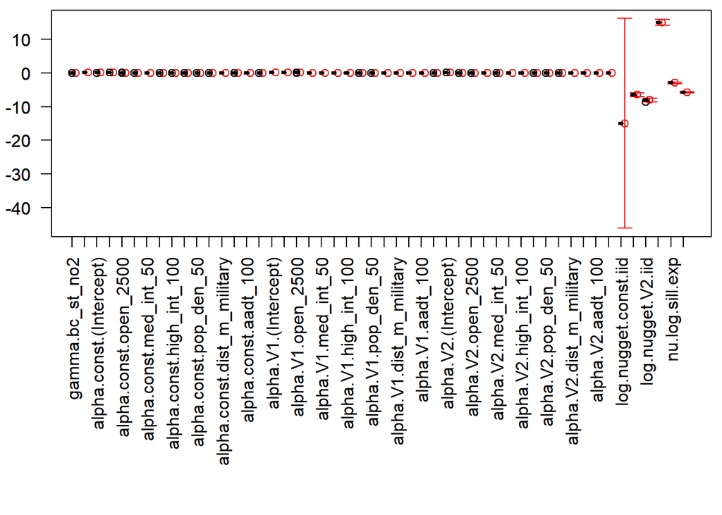

```r
par(mfrow=c(1,1), mar=c(13.5,2.5,.5,.5), las=2)
with(coef(est.denver.model.B, pars="all"),
     plotCI((1:length(par))+.3, par, uiw=1.96*sd,
             col=2, xlab="", xaxt="n", ylab=""))
boxplot(est.denver.B.cv, "all", boxwex=.4, col="grey", add=TRUE)
```

```r
#' Save the results as an .rdata object
save(denver.data.B, denver.model.B, est.denver.model.B, est.denver.B.cv,
     file = here::here("Results", "Denver_ST_Model_B.rdata"))
```

### 3.2.4 Prediction using the CV model

Making predictions using the CV model. Printing out the CV summary statistics as well

```r
pred.B.cv <- predictCV(denver.model.B, est.denver.B.cv, LTA = T)
pred.B.cv.log <- predictCV(denver.model.B, est.denver.B.cv,
                           LTA = T, transform="unbiased")

summary(pred.B.cv)
```

```
## Cross-validation predictions for STmodel with 10 CV-groups.
##   Predictions for 615 observations.
##   Temporal averages for 60 locations.
##
## RMSE:
##              EX.mu EX.mu.beta         EX
## obs     0.14500822 0.14500822 0.09170691
## average 0.08298805 0.08298805 0.06337664
##
## R2:
##             EX.mu EX.mu.beta        EX
## obs     0.5040168  0.5040168 0.8016255
## average 0.7007413  0.7007413 0.8254684
##
## Coverage of 95% prediction intervals:
##                EX
## obs     0.9089431
## average 0.9000000
```

```r
summary(pred.B.cv.log)
```

```
## Cross-validation predictions for STmodel with 10 CV-groups.
##   Predictions for 615 observations.
##   Temporal averages for 60 locations.
##
## RMSE:
##              EX.mu EX.mu.beta         EX    EX.pred
## obs     0.16599812 0.16599812 0.10522992 0.10529707
## average 0.09427925 0.09427925 0.07107317 0.07118135
##
## R2:
##             EX.mu EX.mu.beta        EX   EX.pred
## obs     0.5731650  0.5731650 0.8284731 0.8282542
## average 0.7623286  0.7623286 0.8649309 0.8645194
##
## Coverage of 95% prediction intervals:
##           EX.pred
## obs     0.9089431
## average 0.9000000
```

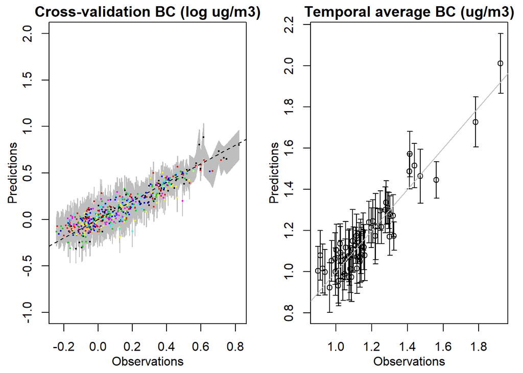

```r
par(mfrow=c(1,2), mar=c(3.3,3.3,1.5,1), mgp=c(2,1,0))
plot(pred.B.cv, "obs", ID="all", pch=c(19,NA), cex=.25, lty=c(NA,2),
     col=c("ID", "black", "grey"),
     ylim=c(-1,2),
     xlab="Observations", ylab="Predictions",
     main="Cross-validation BC (log ug/m3)")
with(pred.B.cv.log$pred.LTA, plotCI(obs, EX.pred, uiw=1.96*sqrt(VX.pred),
                                      xlab="Observations", ylab="Predictions",
                                      main="Temporal average BC (ug/m3)"))
abline(0, 1, col="grey")
```

```r
# jpeg(filename = here::here("Figs", "ST_CV_Obs_vs_Pred_BC_ModA.jpeg"),
#      width = 8, height = 4, units = "in", res = 500)
# par(mfrow=c(1,2), mar=c(3.3,3.3,1.5,1), mgp=c(2,1,0))
# plot(pred.B.cv, "obs", ID="all", pch=c(19,NA), cex=.25, lty=c(NA,2),
#      col=c("ID", "black", "grey"),
#      ylim=c(-1,2),
#      xlab="Observations", ylab="Predictions",
#      main="Cross-validation BC (log ug/m3)")
# with(pred.B.cv.log$pred.LTA, plotCI(obs, EX.pred, uiw=1.96*sqrt(VX.pred),
#                                       xlab="Observations", ylab="Predictions",
#                                       main="Temporal average BC (ug/m3)"))
# abline(0, 1, col="grey")
# dev.off()
```

### 3.2.5 Predictions for 2009-2019

What do the long-term predictions look like for this model? Predicting at the distributed (residential + community) sites

```r
x.B <- coef(est.denver.model.B, pars = "cov")$par
x.B
```

```
## [1] -15.000000  -6.451553  -8.068280  15.000000  -2.914219  -5.816116
```

```r
E.B <- predict(denver.model.B, est.denver.model.B, LTA = T,
               transform="unbiased", pred.var=FALSE)
print(E.B)
```

```
## Prediction for STmodel.
##
## Regression parameters:
##   0 Spatio-temporal covariate(s).
##   42 beta-fields regression parameters in x$pars.
##
## Regression parameters are assumed to be known and
##  prediction variances do NOT include
##  uncertainties in regression parameters.
##
## Prediction of beta-fields, (x$beta):
## List of 2
##  $ mu: num [1:61, 1:3] 0.0856 -0.0677 0.1386 -0.0394 0.0538 ...
##   ..- attr(*, "dimnames")=List of 2
##  $ EX: num [1:61, 1:3] 0.0856 -0.0677 0.1386 -0.0394 0.0538 ...
##   ..- attr(*, "dimnames")=List of 2
##
## Predictions for log-Gaussian field of type: unbiased
##
## Predictions for 526 times at 61 locations.
## List of 5
##  $ EX.mu     : num [1:526, 1:61] 1.45 1.41 1.54 1.43 1.43 ...
##   ..- attr(*, "dimnames")=List of 2
##  $ EX.mu.beta: num [1:526, 1:61] 1.48 1.43 1.57 1.45 1.45 ...
##   ..- attr(*, "dimnames")=List of 2
##  $ EX        : num [1:526, 1:61] 1.52 1.47 1.61 1.49 1.49 ...
##   ..- attr(*, "dimnames")=List of 2
##  $ EX.pred   : num [1:526, 1:61] 1.52 1.48 1.61 1.49 1.49 ...
##   ..- attr(*, "dimnames")=List of 2
##  $ log.EX    : num [1:526, 1:61] 0.389 0.36 0.448 0.369 0.371 ...
##   ..- attr(*, "dimnames")=List of 2
##
## Variances have been computed.
## List of 2
##  $ log.VX     : num [1:526, 1:61] 0.0548 0.0547 0.0546 0.0545 0.0545 ...
##   ..- attr(*, "dimnames")=List of 2
##  $ log.VX.pred: num [1:526, 1:61] 0.0577 0.0576 0.0576 0.0575 0.0574 ...
##   ..- attr(*, "dimnames")=List of 2
##
## Mean squared prediciton errors NOT been computed.
##
## 61 temporal averages have been compute.
## List of 1
##  $ LTA:'data.frame': 61 obs. of  4 variables:
```

```r
week_preds <- as.data.frame(E.B$EX) %>%
  mutate(week = as.Date(rownames(E.B$EX)),
         year = year(as.Date(rownames(E.B$EX))))

week_sites <- colnames(week_preds)[which(str_detect(colnames(week_preds), "d_"))]

box_preds <- week_preds %>%
  select(week, all_of(week_sites)) %>%
  #filter(week %in% week_weeks) %>%
  mutate(month = month(week),
         year = year(week)) %>%
  filter(year %in% c(2009:2019))

box_data <- box_preds %>%
  pivot_longer(-c(week, month, year), names_to = "location", values_to = "pred")
summary(box_data)
```

```
##       week                month             year        location
##  Min.   :2009-01-05   Min.   : 1.000   Min.   :2009   Length:31500
##  1st Qu.:2011-07-25   1st Qu.: 3.000   1st Qu.:2011   Class :character
##  Median :2014-01-27   Median : 6.000   Median :2014   Mode  :character
##  Mean   :2014-01-25   Mean   : 6.459   Mean   :2014
##  3rd Qu.:2016-08-01   3rd Qu.: 9.000   3rd Qu.:2016
##  Max.   :2019-02-04   Max.   :12.000   Max.   :2019
##
##       pred
##  Min.   :0.5538
##  1st Qu.:1.1951
##  Median :1.3933
##  Mean   :1.4703
##  3rd Qu.:1.7030
##  Max.   :4.0883
##  NA's   :480
```

```r
#' Box plot of weekly BC predicted at all distributed sites grouped by month
box_summary <- box_data %>%
  group_by(month) %>%
  summarize(median = median(pred, na.rm=T)) %>%
  arrange(desc(median))
box_summary
```

| month | median |
| --- | --- |
| 12 | 1.911655 |
| 1 | 1.779390 |
| 11 | 1.753714 |
| 2 | 1.672583 |
| 10 | 1.539402 |
| 3 | 1.431914 |
| 9 | 1.364455 |
| 8 | 1.290490 |
| 4 | 1.226021 |
| 5 | 1.182383 |

[output cut: 2 more lines]

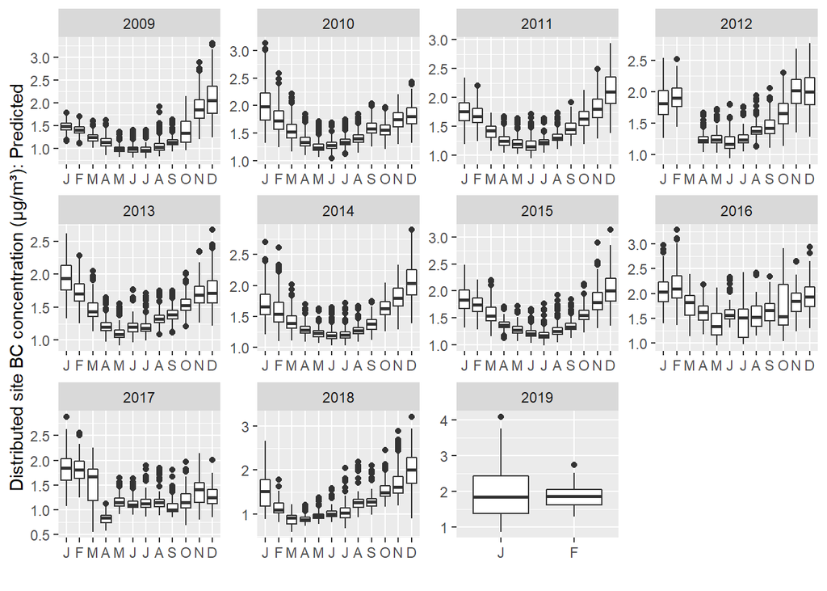

```r
pred_box_plot <- ggplot(box_data) +
  geom_boxplot(aes(x = as.factor(month), y = pred), #, color = as.factor(month)),
               show.legend = F) +
  #scale_color_viridis(name = "Month", discrete = T) +
  facet_wrap(. ~ year, scales = "free") +
  xlab("") + ylab("Distributed site BC concentration (\u03BCg/m\u00B3): Predicted") +
  # theme(axis.text.x = element_text(angle = 45, vjust = 1, hjust = 1)) +
  scale_x_discrete(labels = str_sub(month.name, 1, 1))
pred_box_plot
```

## 3.3 Model C: 3 temporal trend (basis) functions

### 3.3.1 Create the model object

For this version of the model, use `iid` for `cov.beta` (beta, beta1, beta2, beta3) and `exp` for `cov.nu` (error). Here we can specify different LUR formluae. The length of the LUR list should be number of basis functions + 1.

```r
denver.data.C <- denver.data2.3
names(denver.data.C$covars)
```

```
##  [1] "ID"                  "lon"                 "lat"
##  [4] "impervious_2500"     "open_2500"           "low_int_100"
##  [7] "med_int_50"          "high_int_50"         "high_int_100"
## [10] "ag_250"              "pop_den_50"          "dist_m_compost"
## [13] "dist_m_military"     "len_m_highways_2500" "aadt_100"
## [16] "aadt_2500"           "x"                   "y"
## [19] "type"
```

```r
LUR.C <- list(covar_fun, covar_fun, covar_fun, covar_fun)

cov.beta.C <-  list(covf = c("iid", "iid", "iid", "iid"), nugget = T)
cov.nu.C <- list(covf = "exp", nugget = T, random.effect = FALSE)
locations.C <- list(coords = c("x","y"), long.lat = c("lon","lat"), others= "type")

denver.model.C <- createSTmodel(denver.data.C, LUR = LUR.C,
                                ST = c("bc_st_no2", "bc_st_smk"),
                                cov.beta = cov.beta.C, cov.nu = cov.nu.C,
                                locations = locations.C)
```

```
## No trend $trend.fnc object detected, STdata probably from old version of the package.
## $trend.fnc has been added based on spline fit to elements in STmodel$trend.
```

```r
denver.model.C
```

```
## STmodel-object with:
##  No. locations: 61 (observed: 61)
##  No. time points: 526 (observed: 152)
##  No. obs: 767
##
## Trend with 3 basis function(s):
## [1] "V1" "V2" "V3"
## with dates:
##  2008-12-29 to 2019-02-04
##
## Models for the beta-fields are:
## $const
## ~~impervious_2500 + open_2500 + low_int_100 + med_int_50 + high_int_50 +
##     high_int_100 + ag_250 + pop_den_50 + dist_m_compost + dist_m_military +
##     len_m_highways_2500 + aadt_100 + aadt_2500
##
## $V1
## ~~impervious_2500 + open_2500 + low_int_100 + med_int_50 + high_int_50 +
##     high_int_100 + ag_250 + pop_den_50 + dist_m_compost + dist_m_military +
##     len_m_highways_2500 + aadt_100 + aadt_2500
##
## $V2
## ~~impervious_2500 + open_2500 + low_int_100 + med_int_50 + high_int_50 +
##     high_int_100 + ag_250 + pop_den_50 + dist_m_compost + dist_m_military +
##     len_m_highways_2500 + aadt_100 + aadt_2500
##
## $V3
## ~~impervious_2500 + open_2500 + low_int_100 + med_int_50 + high_int_50 +
##     high_int_100 + ag_250 + pop_den_50 + dist_m_compost + dist_m_military +
##     len_m_highways_2500 + aadt_100 + aadt_2500
##
## 2 spatio-temporal covariate(s):
## [1] "bc_st_no2" "bc_st_smk"
##
## Covariance model for the beta-field(s):
##  Covariance type(s): iid, iid, iid, iid
##  Nugget: Yes, Yes, Yes, Yes
## Covariance model for the nu-field(s):
##  Covariance type: exp
##  Nugget: ~1
##  Random effect: No
## All sites:
## central    dist
##       1      60
## Observed:
## central    dist
##       1      60
##
## For central:
##   Number of obs: 152
##   Dates: 2016-02-08 to 2019-02-04
## For dist:
##   Number of obs: 615
##   Dates: 2018-05-07 to 2018-11-12
```

### 3.3.2 Estimate model parameters

- nugget values can range from -1 to -6
- range values can range from 0 to 4
- try starting values where the sill and nugget are the same (e.g., both 0) and where they are very different (e.g., 0 and -5)
- make sure the starting values are pretty different

```r
names <- loglikeSTnames(denver.model.C, all=FALSE)
names
```

```
## [1] "log.nugget.const.iid"          "log.nugget.V1.iid"
## [3] "log.nugget.V2.iid"             "log.nugget.V3.iid"
## [5] "nu.log.range.exp"              "nu.log.sill.exp"
## [7] "nu.log.nugget.(Intercept).exp"
```

```r
# x.init.C <- cbind(c(0, 0, 0, 0, 0, 0, 0),
#                   c(-1, -1, -1, -1, 0, -1, -1),
#                   c(-1, -1, -1, -1, 0, -5, -1),
#                   c(-5, -5, -5, -5, 0, -1, -5),
#                   c(-5, -5, -5, -5, 0, -5, -5),
#                   c(-1, -1, -1, -1, 2, -1, -1),
#                   c(-1, -1, -1, -1, 2, -5, -1),
#                   c(-5, -5, -5, -5, 2, -1, -5),
#                   c(-5, -5, -5, -5, 2, -5, -5),
#                   c(-1, -1, -1, -1, 4, -1, -1),
#                   c(-1, -1, -1, -1, 4, -5, -1),
#                   c(-5, -5, -5, -5, 4, -1, -5),
#                   c(-5, -5, -5, -5, 4, -5, -5))

x.init.C <- cbind(c(0, 0, 0, 0, 0, 0, 0),
                  c(-10, -5, -5, -5, 4, -3, -5),
                  c(-10, -5, -5, -5, 4, -5, -5),
                  c(-10, -5, -5, -5, 6, -3, -5),
                  c(-10, -5, -5, -5, 6, -5, -5),
                  c(-10, -5, -5, -5, 8, -3, -5),
                  c(-10, -5, -5, -5, 8, -5, -5),
                  c(-10, -5, -5, -5, 10, -3, -5),
                  c(-10, -5, -5, -5, 10, -5, -5))

rownames(x.init.C) <- loglikeSTnames(denver.model.C, all=FALSE)
x.init.C
```

```
##                               [,1] [,2] [,3] [,4] [,5] [,6] [,7] [,8] [,9]
## log.nugget.const.iid             0  -10  -10  -10  -10  -10  -10  -10  -10
## log.nugget.V1.iid                0   -5   -5   -5   -5   -5   -5   -5   -5
## log.nugget.V2.iid                0   -5   -5   -5   -5   -5   -5   -5   -5
## log.nugget.V3.iid                0   -5   -5   -5   -5   -5   -5   -5   -5
## nu.log.range.exp                 0    4    4    6    6    8    8   10   10
## nu.log.sill.exp                  0   -3   -5   -3   -5   -3   -5   -3   -5
## nu.log.nugget.(Intercept).exp    0   -5   -5   -5   -5   -5   -5   -5   -5
```

```r
#' Difference from tutorial: use Josh Keller's version of the function
source(here::here("Code", "functions_model.R"))
est.denver.model.C <- estimate.STmodel(denver.model.C, x.init.C)
```

```
## Optimisation using starting value 1/9
```

```
## N = 7, M = 5 machine precision = 2.22045e-16
## At X0, 0 variables are exactly at the bounds
## At iterate     0  f=       419.81  |proj g|=           15
## At iterate    10  f =      -1361.2  |proj g|=        1.8667
## At iterate    20  f =        -1368  |proj g|=       0.35352
## At iterate    30  f =      -1368.3  |proj g|=       0.43824
## At iterate    40  f =      -1368.4  |proj g|=       0.34336
## At iterate    50  f =      -1368.4  |proj g|=        0.1527
## At iterate    60  f =      -1368.4  |proj g|=       0.19034
##
## iterations 69
## function evaluations 83
## segments explored during Cauchy searches 73
## BFGS updates skipped 0
## active bounds at final generalized Cauchy point 3
## norm of the final projected gradient 0.0130946
## final function value -1368.39
##
## F = -1368.39
```

```
## Optimisation using starting value 2/9
```

```
## N = 7, M = 5 machine precision = 2.22045e-16
## At X0, 0 variables are exactly at the bounds
## At iterate     0  f=      -966.95  |proj g|=           12
## At iterate    10  f =      -1365.2  |proj g|=        5.9437
## At iterate    20  f =      -1368.2  |proj g|=       0.80239
## At iterate    30  f =      -1368.3  |proj g|=        1.7697
##
## iterations 39
## function evaluations 55
## segments explored during Cauchy searches 42
## BFGS updates skipped 0
## active bounds at final generalized Cauchy point 2
## norm of the final projected gradient 0.0343422
## final function value -1368.39
##
## F = -1368.39
```

```
## Optimisation using starting value 3/9
```

```
## N = 7, M = 5 machine precision = 2.22045e-16
## At X0, 0 variables are exactly at the bounds
## At iterate     0  f=      -1270.6  |proj g|=           10
## At iterate    10  f =      -1364.9  |proj g|=        3.8153
## At iterate    20  f =      -1368.3  |proj g|=        0.5668
## At iterate    30  f =      -1368.3  |proj g|=       0.20102
## At iterate    40  f =      -1368.4  |proj g|=      0.021388
##
## iterations 43
## function evaluations 68
## segments explored during Cauchy searches 47
## BFGS updates skipped 0
## active bounds at final generalized Cauchy point 2
## norm of the final projected gradient 0.0175491
## final function value -1368.39
##
## F = -1368.39
## l(0) > u(0).  No feasible solutionfinal  value -1368.389079
```

```
## Optimisation using starting value 4/9
```

```
## N = 7, M = 5 machine precision = 2.22045e-16
## At X0, 0 variables are exactly at the bounds
## At iterate     0  f=      -969.01  |proj g|=           12
## At iterate    10  f =      -1521.3  |proj g|=        10.246
## At iterate    20  f =      -1547.2  |proj g|=        3.6343
## At iterate    30  f =      -1549.1  |proj g|=       0.33189
## At iterate    40  f =      -1549.1  |proj g|=       0.86939
##
## iterations 48
## function evaluations 72
## segments explored during Cauchy searches 51
## BFGS updates skipped 0
## active bounds at final generalized Cauchy point 3
## norm of the final projected gradient 0.0128674
## final function value -1549.08
##
## F = -1549.08
## l(0) > u(0).  No feasible solutionfinal  value -1549.084709
```

```
## Optimisation using starting value 5/9
```

```
## N = 7, M = 5 machine precision = 2.22045e-16
## At X0, 0 variables are exactly at the bounds
## At iterate     0  f=      -1271.8  |proj g|=           10
## At iterate    10  f =      -1459.6  |proj g|=        7.5659
## At iterate    20  f =      -1511.7  |proj g|=        20.723
## At iterate    30  f =      -1520.8  |proj g|=        16.206
## At iterate    40  f =        -1523  |proj g|=       0.21929
## At iterate    50  f =      -1548.1  |proj g|=        1.5162
## At iterate    60  f =      -1549.1  |proj g|=        0.3553
##
## iterations 65
## function evaluations 94
## segments explored during Cauchy searches 69
## BFGS updates skipped 0
## active bounds at final generalized Cauchy point 2
## norm of the final projected gradient 0.00826069
## final function value -1549.08
##
## F = -1549.08
```

```
## Optimisation using starting value 6/9
```

```
## N = 7, M = 5 machine precision = 2.22045e-16
## At X0, 0 variables are exactly at the bounds
## At iterate     0  f=      -1008.9  |proj g|=           12
## At iterate    10  f =      -1545.8  |proj g|=        2.2675
## At iterate    20  f =        -1549  |proj g|=       0.43769
## At iterate    30  f =      -1549.1  |proj g|=       0.39805
##
## iterations 38
## function evaluations 45
## segments explored during Cauchy searches 42
## BFGS updates skipped 0
## active bounds at final generalized Cauchy point 3
## norm of the final projected gradient 0.00296915
## final function value -1549.08
##
## F = -1549.08
```

```
## Optimisation using starting value 7/9
```

```
## N = 7, M = 5 machine precision = 2.22045e-16
## At X0, 0 variables are exactly at the bounds
## At iterate     0  f=        -1288  |proj g|=           10
## At iterate    10  f =      -1538.3  |proj g|=        11.171
## At iterate    20  f =      -1548.5  |proj g|=        3.5242
## At iterate    30  f =      -1549.1  |proj g|=      0.072426
##
## iterations 34
## function evaluations 44
## segments explored during Cauchy searches 39
## BFGS updates skipped 0
## active bounds at final generalized Cauchy point 2
## norm of the final projected gradient 0.0153448
## final function value -1549.08
##
## F = -1549.08
```

```
## Optimisation using starting value 8/9
```

```
## N = 7, M = 5 machine precision = 2.22045e-16
## At X0, 0 variables are exactly at the bounds
## At iterate     0  f=      -1181.5  |proj g|=           12
## At iterate    10  f =      -1546.5  |proj g|=        1.7892
## At iterate    20  f =        -1549  |proj g|=        1.2835
## At iterate    30  f =        -1549  |proj g|=       0.49398
## At iterate    40  f =      -1549.1  |proj g|=     0.0048189
##
## iterations 40
## function evaluations 50
## segments explored during Cauchy searches 45
## BFGS updates skipped 0
## active bounds at final generalized Cauchy point 3
## norm of the final projected gradient 0.00481887
## final function value -1549.08
##
## F = -1549.08
```

```
## Optimisation using starting value 9/9
```

```
## N = 7, M = 5 machine precision = 2.22045e-16
## At X0, 0 variables are exactly at the bounds
## At iterate     0  f=      -1343.6  |proj g|=           10
## At iterate    10  f =      -1546.3  |proj g|=        3.1212
## At iterate    20  f =        -1549  |proj g|=       0.80646
## At iterate    30  f =        -1549  |proj g|=       0.19232
## At iterate    40  f =      -1549.1  |proj g|=     0.0029887
##
## iterations 41
## function evaluations 61
## segments explored during Cauchy searches 45
## BFGS updates skipped 0
## active bounds at final generalized Cauchy point 3
## norm of the final projected gradient 0.00298883
## final function value -1549.08
##
## F = -1549.08
## l(0) > u(0).  No feasible solutionfinal  value -1549.084704
```

```r
print(est.denver.model.C)
```

```
## Optimisation for STmodel with 9 starting points.
##   Results: 6 converged, 3 not converged, 0 failed.
##   Best result for starting point 4, optimisation has converged
##
## No fixed parameters.
##
## Estimated parameters for all starting point(s):
##                                           [,1]           [,2]           [,3]
## gamma.bc_st_no2                   0.0180973859   0.0180980847   0.0180974303
## gamma.bc_st_smk                   0.0677335959   0.0677324383   0.0677310263
## alpha.const.(Intercept)          -0.2863799986  -0.2863973493  -0.2863819965
## alpha.const.impervious_2500       0.0588986748   0.0589111759   0.0589011488
## alpha.const.open_2500             0.0169875026   0.0169955494   0.0169834949
## alpha.const.low_int_100           0.0131708694   0.0131816831   0.0131719098
## alpha.const.med_int_50            0.0474194373   0.0474114783   0.0474123441
## alpha.const.high_int_50           0.0267016479   0.0267062051   0.0267045832
## alpha.const.high_int_100          0.0048203625   0.0048139540   0.0048136509
## alpha.const.ag_250                0.0129881506   0.0129898059   0.0129884803
## alpha.const.pop_den_50           -0.0116108841  -0.0116116977  -0.0116112504
## alpha.const.dist_m_compost        0.0057379728   0.0057393315   0.0057407778
## alpha.const.dist_m_military       0.0007416278   0.0007411351   0.0007468880
## alpha.const.len_m_highways_2500   0.0213369736   0.0213309621   0.0213303954
## alpha.const.aadt_100              0.0431060744   0.0431137999   0.0431111350
## alpha.const.aadt_2500            -0.0146394964  -0.0146404236  -0.0146347723
## alpha.V1.(Intercept)              0.0663052469   0.0662985723   0.0663021936
## alpha.V1.impervious_2500          0.0469204028   0.0469198472   0.0469147369
## alpha.V1.open_2500                0.0348284906   0.0348241406   0.0348208799
## alpha.V1.low_int_100              0.0057940446   0.0057965951   0.0057929676
## alpha.V1.med_int_50               0.0294920237   0.0294875852   0.0294873056
## alpha.V1.high_int_50              0.0016873206   0.0016947367   0.0016906890
## alpha.V1.high_int_100             0.0344525165   0.0344394488   0.0344468064
## alpha.V1.ag_250                   0.0074132728   0.0074032413   0.0074082752
## alpha.V1.pop_den_50              -0.0018271608  -0.0018301635  -0.0018276773
## alpha.V1.dist_m_compost           0.0184002369   0.0183922547   0.0183972119
## alpha.V1.dist_m_military         -0.0017542682  -0.0017604841  -0.0017547770
## alpha.V1.len_m_highways_2500      0.0077300070   0.0077256130   0.0077274120
## alpha.V1.aadt_100                -0.0047718835  -0.0047711744  -0.0047734903
## alpha.V1.aadt_2500               -0.0137363506  -0.0137384451  -0.0137343988
## alpha.V2.(Intercept)             -0.6192562935  -0.6192592271  -0.6192583716
## alpha.V2.impervious_2500         -0.0282531188  -0.0282263376  -0.0282357237
```

[output cut: 154 more lines]

```
## alpha.V3.dist_m_military         -0.0073713264  -0.0073703174  -0.0073703533
## alpha.V3.len_m_highways_2500     -0.0071586129  -0.0071581232  -0.0071582548
## alpha.V3.aadt_100                 0.0095583962   0.0095581846   0.0095582187
## alpha.V3.aadt_2500                0.0036531585   0.0036540281   0.0036540256
## log.nugget.const.iid            -14.1076760585 -15.0000000000 -15.0000000000
## log.nugget.V1.iid                -6.5221111743  -6.5226952501  -6.5225862405
## log.nugget.V2.iid               -15.0000000000 -15.0000000000 -15.0000000000
## log.nugget.V3.iid                -8.0509990094  -8.0510025214  -8.0508380012
## nu.log.range.exp                 15.0000000000  15.0000000000  15.0000000000
## nu.log.sill.exp                  -3.7174661058  -3.7174316984  -3.7174082131
## nu.log.nugget.(Intercept).exp    -5.8195702319  -5.8196025787  -5.8196303175
##
## Function value(s):
## [1] 1368.391 1368.391 1368.389 1549.085 1549.078 1549.085 1549.079 1549.085
## [9] 1549.085
```

### 3.3.3 Cross-validation

Define the CV groups

```r
set.seed(123)

unique(colnames(bc_obs2))
```

```
##  [1] "d_1"     "d_2"     "d_3"     "d_4"     "d_5"     "d_6"     "d_7"
##  [8] "d_8"     "d_9"     "d_10"    "d_11"    "d_12"    "d_13"    "d_14"
## [15] "d_15"    "d_16"    "d_17"    "d_18"    "d_19"    "d_20"    "d_21"
## [22] "d_22"    "d_23"    "d_24"    "d_25"    "d_26"    "d_27"    "d_28"
## [29] "d_29"    "d_30"    "d_31"    "d_32"    "d_33"    "d_34"    "d_35"
## [36] "d_36"    "d_37"    "d_38"    "d_39"    "d_40"    "d_41"    "d_42"
## [43] "d_43"    "d_44"    "d_45"    "d_46"    "d_47"    "d_48"    "d_49"
## [50] "d_50"    "d_51"    "d_52"    "d_53"    "d_54"    "d_55"    "d_56"
## [57] "d_57"    "d_58"    "d_59"    "d_60"    "central"
```

```r
Ind.cv.C <- createCV(denver.model.C, groups = 10, #min.dist = .1,
                     subset = paste0("d_", c(1:60)))

ID.cv.C <- sapply(split(denver.model.C$obs$ID, Ind.cv.C), unique)
print(sapply(ID.cv.C, length))
```

```
##  0  1  2  3  4  5  6  7  8  9 10
##  1  6  6  6  6  6  6  6  6  6  6
```

```r
table(Ind.cv.C)
```

```
## Ind.cv.C
##   0   1   2   3   4   5   6   7   8   9  10
## 152  71  53  58  67  66  52  66  61  61  60
```

```r
I.col.C <- apply(sapply(ID.cv.C, function(x) denver.model.C$locations$ID%in% x), 1,
                       function(x) if(sum(x)==1) which(x) else 0)
names(I.col.C) <- denver.model.C$locations$ID
print(I.col.C)
```

```
##     d_1     d_2     d_3     d_4     d_5     d_6     d_7     d_8     d_9    d_10
##       6       9      11       4      11       2       8      11       9       7
##    d_11    d_12    d_13    d_14    d_15    d_16    d_17    d_18    d_19    d_20
##       2       9      10       2      10      11       6      11       6      10
##    d_21    d_22    d_23    d_24    d_25    d_26    d_27    d_28    d_29    d_30
##       3       3       8       8       3       5      10       5       4       5
##    d_31    d_32    d_33    d_34    d_35    d_36    d_37    d_38    d_39    d_40
##       4       7       2       7       8       6       2       5       5       4
##    d_41    d_42    d_43    d_44    d_45    d_46    d_47    d_48    d_49    d_50
##       7       5       9       4       3       6       8      11       4       9
##    d_51    d_52    d_53    d_54    d_55    d_56    d_57    d_58    d_59    d_60
##       9       8      10       2       6       3       3       7       7      10
## central
##       1
```

```r
par(mfrow=c(1,1))
plot(denver.model.C$locations$long,
     denver.model.C$locations$lat,
     pch=23+floor(I.col.C/max(I.col.C)+.5), bg=I.col.C,
     xlab="Longitude", ylab="Latitude")
```

[output not shown]

```r
map("county", "colorado", col="#FFFF0055",fill=TRUE, add=TRUE)
```

ID starting conditions using previous model without CV:

```r
x.init.C.cv <- coef(est.denver.model.C, pars="cov")[,c("par","init")]
x.init.C.cv
```

|  | par | init |
| --- | --- | --- |
| log.nugget.const.iid | -15.000000 | -10 |
| log.nugget.V1.iid | -6.522353 | -5 |
| log.nugget.V2.iid | -15.000000 | -5 |
| log.nugget.V3.iid | -8.051117 | -5 |
| nu.log.range.exp | 15.000000 | 6 |
| nu.log.sill.exp | -3.717364 | -3 |
| nu.log.nugget.(Intercept).exp | -5.819579 | -5 |

Run the model with cross validation

```r
est.denver.C.cv <- estimateCV(denver.model.C, x.init.C.cv, Ind.cv.C)
```

```
## Estimation of CV-set 1/10
```

```
## Optimisation using starting value 1/2
```

```
## N = 7, M = 5 machine precision = 2.22045e-16
## At X0, 3 variables are exactly at the bounds
## At iterate     0  f=      -1395.3  |proj g|=       4.0551
##
## iterations 7
## function evaluations 18
## segments explored during Cauchy searches 7
## BFGS updates skipped 0
## active bounds at final generalized Cauchy point 3
## norm of the final projected gradient 0.0129657
## final function value -1395.46
##
## F = -1395.46
```

```
## Optimisation using starting value 2/2
```

```
## N = 7, M = 5 machine precision = 2.22045e-16
## At X0, 0 variables are exactly at the bounds
## At iterate     0  f=      -876.11  |proj g|=           12
## At iterate    10  f =      -1341.1  |proj g|=        19.358
## At iterate    20  f =        -1394  |proj g|=        2.7454
## At iterate    30  f =      -1395.4  |proj g|=       0.54253
##
## iterations 35
## function evaluations 53
## segments explored during Cauchy searches 38
## BFGS updates skipped 0
## active bounds at final generalized Cauchy point 2
## norm of the final projected gradient 0.0646076
## final function value -1395.46
##
## F = -1395.46
```

```
## Estimation of CV-set 2/10
```

```
## Optimisation using starting value 1/2
```

```
## N = 7, M = 5 machine precision = 2.22045e-16
## At X0, 3 variables are exactly at the bounds
## At iterate     0  f=      -1424.7  |proj g|=       6.2808
## At iterate    10  f =      -1424.9  |proj g|=      0.040755
## Bad direction in the line search;
##    refresh the lbfgs memory and restart the iteration.
##
## iterations 11
## function evaluations 46
## segments explored during Cauchy searches 12
## BFGS updates skipped 0
## active bounds at final generalized Cauchy point 3
## norm of the final projected gradient 0.0407555
## final function value -1424.89
##
## F = -1424.89
## l(0) > u(0).  No feasible solutionfinal  value -1424.886348
```

```
## Optimisation using starting value 2/2
```

```
## N = 7, M = 5 machine precision = 2.22045e-16
## At X0, 0 variables are exactly at the bounds
## At iterate     0  f=      -900.87  |proj g|=           12
## At iterate    10  f =      -1389.1  |proj g|=        11.851
## At iterate    20  f =      -1423.2  |proj g|=        14.084
## At iterate    30  f =      -1424.9  |proj g|=       0.19192
##
## iterations 35
## function evaluations 50
## segments explored during Cauchy searches 38
## BFGS updates skipped 0
## active bounds at final generalized Cauchy point 2
## norm of the final projected gradient 0.0227577
## final function value -1424.88
##
## F = -1424.88
```

```
## Estimation of CV-set 3/10
```

```
## Optimisation using starting value 1/2
```

```
## N = 7, M = 5 machine precision = 2.22045e-16
## At X0, 3 variables are exactly at the bounds
## At iterate     0  f=      -1410.2  |proj g|=       9.0414
##
## iterations 9
## function evaluations 19
## segments explored during Cauchy searches 9
## BFGS updates skipped 0
## active bounds at final generalized Cauchy point 3
## norm of the final projected gradient 0.0113643
## final function value -1410.42
##
## F = -1410.42
```

```
## Optimisation using starting value 2/2
```

```
## N = 7, M = 5 machine precision = 2.22045e-16
## At X0, 0 variables are exactly at the bounds
## At iterate     0  f=      -894.47  |proj g|=           12
## At iterate    10  f =      -1362.3  |proj g|=        11.177
## At iterate    20  f =      -1408.9  |proj g|=        3.6384
## At iterate    30  f =      -1410.4  |proj g|=        1.1044
## At iterate    40  f =      -1410.4  |proj g|=       0.48167
##
## iterations 47
## function evaluations 68
## segments explored during Cauchy searches 50
## BFGS updates skipped 0
## active bounds at final generalized Cauchy point 3
## norm of the final projected gradient 0.0326491
## final function value -1410.42
##
## F = -1410.42
## l(0) > u(0).  No feasible solutionfinal  value -1410.417560
```

```
## Estimation of CV-set 4/10
```

```
## Optimisation using starting value 1/2
```

```
## N = 7, M = 5 machine precision = 2.22045e-16
## At X0, 3 variables are exactly at the bounds
## At iterate     0  f=      -1411.4  |proj g|=       8.0761
##
## iterations 9
## function evaluations 20
## segments explored during Cauchy searches 9
## BFGS updates skipped 0
## active bounds at final generalized Cauchy point 3
## norm of the final projected gradient 0.0339287
## final function value -1411.71
##
## F = -1411.71
```

```
## Optimisation using starting value 2/2
```

```
## N = 7, M = 5 machine precision = 2.22045e-16
## At X0, 0 variables are exactly at the bounds
## At iterate     0  f=      -883.85  |proj g|=           12
## At iterate    10  f =      -1329.7  |proj g|=        10.729
## At iterate    20  f =        -1409  |proj g|=          5.19
## At iterate    30  f =      -1411.6  |proj g|=      0.079846
## At iterate    40  f =      -1411.7  |proj g|=       0.59676
##
## iterations 49
## function evaluations 60
## segments explored during Cauchy searches 52
## BFGS updates skipped 0
## active bounds at final generalized Cauchy point 3
## norm of the final projected gradient 0.00096698
## final function value -1411.71
##
## F = -1411.71
```

```
## Estimation of CV-set 5/10
```

```
## Optimisation using starting value 1/2
```

```
## N = 7, M = 5 machine precision = 2.22045e-16
## At X0, 3 variables are exactly at the bounds
## At iterate     0  f=      -1415.5  |proj g|=       6.5487
## Bad direction in the line search;
##    refresh the lbfgs memory and restart the iteration.
##
## iterations 8
## function evaluations 49
## segments explored during Cauchy searches 9
## BFGS updates skipped 0
## active bounds at final generalized Cauchy point 3
## norm of the final projected gradient 0.00787714
## final function value -1415.97
##
## F = -1415.97
## l(0) > u(0).  No feasible solutionfinal  value -1415.974408
```

```
## Optimisation using starting value 2/2
```

```
## N = 7, M = 5 machine precision = 2.22045e-16
## At X0, 0 variables are exactly at the bounds
## At iterate     0  f=      -885.91  |proj g|=           12
## At iterate    10  f =      -1324.3  |proj g|=        9.5808
## At iterate    20  f =      -1413.4  |proj g|=        2.7734
## At iterate    30  f =      -1415.9  |proj g|=        1.0744
## At iterate    40  f =      -1415.9  |proj g|=       0.53265
## At iterate    50  f =        -1416  |proj g|=     0.0074538
##
## iterations 51
## function evaluations 64
## segments explored during Cauchy searches 54
## BFGS updates skipped 0
## active bounds at final generalized Cauchy point 3
## norm of the final projected gradient 0.000798874
## final function value -1415.97
##
## F = -1415.97
```

```
## Estimation of CV-set 6/10
```

```
## Optimisation using starting value 1/2
```